# Manual de Projetos

Pular para o conteúdo

[**IDE**] Manual de Projetos

IDE 2026 · Empresa Júnior de Programação da UFRGS

[**IDE**]

# Manual de Projetos

Padronização do ciclo de vida de Desenvolvimento de Software

Soluções em programação · UFRGS

# Motivação

O estabelecimento de um Ciclo de Vida de Desenvolvimento de Software (abreviadamente, SDLC) não deve ser encarado apenas como uma formalidade administrativa, mas como peça fundamental de uma organização que busca escalabilidade e qualidade técnica superior.

Para a IDE, que lida com um quadro de colaboradores majoritariamente composto por estudantes em semestres iniciais, o SDLC atua como um mecanismo de transferência de conhecimento e proteção contra a perda de capital intelectual decorrente da alta rotatividade.

A ausência de processos padronizados em tais contextos costuma resultar no fenômeno conhecido como “desenvolvimento ad-hoc”, onde cada projeto segue uma lógica particular, impossibilitando a manutenção a longo prazo e gerando gargalos operacionais que impedem o giro de múltiplos projetos simultâneos.

A padronização dos momentos vitais da vida de um projeto (pré-contratual, durante contrato e pós-contratual) resulta frutos incalculáveis para tanto os colaboradores/voluntários (no que concerne ao aprendizado durante o ciclo de vida do projeto e à ausência de gargalos operacionais que desgastam a relação intra equipe) e à IDE quanto para os contratantes (que recebem um projeto realizado de maneira mais ágil, segura e perfeccionista).

Esses pontos, querer melhorar a experiência do membro da IDE na empresa, querer solidificar processos internos e querer proporcionar ao cliente um produto sólido e de valor, somados a um histórico de experiências com projetos passados, nos motivam a não medir esforços na confecção do informalmente intitulado “Manual de Projetos” e justificam tais investimentos nesse sentido.

# Índice

1. **Modus Operandi da lógica pré-contratual:** Engenharia de Requisitos e Fundamentação Estratégica do Projeto, como proceder em cada etapa
   1. Introdução: Visão geral
   2. Reuniões com o cliente, como proceder?
   3. Levantamento de Requisitos
   4. Análise de Projeto
      1. Análise de tecnologias
      2. Esboço de projeto: “Diagrama de caixinhas”
   5. Orçamento e Montagem de Apresentação
2. **Lógica durante contrato:** Normas e padrões organizacionais na confecção de projetos
   1. Introdução: Visão geral
   2. GitHub: Guia sobre uso em projetos
      1. Criação e configuração inicial do repositório
      2. Issues: transformando o projeto em tarefas
      3. Branches e modelo de ramificação
      4. Commits
      5. Pull Requests
      6. Revisão de código
      7. Merge e encerramento da tarefa
      8. Divisão de responsabilidades
   3. Design de sistemas: Práticas essenciais e regras gerais no design de sistemas e sites
      1. Design não é apenas estética
      2. Caso prático IDE: o aplicativo dos motoboys
      3. Antes de desenhar: entender o problema
      4. Pesquisa fundamentada
      5. Esboço do design
      6. Consistência
      7. Design System e biblioteca de componentes
      8. Hierarquia visual e prioridade
      9. Estados e feedback ao usuário
      10. Responsividade e diferentes dispositivos
      11. Acessibilidade (A11y): padrão mínimo, não diferencial
      12. Heurísticas de Nielsen: instrumento de revisão
      13. Aprovação interna antes da apresentação ao cliente
      14. Aprovação do cliente
      15. Implementação e ciclo de revisão
      16. Regra geral
   4. Diagramação Técnica e Arquitetural: Orquestrando o desenvolvimento do projeto
      1. Matriz de Requisitos Funcionais
      2. User Stories
      3. User Flow
      4. Diagrama de Classes
      5. Diagrama de Sequência
      6. Modelo Físico de Dados e Máquinas de Estado
      7. Visão Arquitetural: o Modelo C4
      8. Documentação como Código (*Docs-as-Code*)
      9. Anti-padrões de diagramação
   5. Padrões e convenções de desenvolvimento
      1. Nomenclatura e formatação
      2. Documentação e comentários
      3. Convenções por stack
      4. Modularidade e princípios SOLID
      5. Code Smells
      6. Tratamento de erros e segredos
      7. Testes automatizados
      8. Git: commits e branches
      9. Code Review
3. **Da finalização do projeto**
   1. Terminamos o projeto, o que fazer agora?
4. **Referências**
5. **Agradecimentos**

# 1. Modus Operandi da lógica pré-contratual: Engenharia de Requisitos e Fundamentação Estratégica do Projeto, como proceder em cada etapa

## 1.1 Introdução: Visão geral

O objetivo dessa seção é delimitar padrões e compartilhar conhecimentos os quais, sobretudo, removam o gargalo de comunicação entre o que o cliente pede e o que o desenvolvedor entende e que gerem maior valor ao produto apresentado ao cliente.

De um modo geral, o diagrama abaixo ilustra como procede esse período pré-contratual:

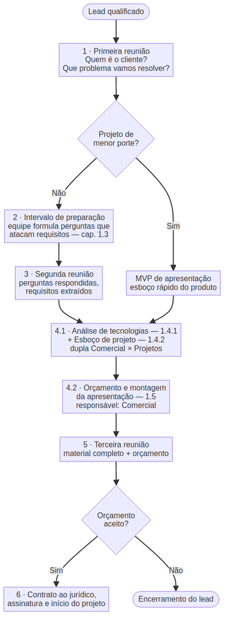

1. **Primeira reunião:** A depender do contexto, a dupla comercial x projetos já estabelecida ou somente o membro do comercial entrará em contato, pela primeira vez, com o cliente. **O objetivo é entender quem é o cliente e o que ele precisa (qual seu negócio e suas dores), extraindo o máximo de informações possíveis**. A pergunta principal desta etapa é **“Que problema vamos solucionar e para quem?”.**

   **Entregáveis Esperados:** resumo do negócio, resumo do problema, stakeholders envolvidos e lista de dúvidas abertas. Possivelmente **disponibilizar recursos para o cliente pesquisar** **mais**: “**ex: consegue nos mandar uma lista de sites que você gosta, para nos baseamos?**”

| Em que focar | O que não (necessariamente) é o foco |
| --- | --- |
| Quem é o cliente? O que o cliente faz? Qual problema motiva esse projeto? Quem sofre com este problema? Apresentação da IDE | Telas Tecnologias a serem utilizadas. Campos específicos. Detalhes miúdos. |

2. **Intervalo de Preparação:** após o contato inicial, um intervalo de poucos dias para o cliente pensar melhor sobre o problema e a equipe **preparar dúvidas que visem atacar os requisitos**. Pode ser interessante, a depender da dificuldade técnica das dúvidas e do porte do projeto, comentar, ao final da primeira reunião, que possíveis dúvidas mais incisivas serão elaboradas acerca do projeto e posteriormente enviadas, com o objetivo de, na segunda reunião, elas serem respondidas. Dessa maneira, o cliente consegue elaborar as respostas para as dúvidas tidas.

   **Entregáveis Esperados:** seleção de questões que visam **atacar requisitos**, principalmente **básicos** e **performantes, de acordo com o *capítulo 1.3 desse manual : Levantamento de Requisitos***

   **Observação**: Caso o projeto seja visivelmente de menor porte (por exemplo, um site básico), a segunda reunião pode ser omitida, pulando direto para a reunião de apresentação de orçamento. Para esses casos, é muito interessante (e, possivelmente, necessário, por ser geralmente de fácil realização) confeccionar um MVP (*Minimum Viable Product* ou Produto Mínimo Viável) do projeto. Por exemplo, se for um site institucional básico, pode-se, com facilidade, utilizar o stitch do google ou o lovable para esboçar um site a apresentar ao cliente. Dessa forma, temos maiores chances de fazer com que o cliente feche o contrato conosco.
3. **Segunda Reunião:** momento para questionar o cliente e extrair o máximo possível de informações orientadas, de acordo com as perguntas desenvolvidas no passo anterior.  
   **Entregáveis Esperados:** perguntas respondidas, anotações de fatos que o cliente adicionou.
4. 1. **Elaboração e interpretação de requisitos:** nesta etapa, os membros se unem para realizar a **análise de tecnologias** e o **esboço do projeto (de acordo com os capítulos 1.4.1 Análise de tecnologias e 1.4.2 Esboço de projeto, respectivamente)**, baseando-se nos requisitos levantados do projeto. Para a realização dessa etapa, uma ideia é os membros da dupla comercial x projetos se programarem para, logo após a segunda reunião, engatarem uma reunião entre si para discutirem as ideias e matarem essa tarefa rapidamente. Não necessariamente precisa ser imediatamente a segunda reunião, mas é interessante que essa etapa seja realizada em reunião/em conjunto.
   2. **Orçamento e montagem da apresentação:** Após realizada a etapa 4.1, o membro do setor comercial fica responsável por realizar o orçamento do projeto e pela montagem da apresentação a ser mostrada na reunião de apresentação de orçamento e projeto.
5. **Terceira reunião:** momento de apresentação de todo material confeccionado até o momento, colocando, no final, o orçamento previsto. Proceder nessa reunião de acordo com o capítulo seguinte, assim como nas demais reuniões anteriores (1.2 Reuniões com o cliente, como proceder?), sobretudo no que concerne à questão do preço do projeto — usar a fala de sermos uma empresa de cunho voluntário e sem fins lucrativos e que, portanto, visamos a proposta de um preço o mais justo possível.
6. **Orçamento aceito:** Caso o orçamento seja aceito, enviar o contrato para o nosso jurídico. **Tradução:** Os membros responsáveis pelo lead deverão contatar o diretor comercial para que este lide com essa etapa burocrática do contrato, que é basicamente enviar para o nosso jurídico para uma revisão contratual. Logo em seguida, o contrato deve ser enviado para assinatura e o projeto deve começar. Agilidade nessa etapa é peça fundamental para que o cliente não mude de ideia e abandone a ideia do projeto.

## 1.2 Reuniões com o cliente, como proceder?

O lead sempre precisa confiar em quem ele está conversando, e essa confiança surge quando ele percebe que você compreende do mercado e do negócio dele, e que está interessado em ajudar. Em vendas, esse processo é conhecido como *rapport*: criar um ambiente confortável para a conversa sem perder o profissionalismo.

Pequenos detalhes fazem muita diferença. Chame o cliente pelo nome, demonstre que pesquisou minimamente sobre a empresa e adapte sua comunicação ao perfil de quem está na reunião. Um diretor de uma indústria e o dono de uma pequena empresa provavelmente esperam abordagens diferentes.

Pessoas gostam de falar sobre seus próprios negócios. Quanto mais o cliente sentir que você está tentando entender sua realidade maior será sua disposição para colaborar durante a reunião.

Este manual existe para aumentar a taxa de conversão da IDE. Caso, em uma situação específica, algum membro experiente ache que seguir literalmente determinada orientação prejudicará a negociação, essa percepção deve ser comentada com a equipe e considerada.

### 1.2.1 Preparação

A **reunião começa antes da reunião**. Quanto mais preparado você chega, menos esforço precisará fazer para transmitir confiança durante a conversa.

Tenham em mente que ninguém procura uma empresa júnior esperando encontrar a organização de uma multinacional. Isso pode soar ruim, mas é uma oportunidade, porque pequenos cuidados de organização e profissionalismo já vão impressionar, e impressionar ajuda a vender.

Profissionalismo exige preparação:

- Pesquise a empresa e seu ramo de atuação.
- Saiba quem participará e qual seu cargo (preferencialmente, deve estar presente aquele responsável por tomar a decisão final do projeto, principalmente na reunião de apresentação de orçamento)
- Revise o histórico da prospecção.
- Prepare previamente as perguntas que deseja fazer.
- Defina quem conduzirá a reunião e quem ficará responsável pelas anotações.
- Teste câmera, microfone e compartilhamento de tela.
- Crie a reunião pelo Google Meet através do Google Agenda e convide todos os participantes.
- Entre na reunião alguns minutos antes do cliente.

Preparar perguntas não significa montar um interrogatório. Use as primeiras perguntas como âncora para uma conversa natural, na qual cada resposta gera a pergunta seguinte.

Quando a reunião surgiu de uma prospecção, retome o que já foi dito: “Quando conversamos por telefone, você comentou que hoje a equipe faz esse controle manualmente. Queria entender melhor como esse processo funciona.”

**Pontualidade e disponibilidade**

**Chegue antes do cliente**. Entrar correndo e descobrir na hora que o microfone não funciona destrói em dois minutos a imagem que tentaremos construir durante o resto da reunião.

Se você “tem disponibilidade”, mas sabe que participará com a câmera desligada, áudio ou internet ruim, você se confundiu, **você não tem disponibilidade.** Ver e conversar bem são imprescindíveis para gerar confiança. Em último caso, participe mesmo assim, mas isso nunca deve ser tratado como padrão.

Se um atraso for inevitável, avise antes do horário, dê uma previsão realista e peça desculpas de forma breve. Se outra pessoa da dupla conseguir entrar no horário, ela deve receber o cliente e iniciar a conversa. A equipe precisa combinar o que vai falar sobre o atraso, pode omitir informações em prol de soar mais profissional. Justifiquem da forma que soar bom, desde que **não** escape algo **contraditório** depois.

### 1.2.2 Quem deve participar

No cenário ideal, apenas a **dupla Comercial × Projetos** responsável pela oportunidade participa. Às vezes, o cliente pode ter chego à IDE por um membro que ele conhece em **outro setor**, e nesse caso é **recomendado** que esse membro participe também, para passar a imagem de **confiança**.

Enquanto os membros ainda estão se acostumando com as operações da IDE, é **aceitável** contar com gerente comercial, diretor, vice-presidente ou presidente. Do jeito que as coisas às vezes acontecem, pode acabar entrando qualquer membro de diretoria que esteja disponível. Isso resolve uma necessidade imediata, mas **não** deve virar processo **permanente**. **Muita gente** da IDE e uma pessoa do cliente criam uma reunião desequilibrada, **dificultam o entrosamento** e podem intimidar quem está do outro lado.

É perfeitamente normal um falar mais do que o outro. Caso seja necessário corrigir um colega, faça isso sem descredibilizar a equipe: “Só complementando esse ponto…” ou “Acho importante acrescentar uma condição aqui…”. Depois da reunião, qualquer divergência interna é discutida em particular.

### 1.2.3 Comunicação

Antes de discutir o projeto, o cliente precisa sentir que está conversando com pessoas **organizadas**, **interessadas** e **competentes**. Obviamente, há muito *feeling* envolvido, contudo pequenos detalhes como lembrar o nome do cliente, demonstrar que pesquisou sobre sua empresa e manter uma conversa natural, fazem muita diferença.

Uma abertura simples costuma ser suficiente:

“Oi, Fulano, obrigado pelo tempo. Eu sou o Bruno, do comercial, e esse é o Pedro, de projetos. A ideia hoje é entender melhor como vocês trabalham, quais dificuldades motivaram esse contato e o que uma solução precisaria entregar.”

Depois da resposta, começam com as perguntas mais gerais sobre o que o cliente tem em mente.

Durante a conversa:

- chame o cliente pelo nome de forma natural, especialmente ao abrir, retomar um ponto importante ou pedir uma decisão; repetir o nome a cada frase soa ensaiado;
- demonstre que pesquisou a empresa, citando apenas informações pertinentes;
- apresente a IDE de forma breve e conectada ao contexto; a história completa da empresa só interessa se ajudar a venda;
- adapte o nível de formalidade, velocidade e vocabulário ao perfil de quem está falando;
- deixe o cliente terminar e aguarde um ou dois segundos antes de responder;
- utilize confirmações curtas como “Entendi”, “Faz sentido”, “Claro” e “Interessante”;
- não tenha medo de pequenos silêncios: frequentemente, o cliente usa esse espaço para complementar a resposta com a informação mais valiosa.

**Transmita segurança evitando dizer:**

“Não sei.”

“Nunca fizemos isso.”

**Prefira**:

“Posso confirmar esse detalhe para você.”

“Se não me engano, já tivemos projetos semelhantes anteriormente.”

“É plenamente possível, apenas preciso confirmar alguns detalhes técnicos com a equipe.”

Tudo bem “mentir” em certo grau. Dependendo do projeto, considerando o contexto que você tem da IDE, demonstre que a empresa consegue mesmo que seja uma stack que não tenhamos trabalhado. O objetivo **não é prometer** aquilo que a IDE não poderá entregar, mas também **não transmitir insegurança** desnecessariamente.

**Perguntas Abertas:**

Sempre que possível, utilize perguntas abertas. Isto é, evite perguntas cuja resposta seja apenas “sim” ou “não”. Essas perguntas fazem o próprio cliente revelar suas dores.

### 1.2.4 Leia o perfil do cliente

Não existe uma fala que funcione com todo mundo. Avalie continuamente:

- quanto a pessoa conhece de tecnologia;
- se ela prefere objetividade ou gosta de desenvolver histórias e contexto;
- se demonstra mais preocupação com preço, prazo, risco, qualidade ou facilidade de uso;
- se procura uma solução imediatamente ou está apenas pesquisando possibilidades;
- se tem autoridade real para aprovar o projeto.

Um cliente técnico provavelmente valoriza precisão, restrições e critérios claros. Um cliente leigo precisa enxergar o resultado no negócio, não ouvir uma aula sobre frameworks. O dono de uma empresa pequena pode decidir na própria reunião; um funcionário de uma organização maior talvez precise de material para defender a proposta internamente. A apresentação deve ajudá-lo nessa tarefa.

Clientes mais velhos ou com pouca familiaridade com software podem ter dificuldade para compreender por que algo que parece simples na tela exige meses de trabalho. Isso é uma hipótese útil, não uma regra sobre idade. Em vez de pensar “essa pessoa não entende tecnologia”, traduza complexidade em atividades e risco: levantamento, regras de negócio, permissões, integrações, testes, segurança, implantação e manutenção. O valor passa a fazer sentido quando o trabalho invisível fica visível.

Também não confunda simpatia com intenção de compra. Uma pessoa expansiva pode elogiar tudo e nunca responder novamente; uma pessoa seca pode estar genuinamente interessada e apenas se comunicar de forma direta. Avalie comportamento e próximos passos, não personalidade.

### 1.2.5 Escuta ativa e anotações

Todos devem anotar tudo que possa ser **útil**: nomes, cargos, processos, números, ferramentas atuais, frases importantes, dores, restrições, objeções, exemplos, responsáveis, prazos, dúvidas e compromissos assumidos. Haverá um responsável por consolidar o registro, mas isso não significa que os outros podem assistir passivamente.

Você acha que vai lembrar. Você não vai.

Anote especialmente as palavras que o próprio cliente utiliza. Se ele diz que deseja “tirar a equipe do problema das planilhas”, essa expressão pode reaparecer na proposta: “A solução centraliza o processo hoje espalhado em planilhas.” Quando devolvemos o problema na linguagem do cliente, demonstramos compreensão e aumentamos a identificação com a proposta.

Deixe claro, de forma sutil, que está registrando o que ele diz. Concordar enquanto digita ou falar “só um instante para eu terminar de anotar esse ponto” demonstra dedicação. Se for usar uma ferramenta automática de gravação ou transcrição, peça autorização antes.

### 1.2.6 Descobrir antes de propor

**Quando a reunião surge de uma prospecção**, o cliente muitas vezes ainda não possui uma solução definida — às vezes, nem percebe claramente que determinado processo desperdiça tempo, dinheiro ou produtividade. Nesses casos, o objetivo inicial não é vender “um sistema”, mas entender o funcionamento da empresa e ajudá-la a enxergar o custo do problema.

Evite apresentar soluções logo no início. Primeiro, percorra o seguinte funil:

- Contexto: o que a empresa faz, quem participa do processo e por que esse assunto surgiu agora?
- Processo atual: como o trabalho é realizado hoje, do começo ao fim?
- Problema: onde aparecem demora, retrabalho, erro, risco ou insatisfação?
- Impacto: o que esse problema custa em tempo, dinheiro, capacidade, reputação ou oportunidade?
- Prioridade: por que resolver agora? Existe uma data, evento ou mudança que cria urgência?
- Resultado esperado: o que precisa melhorar para o projeto ser considerado bem-sucedido?
- Decisão: quem aprova, quem influencia e quais critérios serão utilizados?

Exemplos de perguntas úteis:

- “Consegue me mostrar o caminho completo, desde o momento em que essa demanda aparece até ela ser concluída?”
- “Onde esse processo costuma travar?”
- “Quando isso dá errado, o que acontece depois?”
- “Quantas pessoas são afetadas e com que frequência?”
- “Vocês já tentaram resolver isso de outra forma? O que não funcionou?”
- “Se nada mudar nos próximos seis meses, qual é a consequência?”
- “O que uma solução precisa fazer muito bem para valer o investimento?”
- “Além de você, quem mais precisa participar dessa decisão?”

O cliente pode pedir uma funcionalidade específica sem conhecer a melhor solução. “Quero um aplicativo” pode significar apenas “quero que meus clientes acessem isso pelo celular”. Investigue o objetivo antes de aceitar o formato. O pedido é uma hipótese de solução; a dor é o que realmente precisa ser compreendido.

**Quando o cliente já chega sabendo o que deseja,** a conversa muda. Precisamos compreender o fluxo, os usuários, as regras de negócio, as integrações, os critérios de sucesso e o que é indispensável. Ainda assim, confirme o problema. Construir exatamente o que foi pedido não ajuda se o pedido resolver a coisa errada (Validação X Verificação, pra quem já teve Desenvolvimento de Software/TCP)

Antes de mudar de assunto, faça uma síntese: “Então, pelo que entendi, os três pontos principais são X, Y e Z. É isso ou estou deixando algo importante de fora?”. Pequenos mal-entendidos nesta fase viram retrabalho, mudança de escopo e prejuízo durante o desenvolvimento.

### 1.2.7 Princípios de venda

Os princípios abaixo estão presentes em livros como *As Armas da Persuasão* e *Gatilhos Mentais*, são úteis quando aplicados com naturalidade.

| Princípio | Como aplicar na reunião | O que evitar |
| --- | --- | --- |
| Autoridade e especificidade | Demonstrar que estudamos a empresa, fazer perguntas precisas, explicar com segurança como a IDE trabalha e usar exemplos concretos sempre que existirem. | Responder tudo de forma genérica, demonstrar insegurança. |
| Afinidade e personalização | Usar o nome do cliente, acompanhar seu nível de formalidade e retomar as palavras e prioridades que ele mesmo utilizou. | Forçar intimidade, parecer ensaiado ou insistir em uma linguagem que claramente não está funcionando com aquela pessoa. |
| Prova social | Falar que já fizemos coisas parecidas. Mostrar o projeto, protótipo, processo ou resultado mais próximo daquela necessidade e explicar por que ele é relevante, mesmo que não seja idêntico. | Perder muito tempo no passado da IDE e desinteressar o lead. |
| Contraste | Útil principalmente ao apresentar orçamento. Comparar o processo atual com o futuro, o custo de continuar como está com o investimento para mudar e versões de escopo com diferenças claras. | Fazer isso sem embasamento e acabar sendo muito superficial. |
| Urgência e escassez | Usar prazos, datas do cliente, capacidade da equipe e condições comerciais para dar um motivo concreto para a decisão não ficar parada. | Criar urgência cedo demais ou de um jeito tão óbvio que pareça promoção de loja e diminua a confiança na proposta. |
| Storytelling | Contar rapidamente um caso com problema parecido, o que foi feito e qual resultado o cliente percebeu. A história deve ajudá-lo a se imaginar depois da solução. | Perder muito tempo no passado da IDE e desinteressar o lead. |

### 1.2.8 Transmita segurança

Existem três situações diferentes quando algum projeto surge:

**Você sabe que a IDE trabalha com isso:** ótimo, só continua.

**Parece viável, mas alguns detalhes são diferentes do comum:** confirme a possibilidade sem confirmar o compromisso. Nesse caso, provavelmente os membros da IDE conseguirão aprender o que precisa ser feito.

**A dúvida pode mudar preço, prazo ou viabilidade:** se for algum muito diferente, pode jogar a decisão para membros mais antigos. “Não quero te passar uma informação imprecisa. Vou confirmar esse ponto com a equipe e retorno até amanhã.”

Se o cliente pergunta “vocês conseguem fazer isso?” e a funcionalidade parece compatível com a capacidade da IDE, não é necessário despejar todas as dúvidas internas. Diga que a solução é tecnicamente plausível e delimite o que será validado. Isso mantém a oportunidade aberta sem vender uma certeza inexistente.

Se ele pergunta “vocês já trabalharam com algo semelhante?”, fale apenas do que consegue sustentar:

“Já desenvolvemos sistemas com características próximas, principalmente em X e Y. Posso te mostrar os casos mais relacionados.”

“Não tivemos exatamente esse contexto, mas já trabalhamos com os componentes centrais da solução.”

No geral, como temos alta rotatividade, citar que equipes anteriores já trabalharam com algo similar (mesmo que você não tenha certeza) não vai trazer nenhum prejuízo.

### 1.2.9 Previsão de orçamento

Durante reuniões (não a de apresentação), evite ao máximo discutir valores. A IDE realiza uma precificação personalizada, e qualquer número apresentado antes da definição do escopo pode se tornar uma âncora contra nós. O cliente não lembrará das vinte ressalvas, só lembrará do valor.

Resposta padrão:

“A gente faz uma precificação personalizada para cada projeto. Depois que entendermos exatamente o que vocês precisam, nossa equipe estima escopo, prazo e esforço e apresenta tudo organizado na próxima reunião. Qualquer valor agora seria pouco responsável e poderia criar uma expectativa errada.”

Se o cliente insistir, tente entender a razão antes de responder:

“Você precisa de uma faixa para verificar se vale a pena continuar a conversa?”

“Já existe algum limite ou investimento previsto para esse projeto?”

“Vocês estão comparando propostas ou ainda estruturando a necessidade?”

Saber a capacidade de investimento pode evitar semanas de trabalho em uma oportunidade inviável. Isso não obriga a IDE a informar seu preço naquele momento.

**Em último caso,** é mais seguro superestimar o valor e negociar posteriormente (até mesmo dizendo que conseguiu um desconto por qualquer motivo) do que comprometer a empresa com um orçamento baixo inviável. Isso, porém, faz com que o cliente não confie tanto na nossa precificação para posteriores projetos.

### 1.2.10 Objeções

Uma objeção significa que existe uma preocupação impedindo o avanço. Ignorá-la, mudar de assunto ou responder defensivamente não faz a preocupação desaparecer. Argumentar imediatamente também costuma tratar a frase superficial, não a causa real.

**“Está caro.”**

Não ofereça desconto na lata. Descobre o que “caro” significa.

“Entendo. Para eu tratar isso direito: o valor ficou acima do orçamento disponível ou acima do que você esperava que uma solução desse porte custasse?”

**“Preciso pensar.”**

É uma resposta educada. Não a aceite como próximo passo completo.

“Claro. Para eu não ficar te cobrando sem contexto, o que você precisa avaliar principalmente é valor, escopo, prazo, alinhamento com outra pessoa ou algo diferente?”

Depois, descubra quem participa da decisão e marque uma data concreta para retomar. “Posso te ligar na quinta à tarde depois que vocês conversarem?” é muito melhor do que “qualquer coisa, estamos à disposição”.

**“Recebi uma proposta mais barata.”**

Aqui é difícil, mas a ideia é falar que entende que ele compare e provar que a comparação não é justa. Descubra se a outra proposta tem realmente o mesmo escopo, a mesma qualidade etc e explique o motivo da precificação.

Também, estranhe esse tipo de frase. Nós já cobramos abaixo do mercado, então talvez seja mentira.

**“Não é prioridade agora.”**

Talvez não exista venda agora. Insista mais um pouco e se não der, nesse caso, definam quando retomar e não percam mais muito tempo com eles por enquanto.

### 1.2.11 Particularidades da reunião de apresentação da proposta

Na reunião de orçamento, a equipe já deveria conhecer o problema. Não comece pelo preço e não transforme a apresentação em uma lista de funcionalidades. A ordem recomendada é:

- retomar o contexto e o problema nas palavras do cliente;
- mostrar o impacto e o resultado esperado;
- apresentar a solução e explicar como cada parte responde a uma necessidade;
- delimitar o que está e o que não está incluído;
- explicar processo, prazo, acompanhamento e responsabilidades;
- apresentar provas pertinentes: projeto anterior, protótipo, método ou capacidade técnica;
- apresentar o investimento;
- tratar dúvidas e objeções;
- definir a decisão e o próximo passo.

Sempre que possível, garanta a presença de quem realmente aprova o investimento. Uma apresentação excelente para alguém sem poder de decisão costuma virar um resumo incompleto repassado internamente.

Ao apresentar o preço, fale com naturalidade, explique a condição e pare. Não peça desculpas pelo valor, não diminua o próprio trabalho e não ofereça desconto antes de existir uma objeção. O silêncio de alguns segundos depois do número não é uma emergência que precisa ser preenchida.

A condição de empresa júnior, sem fins lucrativos e voltada ao desenvolvimento dos membros, pode reforçar que buscamos uma proposta justa. Ela não deve ser usada como pedido de caridade nem como argumento de que “somos baratos”. O preço precisa ser defendido pelo valor e pelo trabalho do projeto.

### 1.2.12 Encerramento

**Termine toda reunião com próximos passos definidos.** As reuniões não podem terminar em aberto, para facilitar a nossa vida e do cliente. É preciso que ambos saibam quem fará a próxima ação e terem em mente como ocorrerá a cronologia dos fatos.

Para que o projeto não morra mesmo depois de uma boa reunião, antes de encerrar:

- resuma o que foi entendido e peça confirmação;
- leia as principais pendências e diga quem verificará cada uma;
- defina quem fará a próxima ação;
- combine data ou prazo;
- determine o canal de contato;
- quando houver nova reunião, tente marcá-la ainda na chamada e envie o convite pelo Google Agenda;

### 1.2.13 Não temos certeza de nada antes do contrato

Todo mundo já entrou em uma loja, foi bem atendido e inventou uma desculpa educada para não comprar. Talvez o atendente até tenha acreditado. Clientes fazem a mesma coisa conosco: dificilmente rejeitarão uma proposta de forma dura na nossa frente. Em vez disso, podem elogiar a apresentação, parecer extremamente engajados, dizer que vão analisar internamente e depois nunca mais responder.

Continue o acompanhamento, mantenha o funil atualizado e não reserve equipe, conte faturamento nem anuncie o projeto como ganho antes da assinatura. Até o contrato estar assinado, existe uma oportunidade, não uma venda confirmada.

### 1.2.14 Frases úteis para situações comuns

Para aprofundar

“Me ajuda a entender melhor como isso acontece hoje?”

“O que faz esse ponto ser importante para vocês?”

“Quando você diz X, o que exatamente está incluindo?”

“Qual é a consequência prática quando isso dá errado?”

Para confirmar entendimento

“Então, se entendi corretamente…”

“Deixa eu repetir com minhas palavras para ver se não perdi nada.”

“Os pontos centrais são X, Y e Z. Está correto?”

Para ganhar tempo sem parecer perdido

“Boa pergunta. Deixa eu organizar esse raciocínio por alguns segundos.”

“Em princípio é viável, mas existe uma condição técnica que precisamos validar.”

“Não quero te passar uma informação imprecisa; confirmo esse detalhe e retorno até amanhã.”

Para redirecionar preço

“Antes de falar em valor, precisamos entender quais partes realmente entram no projeto.”

“O preço depende principalmente de escopo, integrações e prazo. Se eu der um número agora, a chance de criar uma expectativa errada é grande.”

Para tratar uma objeção

“Claro, entendo completamente. O que mais pesa nessa preocupação? Valor, urgência, prioridade…”

“Faz sentido. Posso te explicar como pensamos esse ponto?”

“O que precisaria ser diferente para essa proposta fazer sentido?”

Para fechar o próximo passo

“Quem mais precisa participar dessa decisão?”

“O que falta para vocês conseguirem decidir?”

“Podemos deixar o retorno marcado para quinta-feira às 15h?”

**Observação: Mais detalhes sobre o modus operandi da parte comercial pode ser obtida no canal do notion ~/areas da gestao/comercial/jornada do cliente e follow up. Deixamos somente esse seção (reunião com o cliente) nesse arquivo por ser de grande utilidade para tanto a área de gestão de projetos quanto para a área do comercial.**

**(atualmente [03/09/2025], nesse link: https://app.notion.com/p/idejr/Jornada-do-Cliente-e-Follow-Up-2f377c1dd59b80b29d20e91b7e551f87)**

## 1.3 Levantamento de requisitos

Tomamos como base para o levantamento de requisitos o modelo Kano. O **Modelo Kano** é uma técnica de priorização de requisitos criada por Noriaki Kano na década de 1980 que divide os requisitos em três grupos: *básicos*, *performance/desempenho* e *atrativos*. A ideia é que diferentes requisitos impactam a satisfação do cliente de maneiras diferentes e devem ser priorizados de acordo.

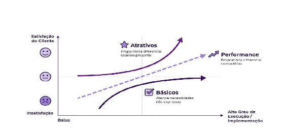

Modelo Kano: impacto de cada tipo de requisito sobre a satisfação do cliente

*Figura 1 — Gráfico demonstrando o impacto dos requisitos, em sua execução, na satisfação do cliente.*

Os três grupos podem ser definidos da seguinte maneira:

1. **Requisitos Básicos:** funcionalidades que o usuário naturalmente espera do sistema, muitas vezes esquecendo de comentar sobre. Se estiverem presentes, não causam surpresa (“faz apenas a obrigação”), mas que se estiverem ausentes geram muita insatisfação.
2. **Requisitos Performantes:** características cuja qualidade ou nível de execução influencia diretamente a satisfação do usuário. Quanto melhor o desempenho percebido, maior tende a ser a satisfação.
3. **Requisitos Atrativos:** requisitos não esperados pelo usuário, mas que caso estejam presentes geram satisfação significativa. Sua ausência não causa insatisfação.

Delineamos exemplos das três categorias, para dois contextos diferentes.

| Tipo/Sistema | Gerenciamento de Estoque | Plataforma de Cursos Online |
| --- | --- | --- |
| **Básico** | Deve ser possível cadastrar produtos. | O sistema de login deve funcionar corretamente. |
| **Performante** | Os relatórios devem ser de alta qualidade | Os cursos devem carregar rapidamente |
| **Atrativo** | Deve haver uma previsão automática de falta de estoque baseada em padrões de uso. | Uma IA deve ser capaz de sumarizar o conteúdo das últimas semanas e criar questionários personalizados. |

Abaixo, deixamos também exemplos de perguntas que podem auxiliar a extrair esses requisitos:

**Requisitos Básicos (Foco: funcionalidade, fluxo e metas):**

**>** *O sistema precisa fazer isso MUITO bem*

[output not shown]

**Requisitos Performantes (Foco: qualidade, restrições, infraestrutura):**  
**>** *O cliente raramente lembra de mencionar isso. O papel do consultor e do setor comercial é arrancar essas informações.*

[output not shown]

**Requisitos Atrativos (Foco: Inovação, Escala e Valor Agregado):**  
**>** *Entregar o diferencial da empresa, com foco na experiência do usuário, para brilhar os olhos do cliente.*

[output not shown]

**Priorização:** dados os impactos dos requisitos na satisfação dos clientes, abordados anteriormente, considera-se que os requisitos básicos prevaleçam sobre os requisitos performantes e estes sobre os atrativos, de forma que:

Requisito Básico → Alta Prioridade  
Requisito Performante → Média Prioridade  
Requisito Atrativo → Baixa Prioridade

Obviamente, fica a cargo da equipe a classificação detalhada.

### Exemplo prático: o levantamento de requisitos do Impacto Ambiental

As perguntas acima são genéricas de propósito — servem para qualquer projeto. Este tópico mostra **os três bancos aplicados a um caso real**, com as respostas que saíram e os requisitos que nasceram delas. Use como modelo da saída esperada desta etapa.

O caso é o **Impacto Ambiental**: plataforma de incentivo à reciclagem, em que o usuário leva material a um ecoponto, recebe pontos pelo que entregou e troca esses pontos por cupons de empresas parceiras.

> **O que este exemplo é.** Uma **reconstrução**. Os documentos do projeto são o Orçamento (**ORÇ**) e a Apresentação (**APR**), ambos de 18/08/2026, mais definições acordadas depois do aceite (**DEF**, 21/08/2026). **Não existe, nos registros, uma lista de requisitos classificada por Kano.** O exemplo mostra o que o levantamento teria produzido — e, no fim, liga os problemas documentados do projeto às perguntas que não chegaram a ser feitas.

> É por isso que ele ensina bem: **dois dos três eixos foram bem cobertos, e o terceiro ficou vazio.**

#### Passo 1 — O insumo bruto, antes de qualquer pergunta

O que o cliente trouxe, na linguagem dele:

> *“Um sistema para incentivar a reciclagem, permitindo o registro de materiais recicláveis coletados em ecopontos, a conversão das coletas em pontos e a troca dos pontos acumulados por benefícios — cupons de empresas parceiras.”*

E quatro perfis de gente envolvida: **usuário**, **atendente do ecoponto**, **funcionário de empresa parceira** e **administrador**.

Isso é o ponto de partida — não é o levantamento. É o que existe *antes* de aplicar os bancos de perguntas.

#### Passo 2 — Banco dos básicos, aplicado

Foco em funcionalidade, fluxo e metas. O que o sistema **precisa fazer muito bem**:

| Pergunta do banco de básicos | Resposta obtida | Requisito que nasce |
| --- | --- | --- |
| Que problema esta solução resolve hoje? | As pessoas não têm incentivo para levar recicláveis ao ecoponto | O sistema precisa converter entrega em benefício percebido |
| Qual é o processo atual, sem o sistema? | O material é recebido no ecoponto sem registro individual, e nada volta para quem entregou | Registro de coleta por usuário identificado |
| Quais são os tipos de usuário e o que cada um faz? | Usuário, atendente, empresa parceira e administrador | **Quatro perfis, quatro interfaces** |
| Quais funções são essenciais num dia típico? | Entregar material e ver os pontos entrarem; registrar a coleta no ecoponto; resgatar cupom | Registro de coleta, saldo, catálogo e resgate |
| Que regras de negócio o sistema aplica sozinho? | Pontos por quantidade pesada, **por material**, segundo a campanha vigente | Regra de conversão parametrizável |
| Que dados o sistema recebe e que resultado entrega? | Recebe material e quantidade; entrega pontos e, depois, um cupom | Fluxo coleta → pontos → cupom |
| Que informações compõem o painel ideal? | Operação por ecoponto, empresas cadastradas, usuários | Painel do Administrador |

**Resultado deste banco:** 25 funções distribuídas em 5 interfaces — a Área do Cliente, o Painel do Atendente, o Painel de Empresas, o Painel do Administrador e a Página Institucional. É a espinha do projeto, e foi bem levantada.

> **Repare no que a pergunta dos perfis produziu.** Ela é a única do banco que obriga a nomear o **administrador**. Quem opera o back-office quase nunca aparece espontaneamente na fala do cliente, porque ele descreve o produto pela ótica de quem o usa por fora.

#### Passo 3 — Banco dos performantes: o eixo que ficou vazio

Foco em qualidade, restrições e infraestrutura. O `1.3` avisa, no cabeçalho deste banco, que *“o cliente raramente lembra de mencionar isso — o papel do consultor e do setor comercial é arrancar essas informações”*. **Neste projeto, não foi arrancado.**

| Pergunta do banco de performantes | Foi feita? | Consequência |
| --- | --- | --- |
| Qual o volume esperado? Quantos usuários simultâneos no pico? | **Não** | O número existia — 500.000 usuários mensais — mas apareceu **só** para estimar o custo de hospedagem (US$ 40 a US$ 150). Nunca virou requisito → `C-05` |
| O que acontece se o sistema cair por 10 minutos? E por 4 horas? | **Não** | Nenhum requisito de disponibilidade, nenhum SLA, nenhuma política de backup |
| Quem acessa os dados? O que é sensível? LGPD? | **Não** | A segregação por perfil e o hash de senhas existem (`RNF-04`, `RNF-05`, `RNF-06`) — mas como `[DER]`: **a IDE deduziu, o cliente não pediu** |
| Precisa funcionar em algum dispositivo ou ambiente específico? | **Não** | A responsividade (`RNF-02`) também é `[DER]` |
| Com quais outros softwares o sistema precisa conversar? | **Não** | Virou exclusão (`RE-12`) em vez de requisito levantado |

**O achado mais importante deste exemplo está na primeira linha.** O número `500.000` estava no orçamento — escrito, aceito, assinado. Ele só não estava no lugar certo: entrou como **parâmetro de custo**, não como **requisito de carga**. A Proposta Formal precisou registrar explicitamente que aquele número *“não constitui meta de desempenho, capacidade contratada, compromisso de disponibilidade ou nível de serviço”*.

> **A lição operacional:** um número dito pelo cliente não vira requisito sozinho. Ele vira requisito quando alguém pergunta *“e o que o sistema precisa aguentar, então?”*. Sem essa pergunta, o número fica no documento parecendo compromisso e não sendo nenhum.

E note a diferença entre `[DOC]` e `[DER]` nas linhas 3 e 4: ter o requisito não é a mesma coisa que tê-lo **levantado**. Um `RNF` que a IDE deduziu sozinha é uma aposta — bem-intencionada, mas uma aposta, e o cliente pode discordar dela depois da assinatura.

#### Passo 4 — Banco dos atrativos: onde o projeto acertou

Foco em inovação, escala e valor agregado. Aqui o levantamento funcionou — e o resultado talvez seja contraintuitivo:

| Pergunta do banco de atrativos | O que apareceu | Virou |
| --- | --- | --- |
| Se pudéssemos automatizar algo tedioso, o que seria? | Leitura automática do peso por balança integrada | `RE-02` |
| Viu algo em outro sistema e pensou “seria incrível ter”? | Identificação por QR code, cartão ou crachá | `RE-18` |
|  | Ranking, medalhas, metas, desafios | `RE-14` |
|  | Aplicativo móvel instalável | `RE-01` |
| Se orçamento e tempo não fossem problema? | Reconhecimento do material por imagem, com IA | `RE-19` |
|  | Painel público de impacto ambiental agregado | `RE-22` |
|  | Portal para catadores e cooperativas, com roteirização | `RE-21` |

**Sete atrativos identificados, sete atrativos excluídos.** E isso é um **bom** resultado, não um mau: o atrativo é, por definição, aquilo cuja ausência não gera insatisfação. Nomeá-lo e deixá-lo de fora **por escrito** é o que impede que ele volte no meio do projeto como “mas eu achei que tinha”.

> **Este banco não existe para inchar o escopo.** Ele existe para descobrir o que o cliente sonha, decidir conscientemente o que fica de fora, e transformar esse sonho na **próxima proposta** — em vez de em uma discussão desconfortável na entrega. Boa parte das 31 exclusões contratuais do projeto nasce daqui.

#### Passo 5 — A classificação Kano do projeto

O mesmo formato de três linhas usado no início da seção, agora preenchido:

| Tipo | Impacto Ambiental |
| --- | --- |
| **Básico** | Registrar a coleta e creditar os pontos corretamente; o login funcionar; o saldo bater com o histórico |
| **Performante** | Rapidez do registro no balcão do ecoponto; o mapa achar o ecoponto certo; o sistema aguentar o pico de movimento — **nunca levantado** |
| **Atrativo** | Reconhecer o material por imagem; ranking entre usuários; painel público de impacto ambiental — **excluídos** |

**A linha do meio é o retrato do problema.** Ela não está vazia porque o projeto não tinha requisitos performantes; está vazia porque ninguém perguntou por eles.

#### Passo 6 — Priorizar e marcar a evidência

A prioridade sai direto da classificação — básico sobre performante, performante sobre atrativo. Mas priorizar não basta: cada requisito também carrega **de onde ele veio**, na convenção que a análise comercial usa logo em seguida:

| Tag | Significa | No Impacto Ambiental |
| --- | --- | --- |
| `[DOC]` | O cliente disse — está no registro | Os 25 itens funcionais do orçamento |
| `[INFER]` | A IDE deduziu; **precisa confirmação** | `RNF-02`, `RNF-04`, `RNF-05`, `RNF-06` |
| `[GAP]` | Indefinido e relevante para o preço | Carga e desempenho (`C-05`); quem paga o provedor de mapas (`C-01`) |

**Um requisito sem tag é um requisito sem dono.** Quando `[DOC]` e `[INFER]` se misturam numa lista só, uma dedução da IDE passa a parecer pedido do cliente — e ninguém percebe até alguém cobrar a entrega dela.

#### Passo 7 — O que este levantamento entrega para a próxima etapa

O produto do `1.3` é a **tabela funcional**, e ela é exatamente o que o `1.4.2.2` exige como portão de entrada para o esboço:

| Coluna | Conteúdo |
| --- | --- |
| Id | `F1` … `F25` |
| Função | No vocabulário do cliente, não no técnico |
| Ator | Usuário, Atendente, Empresa parceira ou Administrador |
| Kano | Básico, Performante ou Atrativo |
| Evidência | `[DOC]`, `[INFER]` ou `[GAP]` |

Sem essa tabela fechada, **o esboço do `1.4.2` não começa** — e o exemplo completo de como ela é usada está no tópico final daquela seção.

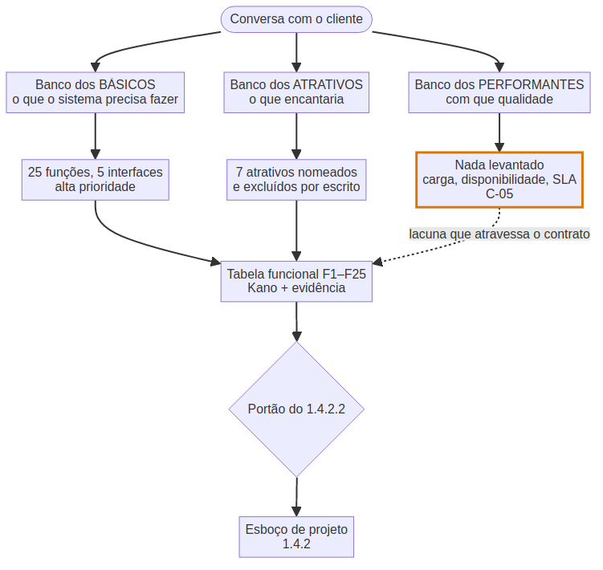

#### O placar deste levantamento

| Eixo Kano | Cobertura | Efeito no projeto |
| --- | --- | --- |
| **Básico** | Boa | As 25 funções viraram 35 requisitos contratuais coerentes |
| **Performante** | **Nenhuma** | `C-05` — sem requisito de carga; e o `500.000` do orçamento parecendo compromisso sem ser |
| **Atrativo** | Boa | 7 atrativos nomeados e excluídos, alimentando as 31 exclusões |

**Dois de três.** O eixo que faltou não derrubou o projeto, mas deixou uma pendência aberta que atravessou a assinatura — e requisitos não funcionais que são dedução da IDE, não declaração do cliente.

> **O que o membro leva deste exemplo:** o banco dos básicos é o fácil, porque o cliente fala dele sozinho. O banco dos atrativos é o divertido, e rende a próxima proposta. **O banco dos performantes é o que ninguém faz, e é o único cujo esquecimento você só descobre depois da assinatura.** Se a segunda reunião tiver tempo para um só, faça esse.

## 1.4 Análise de Projeto

A análise de projeto tem duas metades que se alimentam mutuamente: decidir **com que tecnologia** o projeto será construído e desenhar **o que** será construído. Elas podem — e frequentemente devem — ocorrer na mesma sessão de trabalho da dupla Comercial × Projetos, logo após a segunda reunião com o cliente.

### 1.4.1 Análise de tecnologias

A análise de tecnologias depende muito do estado das tecnologias no momento em que se lê esse manual/se realiza a análise do projeto. Nesse sentido, colocamos abaixo links referentes aos documentos de análise de cada stack (Web e Mobile) e para banco de dados, para servirem como uma maneira de adquirir conhecimento a respeito das ferramentas. No entanto, muito provavelmente, adotar-se-á uma stack já consagrada pela empresa, salvo exceções que valham a pena quebrar a regra. E é por esse motivo, a **possibilidade de existirem exceções que valham a pena quebrar a regra**, que adicionamos essa seção no manual, para, caso venham a existir, os membros estejam preparados para **identificar essas oportunidades**.

Definição de ‘**Stack consagrada pela empresa’:**

**“Entende-se por ‘stack consagrada’ a stack padrão da IDE, que pode ser consultada ao Diretor de Gestão de projetos e que pode ser consultada na área da guilda de ‘desenvolvimento web’ nas Guildas da IDE.”**

Links para análise de exceções comentadas acima:

[Stacks Web [preliminar]](https://docs.google.com/document/d/1bdYFDbXrLzu_tuFOt3xGanh4bDlSdyV4clp68WmDxj4/edit?usp=drive_link)

[Stacks Mobile [preliminar]](https://docs.google.com/document/d/1dFraFR0ouKXso_mhScuAXlGakE5vqMGhHqhE66vOWxc/edit?usp=drive_link)

[Banco de dados [preliminar]](https://docs.google.com/document/d/1MNRD75il73fvl58sY7P9fw9VEIDujz7Wl8JirKPNgl4/edit?usp=drive_link)

### 1.4.2 Esboço de projeto: “Diagrama de caixinhas”

> **Status:** seção de **propriedade conjunta** Comercial × Projetos (ver `1.4`). Onde este texto propõe algo que ainda não é prática consolidada da IDE, isso está dito explicitamente. Números de tempo (`§1.4.2.3`) são **proposta a calibrar**, não medição.

#### Por que esta seção existe

O objetivo declarado do capítulo 1 é *“remover o gargalo de comunicação entre o que o cliente pede e o que o desenvolvedor entende”*. O esboço de projeto é o artefato que faz isso de forma visível: é onde o escopo deixa de ser uma lista de frases e passa a ser um **mapa que as duas partes conseguem olhar ao mesmo tempo**.

O custo de não ter essa etapa padronizada não é hipotético. O contrato **Impacto Ambiental** (orçamento aceito em 18/08/2026, R$ 38.500,00, 35 requisitos funcionais) chegou à Proposta Formal com quatro problemas que um mapa de caixinhas desenhado **antes do preço** teria exposto:

[output not shown]

Nenhum desses quatro é erro de programação. Todos os quatro são **erros de mapa**.

#### 1.4.2.1 O que é o esboço

O esboço de projeto é o **farol** do projeto. Ele tem dois leitores e três funções.

**Dois leitores:**

- **A IDE** — é o guia dos próximos passos e a trava contra divergir do escopo combinado.
- **O cliente** — é o que torna a proposta compreensível para quem não lê especificação de software.

**Três funções:**

1. **Mapa de próximos passos.** Depois de assinado, Projetos não começa do zero: as caixas viram linhas da Matriz de Requisitos Funcionais (`2.4.1`).
2. **Trava de escopo.** O que não tem caixa não tem requisito; o que não tem requisito não entra em sprint, entra em termo aditivo.
3. **Elucidação comercial.** Em projetos grandes, um mapa bem-feito demonstra o caráter formal da IDE de um jeito que texto não demonstra — e é o insumo que permite dividir a entrega em etapas e sprints.

**E o que ele não é.** É um **esboço**, não uma especificação. A regra é *apegar-se à ideia e ao esboço para ser útil, não estar corretíssimo na formalidade*. Isso não é licença para ser vago: é uma decisão de **onde parar**, e essa decisão está escrita como regra em `§1.4.2.6`. Um esboço que tentou ser especificação queimou horas de pré-venda não pagas e enviesou a arquitetura antes da hora; um esboço que não chegou ao nível da tela não serve para estimar nada.

#### 1.4.2.2 Quando fazer: o portão de entrada

> **Regra dura: o esboço só é desenhado depois da extração do escopo, de forma estruturada e completa.** Desenhar antes disso produz um mapa do sistema que a dupla imaginou, não do sistema que o cliente descreveu.

“Estruturada e completa” precisa ser verificável, senão vira opinião. O critério proposto reutiliza o template que já existe no processo — a **tabela funcional** do método de análise — em vez de criar artefato novo:

**Portão de entrada — só passa se as cinco linhas estiverem verdadeiras:**

- Toda capacidade tem **id estável** (`F1`, `F2`, …).
- Toda capacidade tem **classificação Kano** (básico / performante / atrativo, `1.3`).
- Toda capacidade tem **tag de evidência**: `[DOC]` (o cliente disse), `[INFER]` (nós deduzimos), `[GAP]` (indefinido e relevante).
- O **back-office está na tabela** — se alguém precisa revisar, aprovar, cadastrar ou moderar algo, a ferramenta dessa pessoa é uma capacidade, não um detalhe.
- **Nenhum `[GAP]` está em cima de uma fronteira de módulo.** Gap dentro de uma tela é normal e vira pergunta. Gap que decide *se um painel inteiro existe* trava o esboço — resolva por e-mail antes de desenhar.

**Posição no pipeline:**

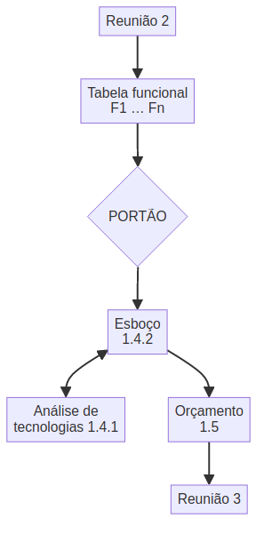

O `1.4` já avisa que `1.4.1` e `1.4.2` têm dependência recursiva e podem ocorrer misturados — **é o comportamento esperado**: uma caixa muda a tecnologia, a tecnologia muda o desenho da caixa. Continuam sendo dois relatórios distintos.

#### 1.4.2.3 Quem faz, como e em quanto tempo

**Quem:** a **dupla comercial × projetos**, em sessão conjunta, conforme `1.4`.

**Por que Projetos tem que estar na sala, e não apenas revisar depois:** a caixa é a **unidade de estimativa**. O modelo de capacidade estima *por módulo, uma linha cada* — se as caixas foram desenhadas por quem não vai construir, a estimativa é feita sobre uma divisão que não corresponde ao trabalho real.

**Como:** ao vivo, desenhando junto, o Comercial narrando o que o cliente disse e Projetos perguntando “isso é uma tela ou é um sistema?”. O `1.4` sugere emendar essa sessão logo após a segunda reunião, enquanto a conversa está fresca. É a recomendação certa.

**Tempo — proposta a calibrar após dois projetos:**

| Porte | Referência | Sessão proposta | Camadas |
| --- | --- | --- | --- |
| Pequeno | Site institucional, 1 ator | ~1 h | V1 mínimo + fichas de tela |
| Padrão | 2–3 módulos, 2 atores | ~2 h | V1 + V2 + fichas |
| Grande | 4+ módulos, 3+ atores (porte Impacto Ambiental) | 2 sessões de ~2 h | V1 + V2 por ator + fichas |

**Projeto pequeno com a segunda reunião pulada** (atalho do `1.1`): o esboço não desaparece, ele encolhe. V1 vira uma caixa e o esforço vai para o **MVP/mockup**, que o Manual já recomenda por aumentar a taxa de fechamento. As **fichas de tela** (`§1.4.2.4.3`) continuam valendo a pena: são elas que permitem estimar.

#### 1.4.2.4 As três camadas

O esboço desce em três altitudes. Cada uma responde uma pergunta diferente, e é normal que a terceira só seja feita para parte das telas.

##### 1.4.2.4.1 V1 — Mapa de módulos e atores (“as caixinhas”)

**Pergunta:** *quantos produtos nós estamos construindo, e quem usa cada um?*

Esta é a camada que as pessoas costumam chamar de “diagrama de casos de uso”. Uma observação importante de coerência interna: **a IDE não usa o Diagrama de Casos de Uso da UML** — o `2.4` substitui esse diagrama pelos três pilares (MRF, User Stories, User Flow). O V1 entrega a *leitura* que se espera de um caso de uso (quem é o ator, o que ele alcança) **sem ser** um diagrama UML de casos de uso, e sem duplicar nada do capítulo 2.

**Regras do V1:**

1. **Toda caixa tem um ator.** Caixa sem ator é caixa esquecida — e a caixa que mais se esquece é a do administrador.
2. **Conte interfaces, não funcionalidades.** Dois perfis de usuário mais um back-office são **três produtos**. É o número que mais muda a percepção de tamanho do cliente — e o seu.
3. **O back-office é um produto, não um apêndice.** Se um humano precisa cadastrar, aprovar, revisar ou moderar algo, a ferramenta dele é caixa com preço.
4. **Setas de dependência são obrigatórias.** Se o módulo B não funciona sem um cadastro que mora no módulo A, desenhe a seta. É aqui que faseamento errado aparece antes de virar contrato.
5. **Dependências externas entram como caixa** (provedor de mapas, serviço de e-mail, gateway). Toda caixa externa carrega a pergunta: **quem paga e em nome de quem está a conta?**
6. **Nome de caixa é vocabulário do cliente**, não nome técnico. “Painel do Atendente”, não “módulo operacional”.

**Exemplo — V1 do Impacto Ambiental:**

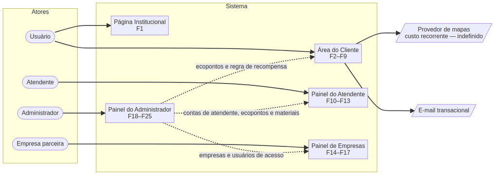

**O que esse desenho diz em dez segundos, e que o orçamento não disse:**

- São **cinco produtos**, não “um sistema”.
- **Três setas saem do Painel do Administrador para os outros módulos.** Ele não é a última etapa: ele é pré-requisito das outras. Qualquer faseamento que o coloque por último cria trabalho manual não previsto — foi exatamente o que aconteceu.
- Existem **duas dependências externas com custo recorrente** e nenhuma delas tinha dono definido no momento do orçamento (`C-01`).

##### 1.4.2.4.2 V2 — Jornada do usuário (alto nível)

**Pergunta:** *o que essa pessoa faz, do início ao fim, para conseguir o que ela quer?*

Uma jornada **por ator**, caminho feliz, entre 5 e 9 caixas. Usa **exatamente o mesmo vocabulário Mermaid do `2.4.3`** — `([pílula])` para início/fim, `[retângulo]` para tela/ação, `{losango}` para decisão — para que o User Flow do capítulo 2 seja um **refinamento** desta jornada, e não um desenho novo.

**Exemplo — jornada do Atendente (Impacto Ambiental):**

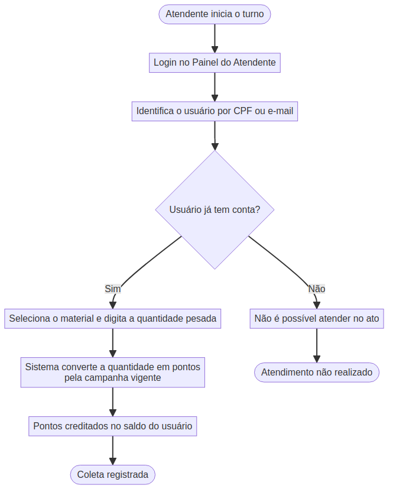

**Por que esse losango específico vale ouro.** Ele obriga a pergunta *“e se o usuário não tiver conta?”*. No Impacto Ambiental essa pergunta tinha resposta no orçamento — havia um item pago para o atendente cadastrar o usuário no ecoponto — e esse item foi **retirado depois do aceite** (`RE-26`), sem reconciliar o preço da etapa (`C-08`). O ramo “Não” é uma **consequência operacional real**: o usuário precisa ter conta *antes* de ir ao ecoponto. Desenhar a jornada força essa conversa com o cliente enquanto ela ainda é barata.

##### 1.4.2.4.3 V3 — Esboço da lógica de cada tela (“ficha de tela”)

**Pergunta:** *o que essa tela precisa para existir?* É aqui que o esboço **quebra nas partes mais técnicas** — e é o que torna uma caixa estimável.

Não é wireframe. É meia página por tela, no seguinte formato:

| Campo | Conteúdo |
| --- | --- |
| **Tela** | Registro de coleta |
| **Caixa (V1)** | Painel do Atendente |
| **Requisitos** | `F10`, `F11`, `F12` (viram `RF-ATD-02/03/04/05`) |
| **O que o usuário vê** | Busca de usuário; lista de materiais aceitos; campo de quantidade; pontos resultantes |
| **O que ele faz** | Digita CPF ou e-mail → confirma o usuário → escolhe o material → digita a quantidade pesada → confirma |
| **De onde vem o dado** | Usuários (autocadastro); materiais aceitos (**cadastro do administrador**); regra de conversão (**campanha vigente**) |
| **O que exige do sistema** | Busca por dois campos distintos; tabela de materiais parametrizável; regra de conversão configurável; escrita no saldo de pontos |
| **Depende de** | Cadastro de materiais e campanha vigente **precisam existir antes** desta tela funcionar |
| **Fora desta tela** | Leitura automática de peso; identificação por QR code; cadastro de usuário pelo atendente |

**Faça ficha para:** telas com regra de negócio, cálculo, permissão, dinheiro ou pontos; e para toda tela que a dupla não consegue estimar olhando só para o V1. **Não faça ficha para:** telas de listagem simples, páginas institucionais estáticas, login padrão.

Repare no que a linha **“Fora desta tela”** produziu: os três itens viraram `RE-02`, `RE-18` e `RE-26` na Proposta Formal. **A lista de exclusões nasce aqui**, de graça, durante o desenho — não depois, sob pressão, quando o cliente já criou expectativa.

#### 1.4.2.5 Convenções visuais

O esboço carrega a mesma disciplina de evidência da análise, de forma visível:

| Convenção | Significa | Mermaid |
| --- | --- | --- |
| Borda contínua | `[DOC]` — o cliente disse | padrão |
| **Borda tracejada** | `[INFER]` — nós deduzimos; **precisa confirmação** | `stroke-dasharray: 5 5` |
| Borda destacada | `[GAP]` — indefinido e relevante para o preço | `stroke-width:3px` |
| **Cinza** | **Fora de escopo** — mostrado de propósito | preenchimento neutro |

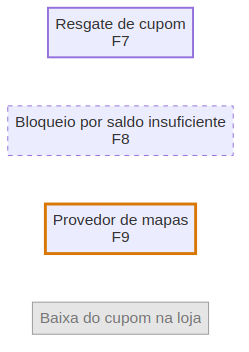

**Duas consequências práticas, e são o motivo da convenção existir:**

- **Toda caixa tracejada é uma pergunta da terceira reunião.** *“Entendemos que o sistema deve bloquear o resgate quando o saldo não cobre o cupom — confere?”* Confirmado, vira `[DOC]` antes da assinatura. É a redução de risco mais barata disponível no processo inteiro. No Impacto Ambiental, `RF-USR-08` (esse mesmo bloqueio) entrou como `[DER]`: ninguém tinha perguntado.
- **Toda caixa cinza é escopo negativo já registrado.** `Won't Have` não é lixeira — é o registro escrito do que foi excluído, e a semente da próxima proposta.

**Ferramenta:** Mermaid, editável em `mermaid.live`, com o código-fonte versionado junto aos documentos do projeto. O `2.4` já padroniza Mermaid para User Flow e Diagrama de Classes — usar o mesmo formato aqui sai de graça e faz o desenho pré-contratual sobreviver à rotatividade, porque diagrama que é texto entra no repositório e diagrama que é imagem não.

#### 1.4.2.6 Onde o esboço para

Esta seção é a tradução de *“não se apegar à formalidade”* em regra verificável.

**O esboço NÃO contém:**

[output not shown]

**O teste da caixa — as duas perguntas que decidem o tamanho certo:**

> 1. **Projetos consegue estimar essa caixa em sprints?** Se não, ela está grossa demais: quebre.
> 2. **Comercial consegue explicar essa caixa ao cliente em uma frase?** Se não, ela está fina demais ou técnica demais: funda com a vizinha ou renomeie.

Uma caixa que passa nas duas está do tamanho certo. Uma caixa que falha nas duas geralmente não é uma caixa — é um módulo disfarçado ou um detalhe de implementação.

O `2.4.4` já registra o princípio para o Diagrama de Classes, e ele vale igual aqui: **modele a arquitetura e o fluxo principal, não superdetalhe** — detalhe excessivo vira viés e burocracia na implementação. No pré-contrato o custo é ainda maior, porque essas horas **não são pagas**.

#### 1.4.2.7 Do esboço ao orçamento e às etapas

O esboço é o que torna possível dividir o projeto. A conversão é direta:

```
caixa do V1  →  linha do modelo de capacidade (squad-sprints)  →  candidata a etapa/entrega
```

**Três testes antes de fechar o faseamento:**

1. **Teste de independência.** Para cada etapa: *“se o cliente parar aqui, o que ele tem e isso é utilizável?”* Toda etapa precisa responder que sim. Se uma não responde, **a divisão está errada — conserte a divisão**, não a explicação.
2. **Teste de dependência.** Siga as setas do V1. **Ordene as etapas por dependência, não por entusiasmo do cliente.** No Impacto Ambiental as setas apontam do Painel do Administrador para os Painéis do Atendente e de Empresas, e mesmo assim o administrador ficou na Etapa 4 — as Etapas 2 e 3 passaram a depender de “carga técnica” manual para funcionar.
3. **Teste de conciliação.** Antes de montar a apresentação, confira as três listas lado a lado:

   | Caixa do V1 | Id `F` na tabela funcional | Linha no orçamento |
   | --- | --- | --- |

   **As três colunas têm que fechar.** Caixa sem linha de preço é escopo não pago. Linha de preço sem caixa é promessa sem desenho. E quando um item precificado sai do escopo, **o preço da etapa tem que ser reconciliado explicitamente** — foi essa conciliação que faltou em `C-08`, onde a Etapa 2 permaneceu em R$ 9.625,00 com escopo reduzido.

#### 1.4.2.8 O esboço na terceira reunião

O esboço vai para a apresentação **antes do preço** — o preço é sempre o último assunto (`1.1`).

**Mostre:** o V1 completo, as jornadas (V2) dos atores principais e as caixas cinzas de exclusão. **Não mostre:** fichas de tela (V3). Elas são insumo interno de estimativa; em reunião, viram discussão de detalhe antes da hora.

**Duas regras que evitam o erro mais caro desta etapa:**

> **Regra 1 — toda caixa exibida ao cliente corresponde a uma linha precificada.** Se aparece no slide, está no orçamento. Se não está no orçamento, aparece **em cinza**, marcada como fora do escopo.

> **Regra 2 — o esboço ilustra o escopo; ele não define o escopo.** A definição contratual é a **lista enumerada de requisitos**. Em caso de divergência entre o desenho e a lista, **prevalece a lista**. Diga isso na reunião e registre no documento.

A Regra 1 é a correção direta de `RE-03` e `RE-04`: a apresentação descreveu autocadastro de empresas e gestão de usuários pelo lojista, o orçamento não previa nenhum dos dois, e a divergência foi resolvida meses depois **contra a expectativa do cliente**. Uma caixa cinza na apresentação — *“gestão de usuários pelo próprio lojista: fora desta proposta”* — teria custado uma frase.

**Enquadramento ao apresentar:** *“este é o mapa do que vamos construir, no nível de módulos e jornadas. Não é o design das telas — o design é feito com vocês na primeira fase do projeto.”* O desenho é deliberadamente esquemático (sem cor, sem layout) **justamente para não ser lido como promessa visual**. Essa é a diferença entre o esboço e o mockup do atalho de projeto pequeno: o mockup existe para o cliente imaginar o produto; o esboço existe para as duas partes concordarem sobre o tamanho dele.

#### 1.4.2.9 Riscos e gargalos

| Risco | Como se manifesta | Mitigação |
| --- | --- | --- |
| **Detalhamento excessivo** | A dupla gasta dias desenhando; vira um pré-projeto não pago e enviesa a arquitetura antes do capítulo 2 | Regras de parada (`§1.4.2.6`) + time-box (`§1.4.2.3`) + teste da caixa |
| **Cliente lê como promessa de design** | *“mas na apresentação essa tela tinha o campo X”* | Estilo esquemático; enquadramento da Regra 2 (`§1.4.2.8`); design é `2.3`, durante contrato |
| **Esboço diverge do orçamento** | Caixa apresentada sem linha de preço (`RE-03`/`RE-04`); item precificado retirado sem reconciliar valor (`RE-26`/`C-08`) | Teste de conciliação (`§1.4.2.7.3`) obrigatório antes de montar a apresentação |
| **Esboço envelhece** | O que foi combinado na terceira reunião não volta para o desenho; Projetos recebe um mapa errado | O esboço é **versionado junto com o orçamento**; o que se repassa é a versão aceita |
| **Caixa sem ator** | O back-office some e reaparece como trabalho não previsto (`RF-ADM-01/07/08/09/10`) | Regra 1 do V1: toda caixa tem ator; quem revisa/aprova/cadastra tem ferramenta |
| **O membro desenha o sistema que ele construiria** | Requisito inferido é apresentado como pedido do cliente; ninguém percebe seis semanas depois | Borda tracejada para `[INFER]`; toda caixa tracejada vira pergunta na terceira reunião |
| **Escopo criado pela própria IDE** | Um item excluído reaparece em documento técnico interno — aconteceu com um e-mail de comprovante de depósito, excluído por `RE-17`, que entrou na proposta de stack | Caixa sem id `F` não existe; conferir o esboço contra a lista de exclusões antes do repasse |
| **Tecnologia fora da pilha aparece tarde** | O Research Card vira custo de cronograma descoberto **depois** da assinatura — foi o caso da troca de pilha do Impacto Ambiental | Flag de pilha por caixa (`§1.4.2.10`) preenchida na mesma sessão, junto com `1.4.1` |
| **Requisito de volume/desempenho nunca perguntado** | O orçamento menciona 500.000 usuários e nenhum requisito não funcional de carga foi levantado (`C-05`) | A linha *“de onde vem o dado”* da ficha de tela (`§1.4.2.4.3`) expõe volume; o que ela expuser volta para as perguntas performantes do `1.3` |

**Um risco que o esboço não resolve, e é honesto dizer:** ele não corrige elicitação ruim. Se a segunda reunião não aconteceu ou não atacou os requisitos performantes, o esboço vai ser um mapa bonito de um escopo incompleto. O portão do `§1.4.2.2` existe para impedir isso, mas ele só funciona se alguém o aplicar de verdade.

#### 1.4.2.10 Alinhamento Comercial × Projetos: o repasse

O esboço é o **pacote de repasse** do Comercial para Projetos. Se ele estiver certo, a Matriz de Requisitos Funcionais é um refinamento; se estiver errado ou ausente, Projetos refaz a análise do zero — e refazer análise é o custo que o Manual inteiro existe para evitar.

**Cadeia de rastreabilidade completa:**

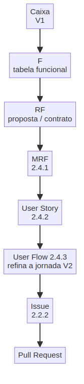

O `2.4` já exige que **toda Issue rastreie até um `RF`**. O esboço é o que garante que todo `RF` rastreie de volta até uma **caixa que o cliente viu e entendeu**.

**Flag de pilha por caixa.** Na mesma sessão, Projetos marca cada caixa contra a pilha padrão:

| Flag | Significa | Consequência comercial |
| --- | --- | --- |
| ✅ | Dentro da pilha padrão | Nenhuma |
| ⚠️ | Dentro da pilha, mas incomum | Avaliar **adiar** antes de adotar — costuma ser mais barato |
| ❌ | Fora da pilha padrão | **Research Card**, que é **custo de cronograma**, não formalidade. Precisa estar no prazo e no preço |

É esse flag que endereça o caso mais caro do Impacto Ambiental: a pilha do projeto acabou sendo **NestJS + React** em vez de **Django + Next.js**, o que exige Research Card aprovado antes da Sprint 1 e uma reemissão de `RNF-03` pelo Comercial — decisões tomadas *depois* da assinatura, sobre um requisito não funcional já contratado. Uma coluna de flag preenchida durante `1.4.1`/`1.4.2` teria colocado essa decisão antes do preço.

**Definition of ready — o que Projetos recebe para poder começar:**

- V1 com atores, dependências internas e dependências externas
- V2 para cada ator principal
- Fichas de tela das telas com regra de negócio, permissão, cálculo, dinheiro ou pontos
- Tabela funcional com ids `F`, Kano e tags de evidência
- Flags de pilha por caixa, com os ❌ nomeados como Research Card
- Lista de caixas cinzas (o escopo negativo)
- Lista de perguntas em aberto, ordenada por quanto cada uma mexe no preço
- Versão do esboço **igual** à versão do orçamento aceito

#### 1.4.2.11 Estudo de caso: o que o esboço teria pego

Aplicando o método retroativamente ao Impacto Ambiental:

| Achado real | Camada que pega | Como |
| --- | --- | --- |
| `RF-ADM-01` — login do administrador não orçado | **V1** | Regra “toda caixa tem ator”: o ator Administrador existe, logo o acesso dele é caixa |
| `RF-ADM-07/08/09/10` — quatro cadastros não orçados | **V1** | Setas de dependência: os outros painéis não funcionam sem eles |
| Etapas 2 e 3 dependendo da Etapa 4 | **V1 + `§1.4.2.7.2`** | Teste de dependência sobre as setas, antes de fechar o faseamento |
| `RF-USR-03`, `RF-USR-04` — recuperação de senha e logout | **V2** | A jornada do usuário tem começo e fim; “sair” e “esqueci a senha” aparecem ao percorrê-la |
| `RF-USR-08` — bloqueio por saldo insuficiente | **V3** | A ficha de “Resgate de cupom” pergunta o que o sistema exige; a regra aparece |
| `RE-03`/`RE-04` — apresentação prometendo além do orçamento | **`§1.4.2.8`, Regra 1** | Caixa exibida sem linha de preço não passa na conciliação |
| `RE-26`/`C-08` — item retirado com preço não reconciliado | **`§1.4.2.7.3`** | Teste de conciliação: caixa ↔︎ `F` ↔︎ linha de preço |
| `C-01` — provedor de mapas sem dono de custo | **V1** | Dependência externa é caixa, e caixa externa carrega a pergunta “quem paga?” |
| Troca de pilha exigindo Research Card pós-assinatura | **`§1.4.2.10`** | Flag ❌ por caixa durante `1.4.1` |
| `RE-17` — item excluído reaparecendo em documento técnico | **`§1.4.2.10`** | Caixa sem id `F` não existe |

**Dois achados que o esboço NÃO teria pego,** e vale registrar para não vender o artefato como mais do que ele é:

- **`C-02` — o orçamento informa “21 de fevereiro” sem o ano.** É revisão de documento comercial, assunto do `1.5`.
- **`C-05` — ausência de requisitos de carga e desempenho.** É falha de elicitação (`1.3`, requisitos performantes). O esboço no máximo *sugere* a pergunta pela linha “de onde vem o dado”; quem tinha que fazê-la era a segunda reunião.

#### 1.4.2.12 Checklist de conclusão

Rodar **antes** de montar o orçamento (`1.5`):

- Portão do `§1.4.2.2` passou — tabela funcional fechada, com ids, Kano e tags
- V1 desenhado, com todos os atores, incluindo o back-office
- Número de interfaces declarado por extenso (“são N produtos”)
- Todas as dependências entre módulos desenhadas como seta
- Dependências externas desenhadas, cada uma com dono de custo definido ou marcada `[GAP]`
- V2 desenhado para cada ator principal, caminho feliz, vocabulário do `2.4.3`
- Fichas de tela feitas para toda tela com regra, permissão, cálculo, dinheiro ou pontos
- Caixas `[INFER]` tracejadas e transformadas em perguntas da terceira reunião
- Caixas de exclusão em cinza, prontas para virar escopo negativo
- Flag de pilha em toda caixa; todo ❌ nomeado como Research Card com prazo
- Teste de independência e teste de dependência aplicados ao faseamento proposto
- Conciliação caixa ↔︎ `F` ↔︎ linha de orçamento fechando nas três colunas
- Esboço revisado pela outra metade da dupla
- Versão do esboço registrada e igual à do orçamento que será apresentado

#### 1.4.2.13 Exemplo prático: o processo completo, do início ao fim

As seções anteriores ensinam o método em partes. Esta mostra **uma execução inteira, na ordem em que acontece**, com os artefatos que a dupla deve entregar ao final. Use como **modelo da saída esperada** desta etapa.

O caso é o **Impacto Ambiental** — plataforma de incentivo à reciclagem, orçamento aceito por **R$ 38.500,00**, que a Proposta Formal viria a enumerar como **35 requisitos funcionais, 12 não funcionais e 31 exclusões**. O exemplo é uma reconstrução: mostra o que **teria sido produzido** se o esboço existisse à época. No fim, o placar honesto do que ele teria pego.

##### Passo 0 — Verificar o portão

Antes de desenhar qualquer coisa, a tabela funcional precisa estar fechada (`§1.4.2.2`). **Sem ela, a sessão não começa.** Recorte do que entrou:

[output not shown]

**Leitura do portão:** 25 funções, 4 atores, tudo com evidência `[DOC]`. Nenhuma linha `[INFER]` ainda — elas vão aparecer *durante* o desenho, e é justamente esse o valor do desenho.

##### Passo 1 — V1: desenhar o mapa

Quatro movimentos, nesta ordem. Não pule o terceiro.

1. **Liste os atores.** Usuário, Atendente, Empresa parceira, Administrador. *Quem aprova, cadastra ou revisa alguma coisa?* — essa pergunta é o que impede o back-office de sumir.
2. **Agrupe as funções em interfaces.** Cada grupo que um ator opera de ponta a ponta é uma caixa.
3. **Desenhe as setas de dependência.** *Este módulo funciona sem nenhum cadastro que mora em outro?* Se não funciona, a seta existe.
4. **Acrescente as dependências externas**, cada uma com a pergunta de custo.

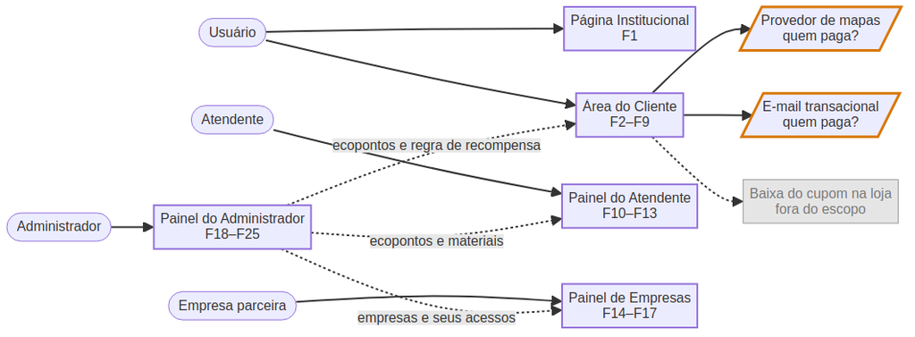

**O que o movimento 1 já produziu:** o Administrador é ator, logo **o acesso dele é caixa**. Esse único passo produz `RF-ADM-01` — que não estava no orçamento aceito.

**O que o movimento 3 já produziu:** as três setas tracejadas saindo do Painel do Administrador. Os cadastros que elas representam — ecopontos, contas de atendente, empresas, materiais — viraram `RF-ADM-07`, `RF-ADM-08`, `RF-ADM-09` e `RF-ADM-10`. **Nenhum dos quatro estava no orçamento aceito.**

**O que o movimento 4 já produziu:** duas caixas `[GAP]` de custo recorrente sem dono. Uma delas permanece em aberto até hoje (`C-01`).

##### Passo 2 — Declarar o número de produtos

> **“São cinco produtos, não um sistema.”**

Uma frase, dita em voz alta, antes de qualquer estimativa. É o momento em que o tamanho real do projeto entra na cabeça das duas partes — inclusive na de quem vai orçar.

##### Passo 3 — V2: percorrer a jornada de cada ator

Uma jornada por ator, caminho feliz, 5 a 9 caixas, vocabulário do `2.4.3`. A jornada do Atendente está em `§1.4.2.4.2`; abaixo, a do **Usuário** — a maior etapa do contrato.

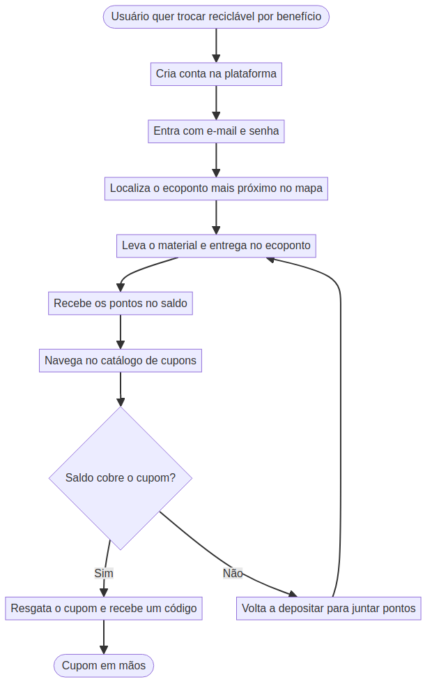

**Três requisitos nascem de percorrer esta jornada, e nenhum deles estava no orçamento:**

- **A jornada tem um começo antes do começo.** *E se a pessoa esquecer a senha?* → `RF-USR-03`.
- **A jornada tem um fim depois do fim.** *E como ela sai?* → `RF-USR-04`.
- **O losango não é decorativo.** *E se o saldo não cobrir?* → `RF-USR-08`.

O mesmo exercício, aplicado às outras jornadas, produz `RF-ATD-06` (o atendente precisa conferir o que registrou no turno) e `RF-EMP-05` (a empresa precisa poder tirar um cupom do ar).

> **Atenção ao losango do Atendente** (`§1.4.2.4.2`): o ramo *“usuário não tem conta”* é uma consequência operacional real. O item que resolveria isso foi retirado do escopo depois do aceite (`RE-26`) **sem reconciliar o preço da etapa** (`C-08`). Desenhar a jornada força essa conversa enquanto ela ainda é barata.

##### Passo 4 — V3: ficha das telas com regra de negócio

Só para as telas com regra, cálculo, permissão, dinheiro ou pontos. A ficha de *Registro de coleta* está em `§1.4.2.4.3`; abaixo, a de **Resgate de cupom** — a tela onde os pontos viram valor.

[output not shown]

**A linha “o que exige do sistema” produziu `RF-USR-08`** — o bloqueio por saldo insuficiente. Ninguém tinha perguntado; a ficha perguntou sozinha.

**A linha “fora desta tela” produziu duas exclusões**, `RE-05` (baixa do cupom no estabelecimento) e `RE-09` (qualquer processamento financeiro). **A lista de exclusões nasce aqui**, de graça, e não depois, sob pressão, com o cliente já esperando.

##### Passo 5 — Marcar a pilha, caixa por caixa

Preenchido junto com o `1.4.1`, na mesma sessão:

| Caixa | Flag | Observação |
| --- | --- | --- |
| Página Institucional | ✅ | Conteúdo estático |
| Área do Cliente | ✅ | Pilha padrão |
| Painel do Atendente | ✅ | Pilha padrão |
| Painel de Empresas | ✅ | Pilha padrão |
| Painel do Administrador | ✅ | Pilha padrão |
| Mapa de ecopontos | ⚠️ | Provedor a definir; **custo recorrente sem dono** (`C-01`) |
| Busca geográfica “mais próximo de mim” | ❌ | Cálculo de proximidade exige extensão geoespacial — **Research Card** |

**É este o passo que teria evitado o erro mais caro do projeto.** A pilha acabou sendo **NestJS + React** em vez de **Django + Next.js**, decisão tomada *depois* da assinatura, sobre um requisito não funcional já contratado — exigindo Research Card aprovado antes da Sprint 1 e reemissão de `RNF-03` pelo Comercial. Um ❌ nesta tabela põe essa decisão **antes do preço**, que é onde ela custa barato.

##### Passo 6 — Conciliar: caixa ↔︎ `F` ↔︎ linha de orçamento

O teste do `§1.4.2.7.3`, feito **antes** de montar a apresentação. As três colunas têm que fechar:

| Caixa (V1) | Ids `F` | Linha do orçamento | Valor | Fecha? |
| --- | --- | --- | --- | --- |
| Área do Cliente | `F2`–`F9` | Etapa 1 | R$ 13.750,00 | ✅ |
| Painel do Atendente | `F10`–`F13` | Etapa 2 | R$ 9.625,00 | ✅ |
| Painel de Empresas | `F14`–`F17` | Etapa 3 | R$ 9.625,00 | ✅ |
| Painel do Administrador | `F18`–`F25` | Etapa 4 | R$ 5.500,00 | ✅ |
| **Página Institucional** | **`F1`** | **sem linha própria** | **—** | ❌ |
|  |  | **Total** | **R$ 38.500,00** |  |

**A linha que não fecha é o achado.** A página institucional existe no orçamento como item `IV.5`, mas não tem linha na tabela de valores — foi alocada à Etapa 4 por decisão posterior, e isso virou a pendência `C-04`. Uma caixa sem linha de preço é **escopo não pago**; uma linha de preço sem caixa é **promessa sem desenho**. Cinco minutos de conciliação encontram as duas.

##### Passo 7 — Testar o faseamento antes de propor

**Teste de independência** — *se o cliente parar aqui, o que ele tem funciona?*

| Etapa | Entrega | Utilizável sozinha? |
| --- | --- | --- |
| 1 | Área do Cliente | Parcialmente — sem coletas registradas, o saldo é sempre zero |
| 2 | Painel do Atendente | Não — depende de ecopontos, materiais e contas de atendente |
| 3 | Painel de Empresas | Não — depende de empresas cadastradas e seus acessos |
| 4 | Painel do Administrador | Sim |

**Teste de dependência** — siga as setas do V1. Elas apontam **do** Painel do Administrador **para** os outros três módulos. A ordem que o desenho impõe é o inverso da ordem contratual:

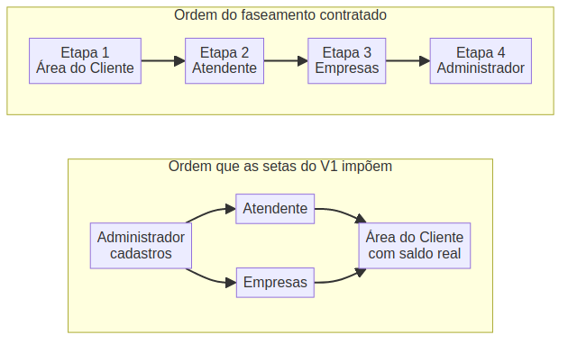

**As duas ordens são opostas, e foi isso que aconteceu.** O Administrador ficou na Etapa 4, e as Etapas 2 e 3 passaram a depender de *“carga técnica”* — trabalho manual não previsto e não precificado, para criar à mão os cadastros que o módulo da Etapa 4 criaria sozinho.

> **Ordene as etapas por dependência, não por entusiasmo do cliente.** Se o cliente quer ver a Área do Cliente primeiro, a resposta não é inverter a construção — é explicar, com o V1 na tela, que ela precisa dos cadastros para mostrar qualquer coisa que não seja zero.

##### Passo 8 — Desenhar o escopo negativo

Tudo que a dupla discutiu e decidiu **não** fazer vira caixa cinza — visível na apresentação, nomeada, e semente da lista de exclusões:

| Caixa cinza | Virou |
| --- | --- |
| Baixa do cupom no estabelecimento | `RE-05` |
| Qualquer pagamento, cashback ou saque | `RE-09`, `RE-10` |
| Identificação por QR code, cartão ou biometria | `RE-18` |
| Leitura automática de peso por balança | `RE-02` |
| Aplicativo móvel nativo e PWA instalável | `RE-01` |
| Autocadastro de empresas parceiras | `RE-03` |
| Gestão de usuários pelo próprio lojista | `RE-04` |

**As duas últimas linhas são a lição mais cara desta tabela.** A apresentação prometeu as duas; o orçamento não previa nenhuma. A divergência foi resolvida meses depois, contra a expectativa do cliente. **Uma caixa cinza no slide teria custado uma frase.**

##### Passo 9 — Transformar todo `[INFER]` em pergunta

Toda caixa tracejada vira pergunta da terceira reunião, **ordenada por quanto mexe no preço**:

| # | Pergunta ao cliente | Se a resposta for “sim”, muda |
| --- | --- | --- |
| 1 | Quem contrata e paga o provedor de mapas? | Custo recorrente e responsável |
| 2 | O atendente precisa cadastrar quem chega sem conta? | Escopo e preço da Etapa 2 |
| 3 | O sistema deve bloquear o resgate quando faltar saldo? | Regra de negócio da Etapa 1 |
| 4 | Quantos usuários simultâneos no pico? | Requisito de carga, hoje inexistente |
| 5 | A empresa parceira cadastra os próprios funcionários? | Existência de um módulo inteiro |

Confirmada, cada caixa vira `[DOC]` **antes da assinatura**. É a redução de risco mais barata do processo inteiro.

##### Passo 10 — Fechar o pacote de repasse

A *definition of ready* do `§1.4.2.10`, preenchida:

- V1 com atores, dependências internas e externas
- V2 para Usuário, Atendente, Empresa parceira e Administrador
- Fichas de tela: Registro de coleta, Resgate de cupom, Definição da campanha
- Tabela funcional `F1`–`F25` com Kano e tags de evidência
- Flags de pilha, com o ❌ da busca geográfica nomeado como Research Card
- Lista de caixas cinzas — 7 itens, sementes dos `RE`
- Perguntas em aberto, ordenadas por impacto no preço
- Versão do esboço registrada, igual à do orçamento a ser apresentado

##### O que esta sessão produziu

**Duas horas de trabalho, contra o que de fato aconteceu.** Dos **35 requisitos** da Proposta Formal, **10 não estavam no orçamento aceito** — 8 derivados por necessidade técnica (`[DER]`) e 2 definidos depois do aceite (`[DEF]`). Onde cada um teria aparecido:

| Requisito ausente do orçamento | Passo que o pega |
| --- | --- |
| `RF-ADM-01` — login do administrador | Passo 1, movimento 1 |
| `RF-ADM-07` — cadastro de ecopontos | Passo 1, movimento 3 |
| `RF-ADM-08` — contas de atendente | Passo 1, movimento 3 |
| `RF-ADM-09` — empresas parceiras e seus acessos | Passo 1, movimento 3 |
| `RF-ADM-10` — materiais recicláveis aceitos | Passo 1, movimento 3 |
| `RF-USR-03` — recuperação de senha | Passo 3 |
| `RF-USR-04` — logout | Passo 3 |
| `RF-USR-08` — bloqueio por saldo insuficiente | Passo 4 |
| `RF-ATD-06` — coletas registradas no turno | Passo 3 |
| `RF-EMP-05` — desativação de cupom próprio | Passo 3 |

**Dez de dez.** Somam-se a isso a pendência `C-04` (Passo 6), o faseamento invertido (Passo 7), as divergências `RE-03` e `RE-04` (Passo 8) e o Research Card da pilha (Passo 5).

**E o que ele não teria pego**, porque nenhum artefato pega tudo: `C-02`, o ano ausente na data de entrega, que é revisão de documento comercial (`1.5`); e `C-05`, a ausência de requisitos de carga, que é falha de elicitação (`1.3`). O Passo 9 no máximo *sugere* a segunda, na pergunta 4 — quem tinha que fazê-la era a segunda reunião.

> **A conclusão que interessa ao membro que vai executar isto:** nenhum dos dez achados exigiu conhecimento técnico avançado. Todos saíram de quatro perguntas mecânicas — *quem é o ator desta caixa?*, *o que precisa existir antes?*, *como essa jornada começa e termina?* e *o que esta tela exige do sistema?*. O esboço não é talento. É método aplicado por duas horas, antes do preço.

## 1.5 Orçamento e Montagem de Apresentação

**Observação: Mais detalhes sobre o modus operandi da parte comercial pode ser obtida no canal do notion ~/áreas de gestão/comercial/jornada do cliente e follow up.**

**(atualmente [03/09/2025], nesse link: https://app.notion.com/p/idejr/Jornada-do-Cliente-e-Follow-Up-2f377c1dd59b80b29d20e91b7e551f87)**

# 2. Lógica durante contrato: Normas e padrões organizacionais na confecção de projetos

## 2.1 Introdução: Visão geral

Após cessada a etapa pré-contratual com sucesso, isto é, após o contrato assinado e as equipes montadas, inicia-se a segunda etapa do ciclo de vida de um projeto: A etapa **durante** contrato. Para ilustrar o processo, deixamos abaixo um diagrama que tenta simbolizar esse período. Vale ressaltar que ele não necessariamente deve ser seguido na rigidez na qual foi desenhado. De modo que, por exemplo, é possível que ambas partes do processo se misturem. No entanto, aqui, deixamos separados para fins didáticos e para fins organizacionais ideias.

[figure not shown]

*Figura 2 — O período durante contrato. As duas faixas centrais correm em paralelo e se retroalimentam; a separação é didática, não sequencial.*

De maneira resumida, os capítulos seguintes cobrem, nesta ordem:

- **2.2 GitHub:** onde o trabalho é registrado, dividido, revisado e integrado;
- **2.3 Design de sistemas:** como os requisitos se transformam em experiência de uso antes de virarem código;
- **2.4 Diagramação Técnica e Arquitetural:** como os requisitos e o design se transformam em escopo rastreável e arquitetura, alimentando as Issues do capítulo 2.2;
- **2.5 Padrões e convenções de desenvolvimento:** como o código em si deve ser escrito.

## 2.2 GitHub: Guia sobre uso em projetos

Durante o desenvolvimento, **o GitHub não é apenas o local de armazenamento do código: é a ferramenta central de organização, rastreabilidade e revisão do projeto**. Ao olhar o repositório, qualquer membro identifica o que está sendo desenvolvido, quem responde por cada tarefa, o que já foi concluído e o que aguarda revisão. O histórico fica no repositório — não em grupos de mensagens, reuniões ou na memória dos envolvidos.

O fluxo adotado é:

**Issue → branch `feature/` → Desenvolvimento → Pull Request → Revisão → Merge em `develop` → Próxima Issue**

Issues, branches e Pull Requests não são burocracia: impedem que membros diferentes alterem o mesmo código ao mesmo tempo, ligam cada alteração a uma tarefa definida e garantem revisão antes que qualquer mudança entre na versão principal.

### 2.2.1 Criação e configuração inicial do repositório

O repositório central no GitHub é a fonte oficial do código durante todo o desenvolvimento. Quem o cria é o **líder ou responsável técnico do projeto**.

Configuração inicial:

- nome curto, descritivo e sem espaços;
- descrição que identifique brevemente o projeto;
- visibilidade definida conforme a natureza do projeto;
- `README.md` com o necessário para compreender e executar o projeto;
- `.gitignore` das tecnologias utilizadas, barrando arquivos gerados automaticamente ou sensíveis;
- branch `develop` criada a partir de `main`;
- `main` e `develop` protegidas: sem push direto e sem self-merge;
- todos os membros que participarão do desenvolvimento adicionados ao repositório.

**Regra geral: nenhum membro desenvolve uma versão paralela do projeto em um repositório próprio. O código oficial permanece centralizado no repositório definido pela equipe.**

Com o acesso, cada desenvolvedor clona o repositório e trabalha a partir dessa cópia local.

### 2.2.2 Issues: transformando o projeto em tarefas

O desenvolvimento é dividido em **Issues** — unidades de trabalho atribuíveis a um membro: uma funcionalidade, uma correção de bug, um ajuste ou uma tarefa técnica.

Uma boa Issue responde a três perguntas:

**O que precisa ser feito?**  
**Por que precisa ser feito?**  
**Quando a tarefa pode ser considerada concluída?**

Evite títulos vagos como **“Login”**. Prefira:

**“Implementar autenticação do usuário por e-mail e senha”**  
**“Corrigir redirecionamento após realização do login”**

A descrição deve bastar para que outro membro compreenda a tarefa sem reconstruir o contexto por mensagens privadas. Quando pertinente, adicione:

- **Assignee:** responsável pela execução;
- **Labels:** classificação da tarefa — bug, feature, frontend, backend;
- referências a outras Issues;
- imagens ou exemplos;
- critérios de aceite;
- informações técnicas relevantes.

**Regra geral: toda tarefa relevante tem um responsável claramente definido.**

A divisão em Issues se apoia na diagramação e decomposição técnica do capítulo 2.4.

### 2.2.3 Branches e modelo de ramificação

Nenhum desenvolvimento acontece diretamente em `main` ou `develop`. Toda tarefa vive em uma branch própria.

#### O que é Gitflow

**Gitflow** é o modelo de ramificação proposto por Vincent Driessen (2010). Ele organiza o repositório em branches com papéis fixos:

| Branch | Papel | Vida |
| --- | --- | --- |
| `main` | versão estável — o que está, ou pode ir, em produção | permanente |
| `develop` | integração do trabalho concluído, ainda não publicado | permanente |
| `feature/*` | uma funcionalidade em desenvolvimento; nasce de `develop` e volta para `develop` | temporária |
| `release/*` | preparação de uma versão: correções finais, sem novas funcionalidades; nasce de `develop`, vai para `main` e `develop` | temporária |
| `hotfix/*` | correção urgente em produção; nasce de `main`, vai para `main` e `develop` | temporária |

A ideia central do modelo: **`main` nunca recebe código diretamente de uma feature.** O que separa `main` de `develop` é risco validado — `develop` acumula o que foi integrado, `main` guarda apenas o que já foi aprovado como entregável.

#### O modelo adotado pela IDE

O Gitflow completo foi desenhado para produtos com releases versionadas e várias versões em manutenção simultânea. Nossos projetos não têm esse problema: duram um semestre, têm equipes pequenas e um único ambiente de publicação. Por isso adotamos uma versão reduzida do modelo:

- **`main`** — protegida. Recebe merge apenas de `develop`, em marcos de entrega, ou de `hotfix/*`.
- **`develop`** — branch de integração corrente. **Alvo padrão de todo Pull Request.**
- **`feature/<número-da-issue>-<slug>`** — uma Issue, uma branch. Nasce de `develop` e volta para `develop` via Pull Request.
- **`hotfix/<slug>`** — exceção para defeito em produção ou homologação. Nasce de `main` e é integrada a **`main` e `develop`**.
- **`release/*`** — apenas em projetos com versionamento formal. Na maioria dos nossos projetos, não é utilizada.

Antes de iniciar uma tarefa, atualize a branch de integração e crie a branch da Issue a partir dela:

```
git checkout develop
git pull origin develop
git checkout -b feature/23-login-usuario
```

Isso evita começar sobre uma versão desatualizada e mantém cada conjunto de alterações isolado até estar pronto para revisão.

O modelo, visualmente:

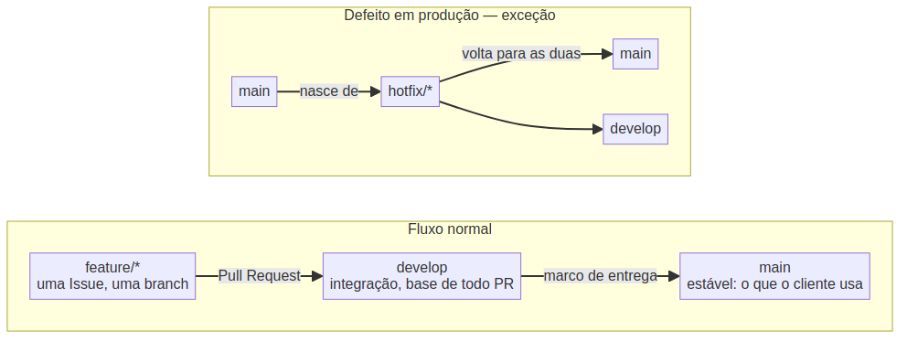

Os nomes das branches indicam claramente sua finalidade:

```
feature/23-login-usuario
feature/31-corrige-navbar-mobile
feature/47-dashboard-administrador
feature/52-integracao-api-pagamento
hotfix/corrige-envio-de-email
```

**Regra geral: uma branch corresponde a uma Issue, ou a um conjunto pequeno e coerente de alterações.**

Uma branch aberta por mais de uma sprint é falha de planejamento, não de programação: a Issue era grande demais e deveria ter sido fatiada. Branches longas, ou que acumulam funcionalidades não relacionadas, dificultam a revisão e multiplicam conflitos.

### 2.2.4 Commits

As mudanças são registradas em commits:

```
git add .
git commit -m "Mensagem do commit"
git push
```

A mensagem indica objetivamente o que foi alterado.

Evite:

```
"mudanças"
"teste"
"funcionando"
"coisas novas"
"commit final"
```

Prefira:

```
"Implementa validação do formulário de cadastro"
"Corrige responsividade da navbar"
"Adiciona endpoint de criação de usuário"
```

O histórico precisa ser compreensível depois: pela equipe atual e por quem assumir a manutenção do sistema.

### 2.2.5 Pull Requests

Concluído o trabalho na branch, **não integre as alterações por conta própria**: abra um **Pull Request (PR)**. O PR é a entrega da tarefa para revisão.

**A base do Pull Request é `develop`.** A única exceção é `hotfix/*`, cujo PR tem `main` como base e é replicado em `develop` após a integração.

O título resume a alteração; a descrição fornece contexto suficiente para o revisor.

Todo PR que resolve uma Issue é relacionado a ela:

```
Closes #23
Fixes #23
Resolves #23
```

Assim o GitHub associa a implementação à tarefa e fecha a Issue automaticamente após o merge.

Antes de abrir o PR, verifique se:

- a tarefa solicitada foi efetivamente concluída;
- não há arquivos desnecessários sendo enviados;
- nenhum segredo, token, senha ou arquivo sensível foi incluído;
- o projeto continua executando corretamente;
- as alterações correspondem ao objetivo da Issue.

### 2.2.6 Revisão de código

Todo Pull Request relevante passa **por revisão antes do merge**, sempre que houver outro membro tecnicamente apto disponível.

O revisor verifica não apenas se “o código funciona”, mas se:

- a implementação resolve a Issue proposta;
- não foram introduzidos comportamentos inesperados;
- o código está suficientemente claro;
- a solução segue a organização definida pelo projeto;
- não existem trechos desnecessariamente duplicados ou complexos;
- a alteração não compromete outras partes do sistema.

O GitHub permite comentar linhas específicas e oferece três formas de avaliação:

- **Comment:** dúvidas ou observações que não impedem a integração;
- **Approve:** a alteração pode ser integrada;
- **Request changes:** existem ajustes necessários antes da integração.

Um pedido de alteração não é reprovação do membro. **A revisão é controle de qualidade do projeto e transferência de conhecimento entre os desenvolvedores.**

### 2.2.7 Merge e encerramento da tarefa

Aprovado o Pull Request e resolvidos os conflitos, o código é integrado a `develop`. A `main` recebe `develop` nos marcos de entrega — quando a versão é publicada ou apresentada ao cliente.

As estratégias disponíveis — merge commit, squash and merge, rebase and merge — variam conforme o projeto. O essencial: **o merge é um ato consciente após a revisão**, não consequência automática do término da implementação.

Depois do merge:

1. verifique se a Issue correspondente foi encerrada;
2. exclua a branch de trabalho;
3. atualize sua cópia local de `develop`;
4. selecione a próxima Issue.

O ciclo reinicia.

### 2.2.8 Divisão de responsabilidades

Existem duas funções nesse fluxo.

**Responsável técnico/líder:**

1. estrutura o repositório;
2. auxilia na transformação do projeto em Issues;
3. distribui ou valida a distribuição das tarefas;
4. acompanha o desenvolvimento;
5. revisa Pull Requests ou garante que sejam revisados;
6. protege a integridade de `main` e `develop`.

**Desenvolvedor responsável pela Issue:**

1. compreende a tarefa;
2. atualiza sua cópia local de `develop`;
3. cria a branch `feature/`;
4. implementa a solução;
5. realiza commits coerentes;
6. envia a branch;
7. abre o Pull Request;
8. responde à revisão e realiza os ajustes solicitados.

Esses papéis são funções, não cargos fixos — em equipes pequenas o mesmo membro alterna entre eles. O que não pode faltar: para cada tarefa, está claro quem executa e quem valida.

#### Resumo

O procedimento padrão:

**1. Criar Issue → 2. Atribuir responsável → 3. Atualizar `develop` → 4. Criar branch `feature/` → 5. Desenvolver → 6. Commitar → 7. Abrir PR com base em `develop` → 8. Revisar → 9. Corrigir, se necessário → 10. Aprovar → 11. Fazer merge em `develop` → 12. Excluir branch → 13. Iniciar próxima Issue.**

**`main` recebe `develop` nos marcos de entrega. Defeito em produção é a única exceção: `hotfix/` nasce de `main` e volta para `main` e `develop`.**

## 2.3 Design de sistemas: Práticas essenciais e regras gerais no design de sistemas e sites

Encerrada a etapa pré-contratual, a equipe já dispõe de uma visão consolidada **do problema a ser resolvido e dos requisitos que o sistema deverá atender**. Saber *o que* precisa ser construído, entretanto, não determina *como* o usuário irá interagir com aquilo que será construído.

É exatamente nessa lacuna que a etapa de design se instala.

Seu objetivo é converter requisitos, funcionalidades e fluxos abstratos em uma representação concreta e discutível da experiência que será oferecida ao usuário — **antes** que uma quantidade significativa de horas de desenvolvimento seja comprometida com ela.

Na prática, isso significa abandonar o ciclo mais caro que uma equipe pode adotar:

**imaginar tela → programar tela → mostrar ao cliente → descobrir que estava errada → refazer.**

E substituí-lo por:

**pesquisar → esboçar → validar → aprovar → implementar.**

A diferença entre os dois não é de estilo, e sim de custo. No primeiro, o erro é descoberto em código já escrito, testado e integrado; no segundo, ele é descoberto em um esboço que pode ser refeito em minutos. **Corrigir uma decisão de experiência no papel é ordens de grandeza mais barato do que corrigi-la em produção.**

Esse segundo fluxo já aparece conceitualmente no diagrama do *capítulo 2.1*, que posiciona pesquisa, esboço, aprovação do cliente e implementação como etapas encadeadas do processo, sempre acompanhadas de comunicação com o cliente.

> **REGRA GERAL DO CAPÍTULO —** Nenhuma tela relevante deve entrar em desenvolvimento sem ter sido, antes, esboçada, revisada internamente e validada com o cliente.

### 2.3.1 Design não é apenas estética

Um equívoco recorrente é reduzir design à escolha de cores, fontes e à produção de telas visualmente agradáveis. Esses aspectos importam, mas representam a camada mais superficial — e a última — do problema.

Antes de perguntar:

**“Qual cor esse botão deve possuir?”**

é obrigatório perguntar:

**“Esse botão deveria existir?”** **“O usuário saberá o que acontece quando clicar nele?”** **“Esta é a ação mais importante desta tela?”** **“O usuário consegue chegar até aqui sem se perder?”**

Portanto, o design deve tratar, nesta ordem de prioridade:

1. os **objetivos do usuário** — o que ele precisa concluir;
2. os **fluxos principais de utilização** — o caminho até concluir;
3. a **organização das informações** — o que aparece, agrupado como;
4. a **hierarquia das ações** — o que se destaca e o que recua;
5. a **consistência entre telas** — o que se repete e como;
6. a **facilidade de compreensão** — o custo cognitivo de cada passo;
7. e, somente depois de tudo isso, a **identidade visual**.

O levantamento de requisitos descrito no *capítulo 1.3* já persegue essa direção ao investigar aquilo que tornaria o sistema **intuitivo, prazeroso ou surpreendente para o usuário**, tratando a experiência de uso como fonte legítima de valor agregado — e não como acabamento opcional.

> **REGRA —** Estética é consequência de estrutura, nunca substituta dela. Uma tela bonita que esconde a ação principal é uma tela mal projetada.

### 2.3.2 Caso prático IDE: o aplicativo dos motoboys

Um episódio ocorrido em um projeto anterior da IDE ilustra com precisão por que compreender o contexto do usuário precede qualquer decisão de interface.

Na ocasião, um cliente havia solicitado o desenvolvimento de um **aplicativo móvel a ser utilizado por motoboys durante a rotina de entregas**. Nos primeiros encontros, a equipe discutia telas e funcionalidades de maneira relativamente abstrata, concentrada sobretudo em *quais informações* deveriam estar presentes no aplicativo.

No meio dessa discussão, um dos membros levantou a pergunta que ainda não havia sido feita: **em quais condições reais aquele aplicativo seria efetivamente utilizado?**

A resposta reorganizou o problema inteiro. O usuário não seria alguém sentado com calma diante de um computador. Seria um profissional em alta mobilidade, consultando o celular em intervalos de poucos segundos entre etapas de uma entrega, sob pressão de tempo, frequentemente sob sol forte ou chuva, com uma das mãos ocupada e, em muitos casos, **usando luvas**.

Desse simples exercício de deslocamento de perspectiva decorreu uma conclusão de projeto concreta: **a interface adequada àquele aplicativo deveria privilegiar informações resumidas, ações evidentes e alvos de toque grandes e tolerantes a imprecisão.**

Note que cada uma dessas decisões é rastreável a uma condição de uso:

| Condição real de uso | Decisão de design decorrente |
| --- | --- |
| Uso em movimento, poucos segundos por consulta | Informação resumida; uma ação principal por tela |
| Mãos ocupadas, uso de luvas | Alvos de toque ampliados e bem espaçados |
| Pressão de tempo | Redução de passos; confirmação apenas em ações destrutivas |
| Ambiente externo, luminosidade variável | Contraste elevado; dependência mínima de cores sutis |

Um botão pequeno, perfeitamente funcional em um aplicativo usado no sofá de casa, torna-se um obstáculo operacional nesse cenário. Do mesmo modo, uma tela densa de informações — ainda que visualmente sofisticada — exige atenção que o usuário simplesmente não tem disponível para dedicar.

O ponto central do caso, contudo, **não** é estabelecer que todo aplicativo destinado a entregadores deva ter exatamente essas características. A lição é mais ampla e mais reutilizável: **uma boa decisão de design depende de compreender não apenas quem é o usuário, mas onde, quando, sob qual pressão e com quais limitações físicas ele utilizará o produto.**

O raciocínio se resume à seguinte equação:

**Usuário + objetivo + contexto de uso → decisões de design**

Antes de definir qualquer interface, portanto, a equipe deve investigar:

- O usuário estará **sentado ou em movimento** durante sua rotina?
- Usará o sistema por **longos períodos** ou em **interações de poucos segundos**?
- Estará em ambiente **silencioso e controlado** ou **ruidoso e cheio de distrações**?
- Utilizará **mouse e teclado, touchscreen, telas pequenas** ou **equipamentos de proteção**?
- Terá tempo para **ler textos extensos** ou precisará **reconhecer informações imediatamente**?
- A conexão de rede será **estável**, **intermitente** ou **inexistente** em parte do uso?

Essas perguntas convertem decisões aparentemente subjetivas em decisões fundamentadas e defensáveis diante do cliente. No caso dos motoboys, **botões maiores e interface simplificada não foram preferência estética da equipe; foram consequência direta e argumentável do contexto de utilização.**

> **REGRA —** Toda decisão de interface deve ser justificável por um requisito ou por uma condição de uso documentada. “Achamos que fica melhor assim” não é justificativa técnica.

### 2.3.3 Antes de desenhar: entender o problema

Como o caso anterior demonstra, conhecer as funcionalidades do sistema é insuficiente. Antes de produzir qualquer interface, a equipe precisa dominar **o usuário** e **o contexto** em que essas funcionalidades serão exercidas.

Essa matéria-prima vem primordialmente do **levantamento de requisitos do *capítulo 1.3***. Quando ela não existir com o detalhamento necessário, a resposta correta é **voltar ao cliente e perguntar** — nunca preencher a lacuna com suposição da equipe.

> **REGRA —** Uma tela não existe porque “sistemas costumam ter essa tela”. Todo elemento relevante deve ser rastreável a um requisito, fluxo ou necessidade identificada. O que não for rastreável deve ser removido ou justificado explicitamente.

### 2.3.4 Pesquisa fundamentada

Antes do esboço, execute uma **pesquisa curta, orientada ao problema e com prazo definido**. A intenção não é copiar concorrentes, e sim observar como problemas semelhantes já foram resolvidos — e por quê funcionaram.

Fontes recomendadas:

- sistemas do mesmo segmento de mercado;
- produtos que executem funcionalidades análogas, ainda que de outro setor;
- padrões de interface recorrentes e já consolidados;
- referências apresentadas pelo próprio cliente;
- experiências positivas e negativas relatadas por usuários de sistemas existentes.

Ao analisar uma referência, a pergunta correta nunca é:

**“Isso é bonito?”**

E sim:

**“Por que essa solução funciona?”** **“Que problema específico ela resolve?”** **“Ela seria adequada aos usuários e ao contexto do nosso projeto?”**

Vale registrar também os **antipadrões** encontrados: soluções que a equipe decidiu deliberadamente *não* adotar, com o motivo. Esse registro evita que a mesma ideia descartada retorne à discussão três semanas depois.

> **Entregável esperado:** um conjunto enxuto de referências comentadas — o que foi observado, por que funciona e o que será (ou não) aproveitado — capaz de orientar objetivamente o esboço.

### 2.3.5 Esboço do design

Concluída a pesquisa, produza uma representação visual do sistema antes de qualquer implementação definitiva. A ferramenta pode variar conforme o porte do projeto (Figma, Penpot ou mesmo papel em rascunhos iniciais); o que não varia é a exigência de que equipe e cliente **enxerguem a proposta antes de o desenvolvimento avançar**.

Trabalhe em níveis crescentes de fidelidade, e não em um salto único:

1. **Baixa fidelidade (wireframe):** blocos, rótulos e posições. Valida estrutura, densidade e navegação. Deve ser descartável sem dor.
2. **Alta fidelidade:** aplicação da identidade visual, tipografia, cor e componentes reais.
3. **Protótipo navegável:** telas conectadas, percorríveis pelo fluxo principal. É o formato mais eficaz para validação com o cliente, porque expõe o percurso e não apenas o quadro.

Nas etapas iniciais, o esboço **não precisa de acabamento**. O objetivo é validar primeiro:

- disposição das informações;
- sequência entre telas;
- funcionalidades presentes;
- ações disponíveis ao usuário;
- navegação e possibilidades de retorno;
- hierarquia dos elementos.

> **REGRA —** Valide estrutura e fluxo primeiro; refine aparência depois. Polir pixels de uma tela cuja estrutura ainda pode mudar é desperdício de horas, e horas são o recurso mais escasso de uma sprint.

Lembre-se de que o *capítulo 2.4* consome diretamente este material: os fluxos aqui esboçados alimentam **User Stories** e **User Flows**, que por sua vez alimentam as **Issues** do *capítulo 2.2*. Um esboço vago não produz apenas uma tela ruim — produz escopo impreciso rio abaixo.

### 2.3.6 Consistência

Elementos com a mesma função **devem** ter aparência e comportamento equivalentes em todo o produto. Se os botões de ação primária seguem um padrão, não há motivo para que cada tela reinvente uma solução própria.

A consistência deve abranger, quando aplicável:

- cores e seus significados (o que é primário, o que é destrutivo, o que é neutro);
- tipografia e escala de tamanhos;
- botões e suas variantes;
- campos de formulário e validação;
- espaçamentos e ritmo vertical;
- ícones e sua biblioteca de origem;
- menus e padrões de navegação;
- mensagens ao usuário e tom de escrita;
- componentes compartilhados.

O benefício não é estético, é cognitivo. **Cada padrão novo que o usuário precisa aprender é um custo cobrado dele.** Consistência reduz esse custo: o que foi aprendido em uma tela permanece válido nas demais.

> **REGRA —** Divergir de um padrão já estabelecido no projeto exige justificativa registrada. Na ausência de justificativa, o padrão vigente prevalece.

### 2.3.7 Design System e biblioteca de componentes

*(Como transformar a consistência de intenção em mecanismo.)*

Consistência descrita em prosa se perde; consistência **codificada em componentes** se sustenta sozinha. Em projetos com equipe enxuta, membros majoritariamente em semestres iniciais e rotatividade natural entre semestres, um design system modesto e bem definido é o que impede que o produto se fragmente à medida que novas pessoas entram.

Um design system suficiente para o porte dos projetos da IDE tem três camadas:

**1. Tokens — a fonte única da verdade visual.** Cor, tipografia, escala de espaçamento, raio de borda, sombra e breakpoints definidos **uma única vez**. No stack padrão da IDE (Next.js, TypeScript e Tailwind CSS), esses valores vivem na configuração de tema do Tailwind, e não espalhados como literais dentro dos componentes.

> **REGRA —** Nenhum valor de cor ou espaçamento solto no código. Um `#3B7DD8` escrito no meio de um componente é dívida técnica; um token `primary` é decisão de projeto.

**2. Componentes — as peças reutilizáveis.** Botão, campo de texto, seleção, modal, tabela, alerta, card, navegação. Cada componente deve ser desenhado **com todas as suas variantes e estados**, não apenas em sua forma ideal:

`padrão · hover · foco · pressionado · desabilitado · carregando · erro`

**3. Padrões — as composições recorrentes.** Layout de formulário, tabela com filtros, cabeçalho de página, estrutura de listagem, disposição de ações destrutivas. São decisões tomadas uma vez e reaplicadas.

**Alinhamento entre design e código.** A biblioteca no Figma e os componentes implementados devem ser espelhos um do outro. Quando divergem, o design deixa de ser referência confiável e volta a ser ilustração — e a equipe retorna, sem perceber, ao ciclo caro descrito na abertura deste capítulo.

**Sobre adotar bibliotecas prontas.** Reaproveitar uma biblioteca de componentes acelera consideravelmente o trabalho, mas **qualquer tecnologia fora do stack padrão exige Research Card aprovado antes da adoção**. Introduzir uma dependência nova no meio de uma sprint de oito dias úteis efetivos costuma custar mais do que economiza; a decisão pertence ao início do projeto, não ao meio.

> **Entregável esperado:** um arquivo de tokens e um inventário de componentes com seus estados, acordado entre design e desenvolvimento **antes** do início da implementação das telas.

### 2.3.8 Hierarquia visual e prioridade

A interface tem a obrigação de comunicar o que é mais importante. Nem todos os elementos de uma tela devem competir igualmente por atenção: a ação principal recebe destaque proporcional à sua relevância, enquanto informações secundárias assumem peso visual menor.

> **REGRA —** Se tudo possui destaque, nada possui destaque.

Instrumentos de hierarquia à disposição da equipe: **tamanho, peso tipográfico, cor e contraste, espaço em branco, posição e agrupamento**. Espaço em branco não é desperdício de tela — é o recurso que separa blocos e torna a leitura possível.

Como critério prático de aprovação, ao olhar uma tela por **cinco segundos**, o usuário deve conseguir responder:

1. **onde estou;**
2. **o que estou vendo;**
3. **qual é a ação principal que posso executar;**
4. **como continuo ou como volto.**

Se qualquer uma dessas quatro respostas exigir esforço, a hierarquia está errada — mesmo que a tela esteja visualmente agradável.

### 2.3.9 Estados e feedback ao usuário

O design não pode representar apenas o cenário ideal da aplicação. **O caminho feliz é a minoria dos casos que o usuário encontrará ao longo do uso real.**

Para cada fluxo relevante, projete explicitamente:

- **carregamento** (e o que ocorre se ele demorar mais que o esperado);
- **ausência de dados** (estado vazio);
- **operação concluída com sucesso**;
- **erro do sistema**;
- **informação inválida fornecida pelo usuário**;
- **ação indisponível** (e o motivo da indisponibilidade);
- **confirmação de operações destrutivas ou irreversíveis**;
- **ausência de permissão** para o perfil de usuário em questão.

Não basta desenhar uma tabela repleta de dados: é preciso definir **o que aparece quando ainda não existe dado algum**. Um bom estado vazio não se limita a informar que a lista está vazia — ele **ensina a próxima ação** (“Nenhum pedido cadastrado. Cadastre o primeiro pedido.”).

Da mesma forma, não basta definir um botão “Salvar”. O usuário precisa perceber, sem ambiguidade, que a operação foi concluída — ou que falhou, e por quê.

**Microcopy é design.** O texto da interface é parte do projeto, não preenchimento de última hora:

- Rótulos de botão descrevem a **ação**, não a abstração: *“Salvar alterações”* em vez de *“OK”*.
- Mensagens de erro dizem **o que aconteceu e como resolver**: *“A data de entrega não pode ser anterior à data do pedido.”* em vez de *“Erro de validação.”*
- Nunca exponha ao usuário final linguagem interna do sistema (códigos de exceção, nomes de tabela, mensagens de framework).

> **REGRA —** Toda ação do usuário produz uma resposta perceptível do sistema em até um segundo. Silêncio da interface é interpretado como falha, e leva o usuário a repetir a ação.

### 2.3.10 Responsividade e diferentes dispositivos

Quando o sistema tiver uso Web, o comportamento em diferentes tamanhos de tela deve ser decidido **durante o design**, e não descoberto depois que a versão desktop já estiver implementada.

Não é necessário que as telas sejam idênticas entre computador e celular. O que é obrigatório é que **as funcionalidades previstas nos requisitos permaneçam acessíveis e compreensíveis em todos os contextos de uso definidos**.

Orientações práticas:

- Defina **qual é o contexto dominante** antes de esboçar. Um sistema operado majoritariamente em campo se projeta a partir da tela pequena; um painel administrativo operado em escritório, a partir da tela grande.
- Trate a redução de tela como **reorganização de prioridade**, não como simples compressão: o que é secundário recolhe, o que é essencial permanece.
- Verifique **tabelas, formulários longos e ações em massa** — são os pontos que rompem primeiro em telas estreitas.
- Considere o dedo, não o cursor: em telas de toque, alvos pequenos e vizinhos próximos produzem erro de acionamento.

A preocupação com contexto e dispositivo já é levantada no *capítulo 1.3*, que investiga explicitamente uso em dispositivos móveis e em condições operacionais adversas. **Aquela informação existe para ser usada aqui.**

### 2.3.11 Acessibilidade (A11y): padrão mínimo, não diferencial

Acessibilidade é frequentemente tratada como refinamento opcional. Ela não é: é **critério de qualidade**, e em diversos contextos — especialmente clientes públicos, instituições de ensino e organizações sujeitas à Lei Brasileira de Inclusão (Lei nº 13.146/2015) — é também **exigência legal**. A referência técnica internacionalmente adotada é a **WCAG 2.2, nível AA**.

**O argumento decisivo, porém, é conceitual.** Limitações se apresentam em três formas:

- **permanente** — o usuário cego;
- **temporária** — o usuário com o braço imobilizado;
- **situacional** — **o motoboy de luvas, em movimento, sob sol forte.**

As três se beneficiam exatamente das mesmas soluções: alvos maiores, contraste alto, informação resumida, ação evidente. Isto é, **o caso do aplicativo dos motoboys descrito no item 2.3.2 é, em essência, um problema de acessibilidade situacional.** Projetar para o extremo melhora a experiência de todos os usuários — nunca apenas a de um grupo específico.

#### Checklist mínimo de acessibilidade

Aplicável a **todo** projeto da IDE, independentemente do cliente:

1. **Contraste.** Mínimo de **4,5:1** para texto normal e **3:1** para texto grande, ícones essenciais e bordas de componentes interativos.
2. **Alvos de toque.** Mínimo de **24×24 px**; em contextos móveis ou de mobilidade, use **44×44 px** como alvo real, com espaçamento suficiente entre elementos vizinhos.
3. **Cor nunca é o único portador de significado.** Um campo inválido é sinalizado por cor **e** ícone **e** texto — daltonismo e telas sob luz solar anulam a cor sozinha.
4. **Operação por teclado.** Todo fluxo essencial deve ser percorrível por teclado (Tab, Enter, Esc), com **foco visível**. Remover o indicador de foco sem oferecer substituto é defeito, não escolha estética.
5. **Rótulos explícitos.** Todo campo possui rótulo associado; todo botão apenas com ícone possui nome acessível. *Placeholder não é rótulo* — ele desaparece justamente quando o usuário mais precisa dele.
6. **Textos alternativos.** Imagens informativas descrevem seu conteúdo; imagens decorativas são marcadas como tais.
7. **Estrutura semântica.** Hierarquia real de títulos e uso correto de elementos de formulário e navegação — jamais fonte grande simulando título.
8. **Tipografia legível.** Corpo de texto a partir de 16 px, com suporte a ampliação até 200% sem perda de conteúdo ou funcionalidade.
9. **Erros recuperáveis.** Mensagem textual, posicionada junto ao campo, indicando **como corrigir**.
10. **Movimento moderado.** Evite animações longas ou intensas e respeite a preferência de redução de movimento do sistema operacional.

> **REGRA —** Acessibilidade é decidida no design, não corrigida no fim do projeto. Refazer contraste, estrutura de títulos e navegação por teclado após a implementação custa múltiplas vezes o esforço de acertá-los no esboço.

> **REGRA —** Não registre “contraste verificado” sem ter medido. Use verificador de contraste na ferramenta de design e auditoria automatizada no navegador. **Verificação sem medição é suposição documentada.**

### 2.3.12 Heurísticas de Nielsen: instrumento de revisão

Antes de submeter qualquer proposta à equipe ou ao cliente, submeta-a às **10 heurísticas de usabilidade de Jakob Nielsen**. Elas funcionam como instrumento de revisão de baixo custo e alto retorno: qualquer membro da equipe, mesmo sem formação em design, consegue aplicá-las e apontar problemas concretos.

| # | Heurística | Pergunta de verificação |
| --- | --- | --- |
| 1 | Visibilidade do status do sistema | O usuário sabe, a todo momento, o que o sistema está fazendo? |
| 2 | Correspondência com o mundo real | A linguagem é a do usuário e do negócio, ou a do banco de dados? |
| 3 | Controle e liberdade do usuário | Existe saída clara, cancelamento e desfazer nas ações relevantes? |
| 4 | Consistência e padrões | O mesmo elemento significa a mesma coisa em todas as telas? |
| 5 | Prevenção de erros | O erro é evitado na origem, ou apenas informado depois? |
| 6 | Reconhecer em vez de lembrar | O usuário precisa memorizar algo de uma tela para usar na seguinte? |
| 7 | Flexibilidade e eficiência | O usuário frequente tem atalho, ou repete o caminho longo sempre? |
| 8 | Estética e design minimalista | Existe informação na tela que não serve à tarefa atual? |
| 9 | Recuperação de erros | A mensagem explica o problema e indica o caminho de solução? |
| 10 | Ajuda e documentação | Onde o uso é inevitavelmente complexo, existe orientação acessível no contexto? |

**Como aplicar na prática:** dois membros percorrem, separadamente, os fluxos principais do protótipo — cerca de 15 minutos por fluxo — anotando toda violação encontrada e classificando-a como **alta, média ou baixa** severidade. Em seguida, comparam os achados. A revisão independente antes da comparação é deliberada: ela evita que a primeira opinião expressa contamine a segunda.

**Os achados de alta severidade são corrigidos antes da apresentação ao cliente.** Os demais são registrados como Issues, conforme o *capítulo 2.2*, para tratamento durante a implementação.

### 2.3.13 Aprovação interna antes da apresentação ao cliente

Nenhuma solução visual vai ao cliente sem revisão interna da equipe. Verifique obrigatoriamente:

- se **todos os requisitos essenciais** estão representados;
- se **não existem fluxos sem saída** (telas de onde não se avança nem se retorna);
- se as telas são **coerentes entre si** e com o design system definido;
- se as **ações principais estão evidentes** em cada tela;
- se os **estados não-ideais** (item 2.3.9) foram contemplados nos fluxos críticos;
- se o **checklist de acessibilidade** (item 2.3.11) foi percorrido;
- se a proposta é **tecnicamente viável dentro do stack padrão e do prazo contratado**;
- se **nenhuma funcionalidade está sendo implicitamente prometida** sem constar do escopo.

Merece atenção específica o critério de viabilidade técnica. **Toda solução que dependa de tecnologia fora do stack padrão da IDE — incluindo aplicativos móveis nativos e recursos específicos de PWA — exige Research Card aprovado antes de ser apresentada ao cliente.** Um esboço aprovado pelo cliente cria expectativa contratual; se aquilo que foi aprovado não puder ser construído com o que a equipe domina, o problema não foi resolvido, apenas transferido para o desenvolvimento — onde é mais caro e mais visível.

> **REGRA —** Design e desenvolvimento não operam como departamentos isolados. Quem vai implementar a tela participa da revisão que a aprova.

> **Entregável esperado:** protótipo revisado, com pendências de alta severidade resolvidas e viabilidade técnica confirmada, pronto para apresentação.

### 2.3.14 Aprovação do cliente

Com a proposta suficientemente madura, apresente-a ao cliente para validação. Nesse momento, evite a pergunta que não produz informação aproveitável:

**“Gostou?”**

Ela convida o cliente a opinar sobre gosto pessoal — exatamente o terreno em que ele não é a autoridade e a equipe não deveria estar discutindo. Pergunte, em vez disso:

**“Esse fluxo corresponde ao funcionamento esperado na sua operação?”** **“Falta alguma informação necessária para executar esta tarefa?”** **“Seus usuários realizariam essas ações nessa ordem?”** **“Existe alguma regra de negócio que não está representada aqui?”** **“O que costuma dar errado nesse processo hoje, e como o sistema deveria reagir?”**

Sempre que possível, conduza a validação sobre o **protótipo navegável**, percorrendo tarefas reais — “mostre como você registraria uma entrega atrasada” — em vez de apresentar telas isoladas. **Observar o cliente tentando executar a tarefa revela mais do que qualquer resposta verbal a uma pergunta direta.**

O objetivo da aprovação não é aferir preferência estética. É confirmar que **a solução representada corresponde ao processo real e às necessidades do cliente**.

> **REGRA —** Todo feedback relevante é registrado por escrito, com data e responsável, e o aceite do design é formalizado. Decisão que existe apenas em mensagem de aplicativo ou na memória de quem participou da reunião não existe.

### 2.3.15 Implementação e ciclo de revisão

Aprovada uma tela ou fluxo, sua implementação pode ser iniciada — e as Issues correspondentes, abertas conforme o *capítulo 2.2*.

A aprovação do design, contudo, não congela o projeto. Durante o desenvolvimento, limitações técnicas, informações novas ou detalhes não percebidos anteriormente podem exigir revisão. O fluxo, portanto, é **iterativo**:

**Pesquisa → Esboço → Validação → Implementação → Verificação → Ajuste, quando necessário.**

Ao final da implementação, execute uma **verificação de conformidade**: a tela construída corresponde ao que foi aprovado? Os estados não-ideais foram implementados, ou apenas o caminho feliz? O checklist de acessibilidade continua satisfeito no produto real, e não apenas no arquivo de design?

Essa flexibilidade, entretanto, não autoriza alteração arbitrária.

> **REGRA —** Toda mudança que afete requisitos, escopo ou decisões já validadas é comunicada à equipe e, quando pertinente, ao cliente — **antes** de ser implementada. Divergência silenciosa entre o design aprovado e o sistema entregue é falha de processo, não detalhe de execução.

### 2.3.16 Regra geral

Em síntese, para cada parte relevante da experiência do usuário, o percurso é:

**1. Entender o requisito → 2. Pesquisar referências → 3. Esboçar o fluxo → 4. Produzir o design → 5. Revisar internamente → 6. Validar com o cliente → 7. Implementar → 8. Verificar e iterar.**

#### Checklist de fechamento da etapa de design

Nenhum fluxo é considerado pronto para desenvolvimento enquanto todas as linhas abaixo não estiverem satisfeitas:

| ✔ | Critério | Referência |
| --- | --- | --- |
| ☐ | Cada elemento é rastreável a um requisito ou condição de uso | 2.3.1 · 2.3.3 |
| ☐ | Contexto real de uso investigado e documentado | 2.3.2 |
| ☐ | Referências pesquisadas e conclusões registradas | 2.3.4 |
| ☐ | Estrutura e fluxo validados antes do refino visual | 2.3.5 |
| ☐ | Componentes e tokens reutilizados, sem valores soltos | 2.3.6 · 2.3.7 |
| ☐ | Ação principal evidente em cada tela | 2.3.8 |
| ☐ | Estados de carregamento, vazio, erro e sucesso projetados | 2.3.9 |
| ☐ | Comportamento definido para todos os tamanhos de tela previstos | 2.3.10 |
| ☐ | Checklist de acessibilidade percorrido e **medido** | 2.3.11 |
| ☐ | Revisão heurística feita e achados de alta severidade resolvidos | 2.3.12 |
| ☐ | Viabilidade técnica confirmada dentro do stack padrão | 2.3.13 |
| ☐ | Validação e aceite do cliente registrados por escrito | 2.3.14 |

O propósito desta etapa não é tornar todos os projetos da IDE visualmente iguais. É garantir que **toda decisão sobre a experiência do usuário seja intencional, justificável e validada — antes de ser convertida em código.**

## 2.4 Diagramação Técnica e Arquitetural: Orquestrando o desenvolvimento do projeto

> **Status:** onde este texto propõe algo que **ainda não é prática consolidada da IDE**, isso está dito explicitamente no corpo da seção.

Os capítulos anteriores estabeleceram **onde o trabalho é registrado** (*capítulo 2.2*) e **como a experiência do usuário é definida** (*capítulo 2.3*). Falta ainda o elo que converte requisitos levantados em **escopo rastreável e arquitetura implementável** — isto é, naquilo que efetivamente vira uma Issue atribuída a uma pessoa.

É esse o papel da diagramação técnica.

O ponto de partida é reconhecer o que ela **não** é. Diagramar não é produzir anexos bonitos para uma pasta que ninguém abre depois. Um diagrama que não muda uma decisão, não resolve uma discussão ou não economiza uma reescrita é custo puro — e este capítulo trata explicitamente de quando **não** desenhar (*seção “Qual diagrama, quando”* e *capítulo 2.4.9*).

Diagramar, na IDE, resolve quatro problemas concretos e verificáveis.

### Por que diagramar: as quatro funções

**1. Alinhar cliente e equipe sobre a mesma coisa.** Texto corrido admite leituras divergentes; um diagrama, muito menos. Quando o cliente lê “o sistema terá um painel administrativo” e a equipe lê a mesma frase, as duas leituras coincidem por sorte. Um mapa que ambos olham ao mesmo tempo torna a divergência visível **antes** de virar retrabalho.

**2. Prevenir gargalos arquiteturais.** O custo de uma decisão de arquitetura errada cresce com o tempo em que ela permanece invisível. Descobrir na Sprint 6 que dois módulos disputam a mesma tabela, ou que uma funcionalidade depende de um serviço que ninguém provisionou, é caro. Descobrir isso em um diagrama desenhado na Sprint 0 é barato. **A mesma lógica de custo que justifica o esboço de design no *capítulo 2.3* justifica o diagrama de arquitetura aqui.**

**3. Reduzir o custo de entrada de um novo membro.** Esta é a função mais subestimada e, para a IDE, a mais importante. A *Motivação* deste Manual é explícita: a empresa opera com um quadro majoritariamente composto por **estudantes em semestres iniciais** e o SDLC existe como **mecanismo de transferência de conhecimento e proteção contra a perda de capital intelectual decorrente da alta rotatividade**.

Um diagrama é conhecimento que sobrevive à saída de quem o desenhou. Uma explicação dada em uma chamada de voz não sobrevive nem à semana seguinte.

**4. Garantir rastreabilidade até a Issue.** Todo trabalho executado precisa ser rastreável até um requisito acordado com o cliente. Os artefatos deste capítulo são os elos dessa corrente: **um requisito que não vira Issue não é entregue, e uma Issue que não rastreia até um requisito é aumento silencioso de escopo.**

> **REGRA GERAL DO CAPÍTULO —** Todo diagrama produzido na IDE deve responder a uma pergunta que alguém realmente fez. Diagrama que não responde pergunta nenhuma não deve ser desenhado; diagrama que responde a uma pergunta e está desatualizado é pior do que diagrama nenhum, porque mente com aparência de autoridade.

### Do esboço ao escopo: o que muda quando o contrato é assinado

O *capítulo 1.4.2* já introduziu um artefato visual na fase pré-contratual: o **esboço de projeto**, o “diagrama de caixinhas”. É legítimo perguntar por que a IDE desenha duas vezes. A resposta é que os dois artefatos têm **naturezas opostas**, e confundi-los é uma fonte concreta de prejuízo.

|  | **Esboço de projeto (*1.4.2*)** | **Diagramação técnica (*2.4*)** |
| --- | --- | --- |
| **Quando** | Antes do preço, antes da assinatura | Depois da assinatura, antes do código |
| **Objetivo** | Tornar a proposta compreensível e estimável | Tornar a execução inequívoca e rastreável |
| **Precisão exigida** | Deliberadamente baixa — vale a ideia, não a formalidade | Alta — é a base do que será construído e revisado |
| **Valor contratual** | **Nenhum.** Ilustra o escopo, não o define | A MRF é o registro operacional do escopo contratado |
| **Unidade** | Módulo (a “caixinha”) | Requisito, história, tela, classe, mensagem |
| **Quem produz** | Dupla Comercial × Projetos | Departamento de Projetos |
| **Erro típico** | Detalhar demais e queimar horas não pagas | Detalhar de menos e mandar para a sprint algo ambíguo |

**A transição entre os dois é o momento em que a postura da equipe inverte.** Na fase pré-contratual, o excesso de detalhe é desperdício. Na fase de execução, a falta de detalhe é defeito. Cada “caixinha” do esboço deve reaparecer aqui decomposta em requisitos com ID, e nenhum requisito deve aparecer aqui sem ter existido, de alguma forma, lá — se aparecer, é escopo novo e segue o rito contratual de aditivo, não o rito da sprint.

### A cadeia de artefatos

O encadeamento entre os artefatos não é sugestão de ordem: é o que garante que cada linha de código escrita rastreie até algo que o cliente aceitou pagar.

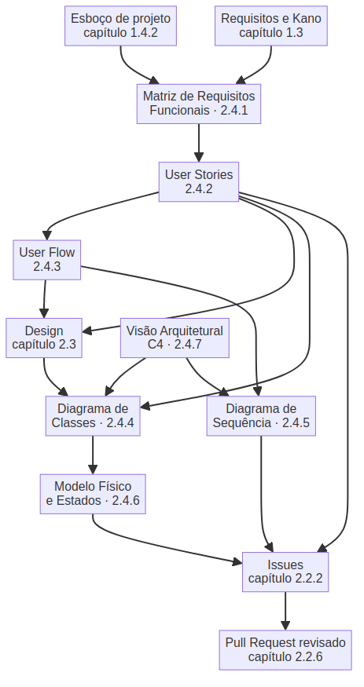

Em forma linear, para consulta rápida:

**Requisitos (*1.3*) → Matriz de Requisitos Funcionais (*2.4.1*) → User Stories (*2.4.2*) → User Flow (*2.4.3*) e Design (*2.3*) → Diagrama de Classes (*2.4.4*) → Issues (*2.2.2*)**

Os artefatos das seções 2.4.5 a 2.4.7 **não são uma quinta etapa dessa fila** — são aprofundamentos acionados por necessidade. A seção seguinte define exatamente quando cada um é acionado.

### Qual diagrama, quando

Esta é a tabela mais importante do capítulo. Um erro recorrente de equipes iniciantes é tratar diagramação como um pacote fechado: desenha-se tudo, para todo projeto, e o resultado é um conjunto de documentos que envelhece na primeira semana. **Diagramação é uma escolha por artefato, e cada escolha precisa de justificativa.**

| Artefato | Pergunta que responde | Obrigatório quando | Desperdício quando |
| --- | --- | --- | --- |
| **Matriz de Requisitos** (*2.4.1*) | O que será entregue, com qual prioridade, em qual fase? | **Sempre.** Não há exceção | Nunca |
| **User Story** (*2.4.2*) | Para quem isso serve e quando está pronto? | Todo requisito que virará Issue | Nunca — mas um requisito puramente técnico admite história enxuta |
| **User Flow** (*2.4.3*) | Que caminho o usuário percorre e onde ele pode falhar? | Jornada com ao menos uma decisão ou mais de três telas | Tela isolada, sem ramificação e sem estado alternativo |
| **Diagrama de Classes** (*2.4.4*) | Como o sistema é estruturado por dentro? | Há herança, interface, ou mais de cinco entidades relacionadas | CRUD de uma única entidade sem regra de negócio |
| **Diagrama de Sequência** (*2.4.5*) | Em que ordem os componentes conversam, e o que acontece quando falham? | Múltiplos serviços, integração externa, transação, concorrência ou idempotência | Fluxo linear tela → controller → banco → tela |
| **Modelo Físico / ERD** (*2.4.6*) | Como os dados são persistidos e quais regras o banco garante? | Alguma regra de negócio é garantida por restrição de banco, ou há mais de oito tabelas | Protótipo descartável, sem persistência relevante |
| **Máquina de Estados** (*2.4.6*) | Quais estados esta entidade assume e o que autoriza cada transição? | Entidade com três ou mais estados e regra própria por transição | Campo booleano ativo/inativo |
| **C4 — Contexto e Contêiner** (*2.4.7*) | Onde o sistema começa e termina? De que peças ele é feito? | Mais de um ator, **ou** qualquer dependência externa | Script interno de uso único |
| **C4 — Componente** (*2.4.7*) | Como o módulo crítico se organiza por dentro? | Apenas no módulo que concentra a regra de negócio | Módulos de CRUD, que se explicam sozinhos |
| **Diagrama de Implantação** (*2.4.7*) | Onde isso roda, quanto custa e quem é dono das credenciais? | **Todo projeto que será hospedado** | Entrega de código-fonte sem responsabilidade de deploy |

**Regra de bolso:** na dúvida entre desenhar e não desenhar, pergunte se alguém da equipe já precisou explicar aquilo em voz alta mais de uma vez. Se sim, desenhe. Se não, não desenhe ainda.

**PARTE A — ESCOPO E COMPORTAMENTO**

**Nota do Capítulo:**

A IDE **não utiliza o Diagrama de Casos de Uso tradicional**. Ele foi substituído por uma abordagem ágil dividida em três pilares, que reduz a burocracia técnica sem perder precisão de escopo:

- **Matriz de Requisitos Funcionais:** validação prática de escopo com o cliente.
- **User Stories:** detalhamento do comportamento do sistema para a equipe de desenvolvimento.
- **User Flow:** mapeamento visual da jornada do usuário e das telas.

A esses três pilares soma-se o **Diagrama de Classes** (*2.4.4*), responsável por descrever a arquitetura interna e as entidades do sistema. Enquanto os três primeiros descrevem *o que* o sistema faz e *como o usuário o percorre*, o Diagrama de Classes descreve *como o sistema é estruturado por dentro*.

**Esta substituição é deliberada e permanece válida.** O Diagrama de Casos de Uso tradicional concentra em uma única figura aquilo que a IDE prefere distribuir entre três artefatos com leitores distintos: o cliente lê a Matriz, o desenvolvedor lê a User Story, o designer lê o User Flow. Um diagrama que serve a três leitores costuma não servir bem a nenhum.

### 2.4.1 Matriz de Requisitos Funcionais

A Matriz de Requisitos Funcionais (MRF) é uma ferramenta visual para registrar as funcionalidades do sistema de forma simples, objetiva e mensurável. Ela funciona como o **pilar central do projeto**, auxiliando no alinhamento de escopo com o cliente, na organização das sprints e na priorização do desenvolvimento.

Sua importância decorre de uma propriedade que nenhum outro artefato deste capítulo possui: **a MRF é o único documento técnico que o cliente lê e valida diretamente.** Ela é a tradução operacional do que foi contratado — e, por isso, a fronteira entre entregar o combinado e absorver escopo não previsto.

**Nota sobre Padronização:**

Embora existam normas formais e extensas para a especificação de requisitos (como as normas ISO/IEEE), adotamos aqui um padrão enxuto e prático. O objetivo é reduzir a burocracia e focar na utilidade real para a equipe de desenvolvimento e na validação com o cliente.

**Elementos de uma Matriz de Requisitos Funcionais**

| Campo | Descrição | Exemplo |
| --- | --- | --- |
| ID | Código único de identificação do Requisito Funcional | RF001, RF002 |
| Módulo/Categoria | Agrupamento lógico da funcionalidade dentro do sistema | Autenticação, Financeiro, Catálogo |
| Descrição | O que o sistema deve fazer (sempre iniciando com verbo no infinitivo) | Permitir o cadastro de novos usuários |
| Prioridade | Grau de importância do requisito (utilizando a técnica MoSCoW) | Must, Should, Could, Won’t |
| Fase/Escopo | Entrega ou sprint a que o requisito pertence | MVP, Sprint 1, Fase 2 |
| User Story Relacionada | Relação com a User Story que detalha o comportamento do requisito | US001, US002 |

**Método MoSCoW**

Para definir o que entra no sistema e em qual ordem, utilizamos o método MoSCoW, que categoriza os requisitos em quatro níveis de prioridade:

- **Must Have (Obrigatório):** requisitos essenciais para o funcionamento do sistema. Sem eles, o produto não pode ser entregue ou lançado (compõem o MVP).
- **Should Have (Importante):** requisitos de alta relevância que agregam bastante valor. O sistema funciona sem eles, mas de forma limitada ou com contornos manuais.
- **Could Have (Desejável):** funcionalidades “encantadoras” que agregam valor extra. Serão desenvolvidas apenas se houver tempo e recurso sobrando na sprint.
- **Won’t Have (Fora do Escopo Atual):** funcionalidades alinhadas como não prioritárias para a entrega ou contrato atual. Ficam registradas para propostas ou versões futuras.

Vale ressaltar a relação com o **Modelo Kano** do *capítulo 1.3*: o Kano classifica o requisito quanto ao **impacto na satisfação do cliente**, e o MoSCoW o classifica quanto à **obrigatoriedade de entrega**. Os requisitos básicos levantados na etapa pré-contratual tendem a se tornar Must Have; os performantes, Should Have; e os atrativos, Could Have ou Won’t Have.

**Regra geral:** a categoria **Won’t Have não deve ser tratada como lixeira**. Registrar explicitamente o que ficou de fora é a principal proteção da equipe contra o aumento silencioso de escopo durante o contrato e serve de insumo para propostas futuras.

Na prática, a lista de exclusões cumpre um papel defensivo concreto. Ela é o que permite responder a um pedido de meio de sprint — *“já que vocês estão mexendo nessa tela, dava para…”* — sem constrangimento e sem improviso: o item não está fora por esquecimento, está fora por decisão registrada. **Construir um item excluído “de graça” custa a sprint e, pior, comunica que a lista de exclusões é decorativa.**

**Exemplo de uma Matriz de Requisitos Funcionais**

Para visualizar como a Matriz funciona na prática, imagine o sistema de uma loja online (como Amazon ou Mercado Livre). A tabela a seguir organiza os requisitos funcionais do projeto, definindo prioridades, entregas e rastreabilidade:

| ID | Módulo/Categoria | Descrição | Prioridade | Fase/Escopo | User Story Relacionada |
| --- | --- | --- | --- | --- | --- |
| RF001 | Autenticação | Permitir login de usuários via e-mail e senha. | Must | MVP / Sprint 1 | US001 |
| RF002 | Produtos | Permitir o cadastro, edição e inativação de produtos no catálogo. | Must | MVP / Sprint 1 | US002 |
| RF003 | Autenticação | Oferecer a opção “Esqueci minha senha” com envio de token por e-mail. | Should | MVP / Sprint 2 | US003 |
| RF004 | Carrinho | Permitir adicionar, remover e alterar a quantidade de itens no carrinho de compras. | Must | MVP / Sprint 2 | US004 |
| RF005 | Busca e Filtros | Permitir a busca de produtos por nome e filtragem por categoria e faixa de preço. | Must | MVP / Sprint 2 | US005 |
| RF006 | Checkout | Permitir a finalização do pedido com opção de pagamento via Pix e Cartão de Crédito. | Must | MVP / Sprint 3 | US006 |
| RF007 | Pedidos | Permitir ao cliente visualizar o histórico de compras e o status de entrega do pedido. | Should | MVP / Sprint 4 | US007 |
| RF008 | Avaliações | Permitir que clientes que compraram um produto enviem uma nota (1 a 5 estrelas) e um comentário. | Could | Fase 2 / Sprint 5 | US008, US009 |
| RF009 | Recomendação | Exibir recomendações automáticas de produtos usando Inteligência Artificial. | Won’t | Fora de Escopo / V2 | US010 |

**Duas verificações antes de considerar a Matriz pronta**

1. **Todo ator tem entrada.** Se o sistema possui um perfil administrativo, ele precisa de um requisito de autenticação próprio. Módulos administrativos são a omissão mais comum em levantamento de escopo, porque o cliente descreve o sistema pela ótica de quem o usa, não de quem o opera.
2. **A ordem das fases respeita as dependências.** Um requisito que provisiona os dados de que outro depende **não pode** estar em uma fase posterior a ele. Quando isso acontece, a equipe é obrigada a suprir a lacuna com trabalho manual não previsto — custo real, invisível no orçamento.

### 2.4.2 User Stories

Uma User Story é uma descrição simples e objetiva de uma funcionalidade do sistema, escrita a partir da perspectiva do usuário final. Enquanto a Matriz de Requisitos foca no escopo do projeto (“o quê”), a User Story traduz o valor de negócio e a jornada do usuário (“quem”, “como” e “por quê”).

**Identificação e Conexão (Rastreabilidade)**

Para manter a rastreabilidade do projeto e evitar que funcionalidades fiquem “soltas” no backlog, toda User Story deve possuir os seguintes campos de conexão com a Matriz de Requisitos:

- **ID da História:** identificador único da história (ex.: US001, US002).
- **Requisito Relacionado:** identificador do(s) requisito(s) correspondente(s) na Matriz (ex.: RF001).
- **Título:** nome simples e objetivo da funcionalidade (ex.: Busca e Filtragem de Produtos).

**Estrutura de uma User Story**

Toda história deve seguir o formato clássico **Connextra**, que responde às três perguntas fundamentais de uma funcionalidade:

- Como [papel / tipo de usuário],
- Eu quero [ação / funcionalidade],
- Para que [benefício / razão de negócio].

Em inglês:

- As a [type of user],
- I want to [do something],
- So that [reason or benefit].

O terceiro campo é o que costuma ser preenchido com pressa e é o mais valioso. **É o “para que” que permite ao desenvolvedor propor uma solução melhor do que a que foi pedida** — e que permite à equipe perceber quando uma história perdeu o sentido e deveria ser descartada em vez de implementada.

**Critérios de Aceite**

Se a história descreve o objetivo do usuário, os Critérios de Aceite definem exatamente o que o sistema precisa fazer para a tarefa ser considerada concluída (*Done*). Eles servem como guia inequívoco para o desenvolvedor implementar e para o revisor validar.

Utilizamos a estrutura do **BDD (Behavior-Driven Development)**:

- Dado que [contexto inicial ou pré-condição]
- Quando [ação realizada pelo usuário]
- Então [resultado esperado ou comportamento do sistema]

**Exemplo de User Story**

Retomando o requisito RF001 da Matriz (“Permitir login de usuários via e-mail e senha”), veja como ele é traduzido em uma User Story completa:

**ID:** US001 | **Requisito Relacionado:** RF001 **Título:** Login de Usuário via E-mail e Senha **Descrição:** Como cliente cadastrado na loja, Eu quero realizar login informando meu e-mail e senha, Para que eu possa acessar meu perfil e realizar compras com segurança.

**Critérios de Aceite:**

**Cenário 1:** Login com sucesso Dado que o usuário está na tela de login e informou e-mail e senha válidos, Quando clicar no botão “Entrar”, Então o sistema deve autenticar o usuário e redirecioná-lo para a página inicial com seu nome visível no cabeçalho.

**Cenário 2:** Credenciais inválidas Dado que o usuário inseriu uma senha incorreta ou e-mail não cadastrado, Quando clicar no botão “Entrar”, Então o sistema deve exibir a mensagem de erro “E-mail ou senha inválidos” e manter o usuário na mesma tela.

**Cenário 3:** Campos obrigatórios vazios Dado que o usuário deixou o campo de e-mail ou senha em branco, Quando tentar submeter o formulário, Então o botão “Entrar” deve permanecer desabilitado ou destacar os campos em vermelho.

**Como escrever uma boa User Story?**

Para avaliar se uma User Story foi bem escrita ou se acabou abrangendo mais do que deveria, utilizamos o checklist do princípio **INVEST**. Toda história de qualidade deve atender aos seis critérios da sigla:

**I (Independent / Independente):** a história pode ser desenvolvida sem depender obrigatoriamente da conclusão de outra?

**N (Negotiable / Negociável):** ela deixa espaço para a equipe discutir e definir a melhor solução técnica junto ao cliente?

**V (Valuable / Valiosa):** ela entrega um valor perceptível e claro para o usuário final ou para o negócio?

**E (Estimable / Estimável):** a equipe de desenvolvimento consegue compreender o escopo a ponto de estimar o esforço de implementação?

**S (Small / Pequena):** ela é enxuta o suficiente para ser desenvolvida e testada dentro de uma única sprint?

**T (Testable / Testável):** existem critérios de aceite objetivos para validar se a funcionalidade funciona corretamente?

O critério **S** merece calibração explícita. Na IDE, uma sprint tem **duas semanas, com os dois últimos dias reservados** para revisão, compartilhamento de conhecimento e planejamento — ou seja, cerca de **oito dias efetivos de desenvolvimento**, executados por membros em regime de tempo parcial. “Cabe em uma sprint” deve ser lido contra esse número, não contra uma semana de trabalho em tempo integral.

**Épicos (EPIC): quando a história é grande demais**

Nem toda funcionalidade nasce pronta para virar uma User Story. Um **Épico** é uma funcionalidade de grande porte ou de alto nível que abrange um conjunto complexo de tarefas e não cabe em uma única sprint.

**Como identificar um Épico?** Ao aplicar o princípio INVEST em uma ideia, se ela falhar no critério **S (Small)** por ser grande ou complexa demais, classifique-a como Épico.

Os Épicos são extremamente úteis nas fases iniciais do projeto, pois permitem registrar capacidades estratégicas do sistema na Matriz de Requisitos antes mesmo de a equipe conhecer todos os detalhes técnicos.

**Como fatiar um Épico?** A regra para resolver um Épico é o **fatiamento**: à medida que o projeto avança e os detalhes ficam claros, quebre o Épico em User Stories menores, independentes e que entreguem valor individualmente.

O fatiamento correto é **vertical**, não horizontal. Fatiar por camada — “uma história para o banco, uma para a API, uma para a tela” — produz três histórias das quais nenhuma entrega valor sozinha e nenhuma pode ser demonstrada ao cliente. Fatiar por caminho de uso — “cadastrar com dados válidos”, depois “tratar duplicidade”, depois “recuperar senha” — produz histórias que atravessam todas as camadas e são individualmente demonstráveis.

**Definição de Pronto para Iniciar (Definition of Ready)**

**Ligação com o *capítulo 2.2*:** uma User Story que atende ao INVEST já está, na prática, pronta para virar uma Issue. Seu título vira o título da Issue, sua descrição vira o corpo, e **os critérios de aceite viram a definição de pronto usada pelo revisor do Pull Request** (*capítulo 2.2.6*).

### 2.4.3 User Flow

O User Flow é um diagrama visual que mapeia a jornada e os caminhos que o usuário pode percorrer para realizar uma tarefa no sistema. Ele funciona como **ponte entre as User Stories e a prototipagem de interface (UI)**, detalhando a lógica de navegação, as transições de telas e os pontos de decisão da aplicação.

**Formas Básicas**

**Início / Fim:** marca o ponto de entrada ou de saída de uma jornada. Representado por um nó com formato arredondado (pílula).

**Ação / Tela:** representa uma etapa, página, componente ou ação executada pelo usuário ou pelo sistema. Representado por um nó retangular.

**Decisão:** indica um ponto de validação do sistema com múltiplos caminhos (como Sim/Não ou Aprovado/Recusado). Representado por um nó em formato de losango.

> **Regra de Ouro do User Flow —** Um diagrama de User Flow deve mapear **apenas uma jornada específica do usuário por vez** (por exemplo: a recuperação de senha, ou a finalização de uma compra). Tentar descrever o sistema inteiro em um único diagrama tornará o mapa ilegível e inviabilizará seu uso prático pela equipe.

**User Flow no Mermaid**

O Mermaid não possui um tipo de diagrama nomeado exclusivamente como “User Flow”, mas é possível representá-lo perfeitamente utilizando um fluxograma padrão e ajustando o formato de cada nó.

Para indicar ao Mermaid que faremos um fluxo orientado de cima para baixo, iniciamos o código com o comando:

```
graph TD
```

**Declarando os Nós**

Para criar cada elemento, informamos primeiro o ID interno do nó (nome utilizado apenas no código, para fazer as ligações) seguido do seu formato e do texto visível:

**Nós de Início / Fim:** declarados utilizando parênteses com colchetes internos.

- Sintaxe:

```
ID([Texto Visível])
```

- Exemplo:

```
Inicio([Acessa a aplicação])
```

**Nós de Ação / Tela:** declarados utilizando apenas colchetes.

- Sintaxe:

```
ID[Texto Visível]
```

- Exemplo:

```
TelaLogin[Tela de Login]
```

**Nós de Decisão:** declarados utilizando apenas chaves.

- Sintaxe:

```
ID{Texto Visível}
```

- Exemplo:

```
Validacao{Credenciais Válidas?}
```

**Conectando os Nós**

Com os nós declarados, criamos as conexões e os caminhos de navegação utilizando setas:

- **Conexão simples:** liga a saída de um nó à entrada do seguinte utilizando `-->`

```
Inicio --> TelaLogin
```

- **Conexão com rótulo (pontos de decisão):** ao sair de um nó de decisão, **é obrigatório indicar a condição do caminho** (como Sim/Não ou Aprovado/Recusado). Para inserir texto no arco, colocamos o rótulo entre hífens e setas.

Sintaxe:

```
NoDecisao -- Rótulo --> NoDestino
```

Exemplos:

```
Validacao -- Sim --> Dashboard
Validacao -- Não --> MensagemErro
```

**Exemplo completo**

Reunindo os elementos acima, o fluxo correspondente à User Story US001 (*capítulo 2.4.2*) fica assim:

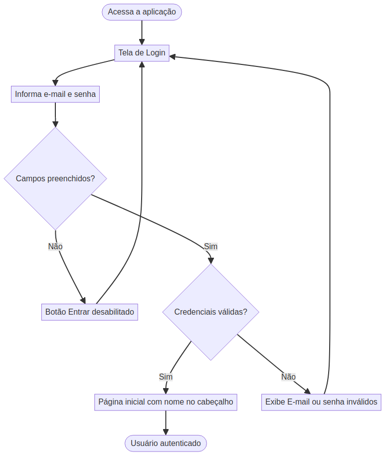

**Os três cenários dos critérios de aceite da US001 aparecem no diagrama como caminhos distintos.** Essa correspondência não é coincidência: é o teste de completude do artefato.

**Os caminhos infelizes são desenhados, não subentendidos.** É tentador desenhar apenas o percurso de sucesso, porque é o mais curto e o mais agradável de mostrar. Mas o caminho de sucesso raramente é o que consome tempo de desenvolvimento: o que consome é a entrada inválida, a sessão expirada, o registro que já existe, a lista vazia e a ação sem permissão. **Um User Flow com um único caminho quase sempre indica que a análise parou cedo demais.**

### 2.4.4 Diagrama de Classes

Um diagrama de classes descreve a arquitetura básica do projeto e a relação entre suas entidades. Ele mostra os atributos e métodos de cada classe, além das restrições que se aplicam à forma como os objetos se conectam.

Enquanto os artefatos anteriores respondem *o que* o sistema faz, este responde **com quais abstrações ele faz**. É o artefato que impede que cada desenvolvedor invente sua própria versão do mesmo conceito — três nomes diferentes para a mesma entidade em três módulos diferentes é um custo de manutenção que se paga até o fim do projeto.

**Anatomia de uma Classe**

Uma classe é representada por uma caixa dividida em três setores principais:

- **Nome da Classe (topo):** identifica a entidade. Deve seguir a convenção da linguagem adotada pelo projeto (na maioria dos casos, PascalCase — ex.: `UsuarioService`).
- **Atributos (meio):** dados e propriedades que a classe armazena.
  - **Estrutura:** declara-se o nome do atributo seguido do seu tipo (primitivo ou outra classe).
  - **Convenção:** segue a convenção da linguagem (geralmente camelCase — ex.: `dataNascimento: Date`).
- **Métodos (base):** ações e comportamentos que a classe executa.
  - **Estrutura:** declara-se o nome do método, os parâmetros com seus respectivos tipos dentro dos parênteses e o tipo de retorno. Caso não haja retorno, indica-se `: void` para melhorar a clareza.
  - **Convenção:** segue a convenção da linguagem (geralmente camelCase — ex.: `calcularDesconto(porcentagem: double): double`).

**Modificadores de Visibilidade**

Os símbolos posicionados antes de cada atributo ou método indicam seu nível de encapsulamento, definindo quais partes do sistema têm permissão para acessá-los:

**`+` Público (Public):** acessível por qualquer classe ou componente do sistema.

**`-` Privado (Private):** acessível exclusivamente dentro da própria classe.

**`#` Protegido (Protected):** acessível na própria classe e por todas as suas subclasses (via herança).

**`~` Pacote (Package / Default):** acessível por qualquer classe localizada no mesmo pacote (grosso modo, na mesma pasta do projeto).

**Constantes e Valores Iniciais em UML**

As constantes devem ser declaradas no setor de atributos e seguem a mesma estrutura básica das variáveis. Contudo, seu nome difere da convenção padrão de variáveis, adotando geralmente o formato UPPER_SNAKE_CASE (letras maiúsculas separadas por *underline*).

Para definir um valor inicial (tanto para variáveis quanto para constantes), utiliza-se o sinal de igual (`=`) seguido do valor desejado:

```
+ EX_CONST: int = 2
- exVar: String = ""
```

**Interfaces em UML**

Para representar uma interface em UML, insere-se a indicação **<<interface>>** (estereótipo) logo acima do seu nome.

**Sem atributos:** por definição, interfaces declaram apenas o contrato de comportamentos que outras classes devem implementar. Por isso, a seção central (reservada a atributos) deve permanecer vazia.

**Visibilidade pública implícita:** como os métodos de uma interface servem justamente para definir contratos públicos, a visibilidade `+` fica subentendida. Portanto, não é necessário incluir o sinal `+` antes das assinaturas dos métodos.

**Classes Abstratas em UML**

Uma classe abstrata serve como modelo parcial para a criação de outras classes. Ela possui ao menos um método abstrato (ou seja, um método apenas com contrato, sem implementação), o que impede que ela seja instanciada diretamente no sistema.

**Estereótipo <<abstract>>:** posicionado logo acima do nome da classe para identificá-la.

**Presença de atributos:** ao contrário das interfaces, as classes abstratas podem declarar atributos com qualquer modificador de visibilidade.

**Métodos em itálico:** os métodos abstratos devem obrigatoriamente ser grafados em itálico para diferenciá-los dos métodos concretos (aqueles que já possuem implementação).

**Enumerações em UML**

Quando um atributo admite apenas um conjunto fixo e conhecido de valores — um papel de usuário, uma unidade de medida, um tipo de transação — representá-lo como texto livre é impreciso e convida ao erro. Nesses casos, utiliza-se o estereótipo **<<enumeration>>**, listando os valores possíveis no setor central.

> **Nota:** a inclusão da enumeração é um acréscimo desta revisão. O texto anterior do capítulo declarava explicitamente que *enums*, dependências e notas em bloco estavam fora do seu escopo — uma limitação do guia, não uma proibição. A prática de projeto já vinha adotando o estereótipo por ganho de precisão, e esta revisão apenas o formaliza.

**Representando Relacionamentos em UML**

A UML estabelece padrões visuais específicos para demonstrar como as classes se conectam, interagem e dependem umas das outras.

**Multiplicidade (Cardinalidade)**

Nas relações de Associação, Agregação e Composição, a multiplicidade indica a quantidade de instâncias de uma classe que podem estar vinculadas a uma instância de outra classe.

As notações mais comuns são:

- **1 (exatamente um):** um pedido deve estar associado a exatamente um cliente.
- **0..1 (zero ou um / opcional):** um pedido pode ter ou não um único cupom de desconto aplicado.
- * ou 0..* (zero ou muitos): um cliente pode não ter realizado nenhum pedido, mas não há limite máximo de pedidos que ele pode fazer.
- **1..* (um ou muitos):** um pedido precisa ter pelo menos um item para existir, sem limite máximo.

Para manter o diagrama limpo e legível, a indicação de multiplicidade é **opcional**. Ela deve ser inserida nas extremidades das linhas apenas quando for crucial deixar explícita uma regra de negócio do sistema.

**Associação**

A associação representa um vínculo entre duas classes independentes. Pelo menos uma das classes tem conhecimento da existência da outra e interage com ela. Por serem independentes, os objetos possuem ciclos de vida próprios: a exclusão de uma classe não provoca a exclusão da outra do sistema.

A associação pode ser dividida em dois tipos principais:

**1. Associação Unidirecional** Ocorre quando apenas uma das classes conhece e acessa a outra.

**Representação visual:** linha sólida com uma seta aberta na ponta, saindo da classe que conhece e apontando para a classe conhecida.

- A classe `Pedido` possui um atributo do tipo `CupomDesconto` para calcular o valor final da compra. O `Pedido` não é “dono” do cupom, apenas o utiliza. Se o pedido for cancelado ou apagado, a classe `CupomDesconto` continuará existindo normalmente no sistema.

**2. Associação Bidirecional** Ocorre quando ambas as classes se conhecem e mantêm referências mútuas.

**Representação visual:** linha sólida simples conectando as duas classes (sem setas nas extremidades).

- A classe `Medico` armazena uma lista de pacientes, e a classe `Paciente` armazena uma lista de médicos (1..* para 1..*). As duas entidades são plenamente independentes: se um médico deixar a clínica e for apagado do sistema, o cadastro do paciente continua existindo e pode ser associado a outros médicos.

**Agregação**

A agregação é uma variação especial da associação que representa uma relação de **“Todo / Parte”** (ou “Todo / Conteúdo”). Embora exista essa ideia de pertencimento, as duas classes possuem ciclos de vida independentes: se a classe principal (“Todo”) for excluída do sistema, a classe contida (“Parte”) continuará existindo normalmente.

**Representação visual:** linha sólida com um losango vazado (diamante transparente) na extremidade conectada à classe principal (“dona” ou “Todo”).

A classe `Jogador` faz parte da classe `Time`, mas possui existência própria. Se o `Time` for apagado do sistema, o cadastro de cada `Jogador` continuará salvo — mantendo seus dados como CPF, nome e posição, mas temporariamente sem time.

**Composição**

A composição é uma relação de “Todo / Parte” com **posse exclusiva e dependência forte**. Ao contrário da agregação, as partes na composição não possuem existência independente: o ciclo de vida da parte está estritamente atrelado ao ciclo de vida do “Todo”. Se a classe principal for excluída do sistema, todas as suas partes vinculadas serão destruídas automaticamente em cascata.

**Representação visual:** linha sólida com um losango preenchido (diamante preto) na extremidade conectada à classe principal (“Todo”).

A classe `Pedido` é composta por objetos da classe `ItemPedido`. Caso um pedido seja removido do sistema, seus itens associados perderão o sentido e serão excluídos junto com ele.

**Multiplicidade no diagrama:** um `Pedido` deve conter um ou mais itens (1..*). Já um `ItemPedido` pertence estritamente a exatamente um `Pedido` (1).

**Generalização (Herança)**

A generalização representa o conceito de herança da Programação Orientada a Objetos, estabelecendo uma relação do tipo **“É um”** (*is-a*). Nela, uma classe filha (subclasse) herda automaticamente todos os atributos e métodos da classe pai (superclasse), podendo adicionar membros exclusivos ou sobrescrever comportamentos.

**Representação visual:** linha sólida com uma seta triangular vazada (branca) na ponta, partindo da subclasse e apontando para a superclasse.

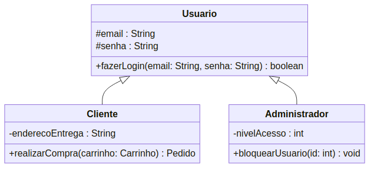

- Tanto `Cliente` quanto `Administrador` são tipos específicos de `Usuario`.
- A superclasse `Usuario` centraliza os dados e comportamentos em comum (como `#email`, `#senha` e `+fazerLogin()`).
- As subclasses mantêm essa base e adicionam apenas suas particularidades: `Cliente` acrescenta `-enderecoEntrega` e `+realizarCompra()`, enquanto `Administrador` acrescenta `-nivelAcesso` e `+bloquearUsuario()`.

**Realização (Implementação)**

A realização ocorre quando uma classe concreta implementa o contrato definido por uma interface. A classe assume a obrigação de fornecer a lógica interna de todos os métodos exigidos, permitindo que o sistema interaja com ela sem precisar conhecer seus detalhes de funcionamento.

**Representação visual:** linha tracejada com uma seta triangular vazada (branca) na ponta, partindo da classe que implementa e apontando para a interface.

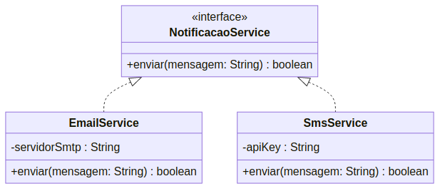

- A interface `NotificacaoService` define o contrato comum: o método `+enviar(mensagem: String): boolean`.
- Tanto `EmailService` quanto `SmsService` realizam essa interface, pois ambos possuem a capacidade de enviar notificações.
- Cada classe executa o envio à sua maneira: `EmailService` utiliza a propriedade interna `-servidorSmtp`, enquanto `SmsService` utiliza `-apiKey`.

**Sintaxe Mermaid para Diagrama de Classes**

Para criar um diagrama de classes, utilizar a anotação a seguir antes de descrever as classes e relacionamentos:

```
classDiagram
```

Abaixo estão os elementos mostrados neste guia utilizando a sintaxe do Mermaid:

**Classes**

```
class Exemplo{
    +atributoPublico : int
    -atributoPrivado : String
    ~metodoPackage(parametro: int) char
    #metodoProtegido() void
}
```

**Interfaces**

```
class Interface <<interface>>{
    +isValid(parametro : int) boolean
}
```

**Classes abstratas**

```
class ClasseAbstrata <<abstract>>{
    -atributo : char
    +metodoAbstrato() int*
}
```

**Enumerações**

```
class Papel <<enumeration>>{
    USUARIO
    ATENDENTE
    EMPRESA
    ADMINISTRADOR
}
```

**Associação unidirecional**

```
Pedido --> CupomDesconto : possui
```

**Associação bidirecional**

```
Medico "1..*" -- "1..*" Paciente : atende
```

**Agregação**

```
Time "0..1" o-- "0..*" Jogador : possui
```

**Composição**

```
Pedido "1" *-- "1..*" ItemPedido : composto por
```

**Generalização**

```
Usuario <|-- Cliente
Usuario <|-- Administrador
```

**Realização**

```
NotificacaoService <|.. EmailService
NotificacaoService <|.. SmsService
```

**Legenda de notação no Mermaid**

**Texto após os dois pontos (`:`):** é o rótulo exibido no meio da linha (utilizado para o verbo que descreve a relação).

**Texto entre aspas nas pontas (`"1..*"`):** indica a multiplicidade posicionada na extremidade correspondente da linha.

**Exemplo consolidado**

Reunindo os relacionamentos acima em um único modelo do domínio da loja online:

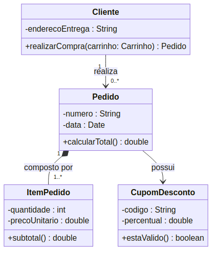

**Considerações finais e boas práticas**

**Diretriz de modelagem:** o detalhamento excessivo das classes pode gerar viés ou burocracia desnecessária durante a implementação. O objetivo do diagrama é **mapear a arquitetura e o fluxo principal com as abstrações corretas**, servindo como guia prático para o projeto — não como especificação antecipada de cada linha de código.

**Escopo do guia:** a linguagem UML possui diversos outros elementos e anotações (como dependências e notas em bloco). Este capítulo prioriza os componentes essenciais para cobrir a maioria dos cenários de desenvolvimento.

**O que o diagrama de classes não consegue mostrar.** Ele descreve a estrutura estática do sistema. Ele não descreve **em que ordem** os objetos conversam entre si (isso é o *capítulo 2.4.5*), nem **quais regras o banco de dados garante fisicamente** (isso é o *capítulo 2.4.6*), nem **em quais processos e servidores tudo isso executa** (isso é o *capítulo 2.4.7*). Tentar espremer essas três respostas dentro de um diagrama de classes é a causa mais comum de diagramas ilegíveis.

**PARTE B — ARQUITETURA E EXECUÇÃO**

As quatro seções anteriores descrevem **o que** o sistema faz, **para quem**, **por onde o usuário passa** e **com quais abstrações** ele é construído. Nada disso responde a três perguntas que aparecem invariavelmente na primeira semana de desenvolvimento:

- *Em que ordem os componentes conversam quando alguma coisa dá errado no meio?*
- *Quais regras o banco de dados garante, e quais dependem de o programador lembrar?*
- *Onde isso tudo executa, e quem paga a conta?*

As seções desta parte respondem a essas três perguntas. **Elas não são obrigatórias em todo projeto** — a tabela *“Qual diagrama, quando”* define o gatilho de cada uma.

### 2.4.5 Diagrama de Sequência

O Diagrama de Sequência é um **diagrama comportamental** responsável por descrever a **ordem temporal dos eventos** em um processo, mapeando a troca de mensagens entre os elementos envolvidos.

Cada diagrama foca em uma funcionalidade específica. Embora a literatura tradicional o associe aos Diagramas de Casos de Uso, no padrão de documentação da IDE **cada Diagrama de Sequência é construído a partir de um User Flow**, tomando a User Story correspondente como base para as regras de negócio.

**Pontos iniciais importantes**

Nem toda User Story exige um Diagrama de Sequência. Em fluxos simples, a combinação da User Story com o User Flow já é suficiente para orientar o desenvolvimento.

**Quando criar um Diagrama de Sequência?**

Recomenda-se elaborar o diagrama principalmente nas seguintes situações:

- **Comunicação entre serviços:** quando a requisição transita por múltiplos serviços ou microsserviços.
- **Integração com APIs externas:** quando há consumo de serviços terceiros (ex.: gateways de pagamento, autenticação, APIs de mapas).
- **Regras de negócio complexas:** cenários que envolvem a orquestração de várias classes e processamento assíncrono.

A esses três acrescentamos dois gatilhos que a experiência de projeto tornou evidentes:

- **Operações que alteram estado sob concorrência** — saldos, estoques, reservas. O diagrama é onde fica visível se duas requisições simultâneas podem produzir um resultado inconsistente.
- **Operações que podem ser repetidas pelo usuário** — o clique duplo, o botão pressionado de novo depois de a conexão cair. O diagrama expõe se a repetição gera efeito duplicado.

**Nota sobre o escopo:** esta seção aborda os elementos essenciais do Diagrama de Sequência. Embora a notação UML inclua recursos mais avançados, os conceitos apresentados aqui cobrem a vasta maioria das necessidades dos projetos práticos da empresa júnior.

**Elementos de um Diagrama de Sequência**

**Ator:** entidade externa (geralmente um usuário ou outro sistema) que origina a ação inicial descrita no fluxo. É representado visualmente por uma figura humana estilizada (*stick figure*).

**Participantes (Linhas de Vida):** módulos internos do sistema que interagem para concretizar a funcionalidade — classes, serviços, *controllers* ou repositórios. A representação padrão é um retângulo contendo o nome do componente, mas também podem ser utilizados ícones específicos para identificar papéis no sistema.

**Mensagens:** descrevem a comunicação e a troca de dados entre o ator e os participantes ao longo do tempo. As principais são:

- **Mensagem Direta / Síncrona (Chamada):** requisição de uma ação ou execução de um método. O elemento de origem envia a solicitação e aguarda o processamento. Representada por uma **linha contínua com seta**.
- **Mensagem de Retorno (Resposta):** dados ou confirmações devolvidos após a conclusão de uma chamada. Representada por uma **linha pontilhada com seta**.
- **Autochamada (Autodelegação):** execução de uma regra de negócio ou método interno dentro do próprio participante antes de emitir uma resposta. Representada por uma **linha contínua que parte e retorna ao mesmo elemento**.

**Ciclo de vida de um participante**

Cada participante possui um ciclo de vida representado por uma **linha vertical tracejada** (a Linha de Vida), que se estende a partir do seu bloco de identificação no topo até a conclusão do processo.

Um participante pode existir desde o início da execução ou ser instanciado ao longo do fluxo por meio de uma mensagem de criação. Da mesma forma, seu ciclo pode se encerrar ao final do diagrama ou por destruição explícita — embora o encerramento explícito seja raramente utilizado na prática, já que linguagens modernas contam com gerenciamento automático de memória (*Garbage Collector*).

**Mensagem Construtora (Criação):** instancia um novo participante no decorrer do fluxo (equivalente ao operador `new`). É representada por uma linha contínua com seta apontando diretamente para o bloco do novo participante.

**Convenções de notação para mensagens**

Para garantir a padronização e a legibilidade dos diagramas, siga as seguintes regras de nomenclatura:

- **Mensagens Diretas, Construtoras e Autochamadas:** devem conter uma descrição no infinitivo, seguida de dois pontos e da assinatura do método.
  - **Sintaxe:** `Ação no infinitivo: nomeDoMetodo(parametros)`
  - **Exemplo:** `Validar regra do cupom: validarCupom(codigo)`
- **Mensagens de Retorno:** devem descrever a ação de entrega no infinitivo, seguida de dois pontos e do **tipo de dado** retornado (sem o nome de variáveis).
  - **Sintaxe:** `Ação no infinitivo: TipoDoRetorno`
  - **Exemplo:** `Retornar cupom encontrado: Cupom`

A razão da regra é dupla: a descrição em português torna o diagrama legível por quem não vai programar aquele trecho, e a assinatura torna o diagrama utilizável por quem vai. **Um diagrama que tem apenas a assinatura vira código mal escrito; um que tem apenas a descrição vira ata de reunião.**

**Controle de fluxo no diagrama**

**Alt (Condicionais e Fluxos Alternativos):** bloco utilizado para representar ramificações de lógica (equivalente ao `if/else`). Descreve cenários e caminhos alternativos que o sistema pode seguir dependendo do resultado de uma validação.

**Loops (Repetições):** bloco que delimita um conjunto de mensagens executadas repetidamente (equivalente ao `for/while`), seja para iterar sobre uma coleção, seja para repetições sob condição.

**Parallel (Execução Paralela):** bloco que representa chamadas ou tarefas executadas de forma simultânea por *threads* ou serviços assíncronos distintos.

**Activations (Barras de Ativação):** retângulos verticais sobre a linha de vida de um participante que indicam o período exato em que aquele componente está ocupado processando uma requisição.

**Sintaxe Mermaid para Diagrama de Sequência**

Para criar um diagrama de sequência, inclua a diretiva `sequenceDiagram` na primeira linha do código.

**1. Atores e Participantes**

É boa prática declarar todos os atores e participantes no topo do arquivo, para definir a ordem em que aparecerão no diagrama (da esquerda para a direita).

**Atores e *aliases*:** utilize a chave `actor` para pessoas ou sistemas externos. O operador `as` define um *alias* — o nome amigável exibido no diagrama, enquanto o código usa uma identificação curta.

```
actor C as Cliente
```

**Participantes genéricos:** utilize a chave `participant` para módulos, serviços ou classes.

```
participant T as TelaCarrinho
```

**Tipos especiais de participantes:** para atribuir uma identidade visual específica ao componente, utilize a propriedade:

- **Boundary (Fronteira/Interface):** representa os pontos de contato do sistema com o mundo externo. Utilizado para elementos de interface com o usuário ou portas de entrada de uma API (ex.: `TelaLogin`, `FormularioCheckout`, `UsuarioController`).

```
participant T@{"type": "boundary"} as TelaLogin
```

- **Control (Controle/Regra de Negócio):** representa a camada intermediária que orquestra a lógica do sistema. Recebe os comandos da fronteira, aplica as regras de negócio e interage com as entidades (ex.: `AutenticacaoService`, `PagamentoProcessor`).

```
participant P@{"type": "control"} as PagamentoProcessor
```

- **Entity (Entidade/Dados):** representa os objetos estruturais do modelo de domínio que carregam as informações da aplicação e possuem estado persistente (ex.: `Usuario`, `Pedido`, `Produto`).

```
participant P@{"type": "entity"} as Pedido
```

- **Database (Banco de Dados):** representa o repositório final de persistência, onde as informações do sistema são armazenadas fisicamente.

```
participant DB@{"type": "database"} as DataBase
```

> **Atenção à versão do Mermaid.** A sintaxe de tipos de participante (`@{"type": ...}`) é um recurso **recente** da ferramenta e não é interpretada por renderizadores desatualizados — em versões antigas, o diagrama inteiro falha, não apenas o ícone. Antes de adotá-la em um projeto, valide-a no renderizador que a equipe realmente usa (o preview do GitHub, o editor do VS Code, o Mermaid Live Editor). **Havendo dúvida, use `participant` simples:** a estratificação fronteira → controle → entidade → banco continua legível pela nomenclatura e pela ordem dos participantes, que é o que de fato importa.

**2. Tipos de mensagens**

Mensagens diretas:

```
C->>T: Clicar em aplicar cupom: submeterCupom()
```

Mensagens de retorno:

```
R-->>S: Retornar cupom encontrado: Cupom
```

Autochamadas:

```
S->>S: Calcular valor do desconto: calcularDesconto(cupom)
```

**Mensagem construtora (criação de objeto):** para instanciar um participante no meio do fluxo, utilize a palavra-chave `create` na linha anterior à mensagem de chamada:

```
create participant CUP as Cupom
S->>CUP: Criar cupom: createCupom(float)
```

**3. Controle de fluxo**

**Alt (condicional / *if-else*):** o texto após `alt` e `else` especifica as condições avaliadas.

```
alt Pagamento aprovado
      S-->>T: Retornar confirmação: Boolean
else Pagamento recusado
      S-->>T: Retornar falha: Exception
end
```

**Loop (repetição / *for-while*):** o texto após `loop` descreve a condição de parada ou a coleção percorrida.

```
loop Para cada item do carrinho
      C->>I: Buscar dados do produto: buscarPorId(id)
      I-->>C: Retornar produto: Produto
end
```

**Parallel (execução simultânea / *threads*):** os blocos delimitados por `par` e `and` contêm as ações executadas concorrentemente.

```
par Enviar e-mail de confirmação
      P->>N: Enviar e-mail: enviarEmail(pedidoId)
      N-->>P: Retornar status: Boolean
and Enviar mensagem via SMS
      P->>N: Enviar SMS: enviarSMS(pedidoId)
      N-->>P: Retornar status: Boolean
end
```

**Activations (barras de ativação):** o caractere `+` no envio ativa o tempo de processamento no participante receptor, e o caractere `-` no retorno o desativa.

```
C->>+E: Reservar estoque: reservarItem(id, quantidade)
E-->>-C: Retornar confirmação: Boolean
```

**Exemplo completo**

Reunindo os elementos acima no fluxo de finalização de compra (RF006 / US006), derivado do User Flow correspondente:

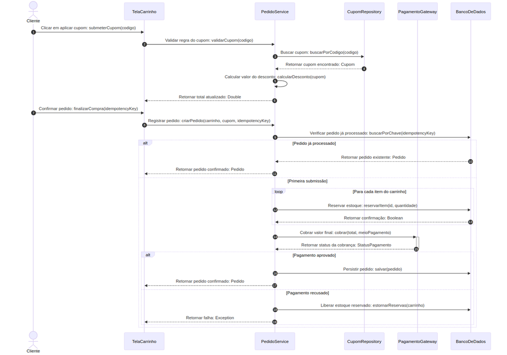

**Três coisas que só este diagrama torna visíveis**

1. **A ordem entre reserva de estoque e cobrança.** Cobrar antes de reservar produz um cliente pago sem produto; reservar sem estornar produz estoque preso indefinidamente. O diagrama força a decisão a ser tomada e registrada.
2. **O tratamento da submissão repetida.** O `idempotencyKey` existe porque o cliente pode perder a conexão, não saber se o pedido passou e clicar de novo. Sem esse desvio, a repetição gera um segundo pedido e uma segunda cobrança — **um defeito que passa silenciosamente por revisão de código, porque cada trecho isolado está correto**.
3. **A fronteira com o serviço externo.** `PagamentoGateway` é a única linha de vida que a IDE não controla. Tudo que atravessa aquela seta pode falhar por motivos alheios ao código, e o diagrama mostra exatamente onde o tratamento de falha precisa existir.

**Boas práticas e dicas**

- **Numeração automática:** inclua a instrução `autonumber` logo após `sequenceDiagram` para enumerar os passos em ordem cronológica. É o que permite discutir o diagrama em uma revisão — *“o problema está no passo 7”* é uma frase útil; *“o problema está naquela seta ali”* não é.
- **Ordem de leitura:** as mensagens são desenhadas no diagrama na exata ordem vertical em que são declaradas no código.
- **Instanciação tardia:** declare no início do script apenas os componentes que existem desde o início do processo. Componentes instanciados dinamicamente devem ser introduzidos apenas via comando `create`.
- **Um diagrama, um fluxo.** A Regra de Ouro do User Flow (*2.4.3*) vale aqui igualmente. Um diagrama de sequência que tenta cobrir o cadastro, o login e a recuperação de senha ao mesmo tempo não será lido por ninguém.
- **A origem dos dados sensíveis vem do contexto autenticado, nunca do corpo da requisição.** Se um participante precisa saber *a qual unidade, loja ou organização* a operação pertence, esse dado deve ser derivado do token de quem chamou — não enviado pelo cliente. Quando o diagrama mostra esse dado chegando pela mensagem do ator, há uma falha de autorização desenhada em público.

**Referências desta seção**

GUEDES, Gilleanes T. A. *UML 2 — Uma Abordagem Prática*. Novatec Editora.

FOWLER, Martin. *UML Essencial: Um Breve Guia para a Linguagem-Padrão de Modelagem de Objetos*. Bookman.

Documentação oficial do Mermaid — *Sequence Diagrams*.

### 2.4.6 Modelo Físico de Dados e Máquinas de Estado

> **Status desta seção:** acréscimo desta revisão. O Diagrama de Classes já era padrão da IDE; o modelo físico e as máquinas de estado vinham sendo produzidos em projeto por necessidade, sem estarem previstos no Manual. Esta seção formaliza a prática e define o gatilho de cada artefato.

#### Por que o Diagrama de Classes não basta

O Diagrama de Classes (*2.4.4*) descreve as abstrações do código. Ele **não tem onde representar as garantias do banco de dados** — uma restrição de unicidade, uma verificação de valor, uma chave estrangeira com exclusão em cascata, um índice que impede sobreposição de períodos.

Essa lacuna importa porque as duas camadas oferecem níveis de garantia radicalmente diferentes:

- Uma regra escrita **no código** vale enquanto todo caminho de escrita passar por aquele código. Uma rotina de importação, um script de correção ou um segundo *endpoint* escrito às pressas a contornam sem aviso.
- Uma regra escrita **no banco** vale sempre. O banco recusa a operação, independentemente de quem a tentou.

> **REGRA —** Quando uma regra de negócio é garantida por uma restrição de banco de dados, essa restrição **precisa estar visível em um diagrama**. Se ela existe apenas dentro de um arquivo de migração, ela deixará de ser conhecida assim que sair a pessoa que a escreveu — que é exatamente o risco estrutural que este Manual existe para mitigar.

#### Diagrama Entidade-Relacionamento (ERD)

O ERD descreve o **modelo físico**: as tabelas que existirão de fato, suas colunas, suas chaves e a cardinalidade entre elas.

**Notação de cardinalidade no Mermaid**

A cardinalidade é escrita nas duas pontas do relacionamento. O símbolo mais próximo da entidade descreve **quantas instâncias daquela entidade** participam da relação:

Lê-se de fora para dentro, no estilo *pé de galinha* (*crow’s foot*):

- `|o` à esquerda, `o|` à direita — **zero ou um**
- `||` dos dois lados — **exatamente um**
- `}o` à esquerda, `o{` à direita — **zero ou muitos**
- `}|` à esquerda, `|{` à direita — **um ou muitos**

O traço central indica a força da dependência:

- `--` **relacionamento identificador** (linha sólida): a entidade filha não existe sem a mãe — equivale à composição do diagrama de classes.
- `..` **relacionamento não identificador** (linha tracejada): a filha existe independentemente.

**Marcadores de chave:** `PK` (chave primária), `FK` (chave estrangeira) e `UK` (chave única).

**Exemplo trabalhado**

Retomando a loja online, agora no nível físico:

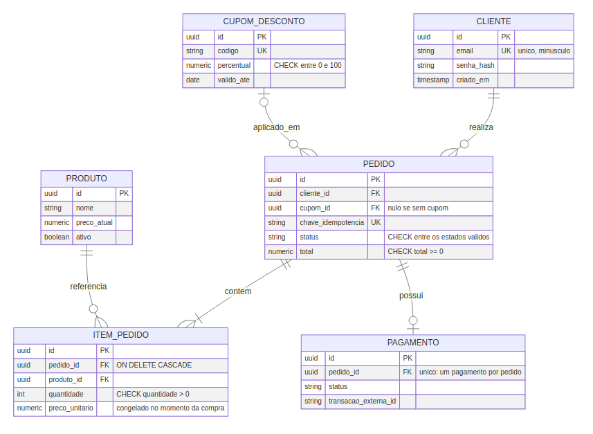

**Quatro decisões estão registradas nesse diagrama, e nenhuma delas caberia no diagrama de classes:**

1. `chave_idempotencia UK` — é a restrição de unicidade que **efetivamente** impede o pedido duplicado do *capítulo 2.4.5*. O código que verifica antes de inserir reduz a chance; a chave única elimina.
2. `preco_unitario` no item, e não apenas no produto — o preço é **congelado** no momento da compra. Sem isso, alterar o preço de um produto reescreve o histórico de todos os pedidos anteriores.
3. `ON DELETE CASCADE` em `ITEM_PEDIDO` — a composição do diagrama de classes traduzida em garantia real do banco.
4. `CHECK quantidade > 0` — a regra que o formulário valida na tela, aplicada também onde nenhuma tela alcança.

**Quando o ERD é obrigatório**

- Alguma regra de negócio é garantida por restrição de banco (o caso mais importante).
- O sistema tem mais de oito tabelas, ou possui chaves compostas.
- Há mais de um caminho de escrita para a mesma tabela.

**Quando é desperdício:** protótipo descartável, ou sistema cujo modelo é a tradução literal e sem surpresas do diagrama de classes.

#### Máquinas de Estado

Nem toda entidade tem ciclo de vida. As que têm concentram uma quantidade desproporcional de defeitos — porque a pergunta *“desse estado, para onde é permitido ir, e quem tem permissão de levar?”* costuma ser respondida de forma diferente em cada tela que a manipula.

> **REGRA —** Uma entidade com **três ou mais estados**, e com regra própria em cada transição, tem uma máquina de estados desenhada. Um campo booleano `ativo/inativo` não tem — descrevê-lo em uma frase é suficiente.

**Sintaxe Mermaid**

```
stateDiagram-v2
    direction LR
    [*] --> EstadoInicial : evento que cria
    EstadoInicial --> OutroEstado : evento e condição
    OutroEstado --> [*]
```

`[*]` representa o início e o fim do ciclo de vida. **O rótulo de cada seta descreve o evento e a condição que autorizam a transição** — uma seta sem rótulo é uma pergunta sem resposta.

**Exemplo trabalhado**

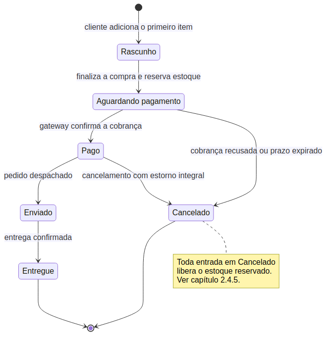

**O que este diagrama decide, e que de outro modo seria decidido em código, por acidente:**

- **`Entregue` não volta.** Não há seta saindo de `D`. Devolução, se existir, é outro processo, com outra entidade — e, se não foi contratada, é `Won’t Have`.
- **`Enviado` não pode ser cancelado.** A ausência da seta `E --> C` é uma regra de negócio, e é a ausência que a comunica. **Em máquinas de estado, as setas que não existem valem tanto quanto as que existem.**
- **O estorno está atrelado à transição, não ao botão.** Qualquer caminho que chegue a `Cancelado` libera o estoque — inclusive um caminho criado seis meses depois por outra pessoa.

### 2.4.7 Visão Arquitetural: o Modelo C4

> **Status desta seção:** acréscimo desta revisão, e **proposta de adoção**. O Manual não possuía nenhum artefato entre a jornada do usuário e o diagrama de classes. Na prática de projeto, essa lacuna já vinha sendo preenchida de forma espontânea — pacotes de definição recentes organizam a arquitetura exatamente nos níveis descritos abaixo, sem chamá-los pelo nome. Esta seção dá nome, notação e gatilho ao que a equipe já fazia por necessidade.

#### O problema que o C4 resolve

Peça a três desenvolvedores um “diagrama de arquitetura” e você receberá três desenhos em três níveis de abstração diferentes: um mostrará servidores, outro mostrará classes, o terceiro mostrará telas. Nenhum estará errado. Nenhum será comparável ao outro.

O **Modelo C4** (Simon Brown) resolve isso com uma ideia simples: **arquitetura se documenta em níveis de zoom sucessivos**, como um mapa. Cada nível tem um público, uma pergunta e um grau de detalhe definidos. Você não mistura escalas na mesma folha, assim como um mapa rodoviário não desenha a planta das casas.

| Nível | Nome | Pergunta que responde | Público |
| --- | --- | --- | --- |
| **1** | **Contexto** | O que é este sistema, quem o usa e com o que ele conversa? | Cliente, Comercial, equipe inteira |
| **2** | **Contêiner** | De que peças executáveis ele é feito e como elas se comunicam? | Toda a equipe técnica |
| **3** | **Componente** | Como um módulo específico se organiza por dentro? | Quem vai desenvolver aquele módulo |
| **4** | **Código** | Como as classes daquele componente se relacionam? | Quem está escrevendo aquele arquivo |

> **REGRA DE ADOÇÃO NA IDE —** Os **níveis 1 e 2 são obrigatórios** em qualquer projeto com mais de um ator ou com qualquer dependência externa. O **nível 3 é produzido apenas para o módulo que concentra a regra de negócio** do sistema — aquele que, se estiver errado, compromete o produto inteiro. O **nível 4 não é desenhado à mão**: ele já é o Diagrama de Classes do *capítulo 2.4.4*.

**Sobre a notação:** o Mermaid possui suporte nativo experimental a diagramas C4 (`C4Context`), mas seu comportamento ainda varia entre versões. **A recomendação da IDE é desenhar os níveis com `graph TB` e `subgraph`**, que é estável, universalmente renderizado e perfeitamente adequado. O valor do C4 está na disciplina dos níveis, não na notação.

#### Nível 1 — Diagrama de Contexto

Uma única caixa para o sistema. Em volta, todos os atores humanos e todos os sistemas externos. Nenhum detalhe interno.

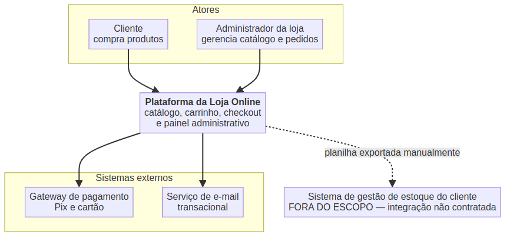

**A caixa `FORA` é o elemento mais valioso deste diagrama.** Desenhar explicitamente o que está fora da fronteira — em vez de simplesmente omitir — transforma a lista de exclusões da Matriz de Requisitos (*2.4.1*) em imagem. É a diferença entre o cliente entender que a integração não existe e o cliente descobrir isso na entrega.

> **REGRA —** No diagrama de contexto, **o que foi deliberadamente excluído é desenhado como excluído**, com linha tracejada e rótulo explícito. Omitir comunica esquecimento; desenhar excluído comunica decisão.

#### Nível 2 — Diagrama de Contêiner

Abre-se a caixa do sistema. Cada **contêiner** é uma unidade executável ou de armazenamento independente: uma aplicação web, uma API, um banco de dados, um serviço agendado. **Contêiner aqui não significa contêiner Docker** — significa “coisa que roda separadamente”.

Este é o nível em que a **pilha tecnológica padrão da IDE** aparece por escrito:

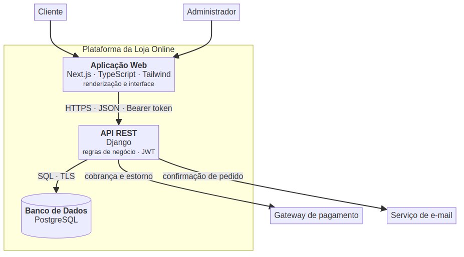

**Cada seta é rotulada com o protocolo e o propósito.** Uma seta sem rótulo entre dois contêineres é uma decisão de integração que ainda não foi tomada.

**Este é também o diagrama que expõe as quebras de padrão.** A pilha da IDE é fixa por política — Next.js/TypeScript/Tailwind, Django, PostgreSQL, Docker, JWT/OAuth, REST, Payload CMS. Qualquer caixa neste diagrama que contenha uma tecnologia fora dessa lista exige um **Research Card aprovado**, e esse Research Card é **custo real de cronograma**, não formalidade. Desenhar o nível 2 antes de planejar as sprints é o que faz esse custo aparecer enquanto ainda dá tempo de absorvê-lo.

#### Nível 3 — Diagrama de Componente

Abre-se **um** contêiner — normalmente a API — e apenas no módulo que concentra a complexidade.

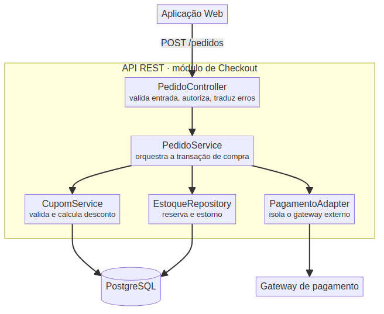

Duas convenções tornam este nível útil em vez de decorativo:

- **Componentes são nomeados por responsabilidade, não por camada.** `PagamentoAdapter` diz o que faz; `UtilsService` não diz nada e quase sempre indica que a responsabilidade ainda não foi decidida.
- **O adaptador que isola o serviço externo é desenhado explicitamente.** É ele que permite trocar de gateway sem reescrever a regra de negócio — e é a peça que um desenvolvedor iniciante costuma não criar, chamando o serviço externo direto de dentro da regra.

#### Nível 4 — Código

**Não desenhe.** Este nível é o Diagrama de Classes do *capítulo 2.4.4*, e mesmo ele deve ser mantido no grau de abstração descrito lá: *“mapear a arquitetura e o fluxo principal com as abstrações corretas”*. Um diagrama que reproduz classe por classe o conteúdo do repositório estará desatualizado na primeira sprint e é trabalho jogado fora — o código é a documentação fiel desse nível, por definição.

#### Diagrama de Implantação

Formalmente o C4 trata implantação como uma visão suplementar. **Na IDE ela é obrigatória para todo projeto hospedado**, por uma razão prática e financeira: é o único diagrama que responde *quem paga a conta depois que o contrato acabar*.

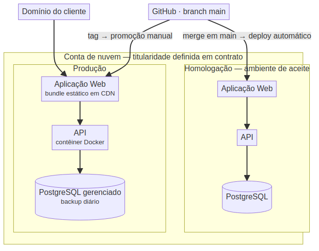

**Três regras que este diagrama obriga a decidir por escrito:**

1. **Titularidade da conta.** A IDE não deve manter credencial que não possa transferir ao cliente ao fim do contrato. Contas criadas em nome de um membro deixam a empresa junto com o membro.
2. **Custo recorrente tem dono nomeado.** Se a hospedagem, o serviço de e-mail ou a API de mapas geram cobrança mensal, **quem paga precisa estar escrito**. Custo recorrente sem responsável definido é um passivo que sobrevive ao contrato — e o diagrama de implantação é o lugar onde essa omissão fica impossível de ignorar.
3. **Produção é promovida por ato deliberado.** A automação vai até a homologação; a passagem para produção é decisão humana, pelo mesmo princípio do *capítulo 2.2.7*, onde o *merge* é ato consciente após revisão — e não consequência automática de o código ter compilado.

**Regra dos três ambientes:** local (`docker compose`), homologação (onde o cliente aceita) e produção. **A homologação nunca recebe dados pessoais reais de produção** — cópia de base para ambiente de teste é o vazamento de dados mais comum e mais evitável que uma equipe júnior pode provocar.

### 2.4.8 Documentação como Código (*Docs-as-Code*)

> **Status desta seção:** acréscimo desta revisão, e **proposta de padronização**. A escolha do Mermaid já era prática da IDE nos capítulos 2.4.3 e 2.4.4; esta seção explicita *por quê*, e o que decorre disso para o fluxo de trabalho do *capítulo 2.2*.

#### O problema: o diagrama que mente

Todo diagrama neste capítulo tem o mesmo inimigo, e não é a notação errada: é o **desatualizado**.

Um diagrama desatualizado é pior que a ausência de diagrama, porque um membro novo confia nele. Ele lê a arquitetura de seis meses atrás, implementa contra ela, e o defeito só aparece na integração. A ausência de diagrama pelo menos obriga a pessoa a perguntar.

A causa raiz é quase sempre a mesma e é mecânica, não de disciplina: **o diagrama mora longe do código que ele descreve.** Quando a figura é um PNG exportado de uma ferramenta de desenho, anexado a uma pasta compartilhada, três coisas acontecem de forma previsível:

- Ninguém sabe onde está o arquivo-fonte editável, ou ele está na conta pessoal de quem já saiu.
- A alteração do código e a alteração da figura são dois atos separados, e o segundo é opcional.
- A revisão do Pull Request não vê a figura, logo não tem como cobrá-la.

#### A solução: o diagrama é código-fonte

**Documentação como Código** é o princípio de tratar a documentação técnica com as mesmas ferramentas e o mesmo rigor do código: **texto puro, versionado no mesmo repositório, alterado no mesmo *commit*, revisado no mesmo Pull Request.**

É exatamente por isso que este Manual especifica **Mermaid** e não uma ferramenta gráfica. Não é preferência estética. As consequências são operacionais:

| Propriedade | Diagrama em Mermaid (texto) | Imagem exportada |
| --- | --- | --- |
| **Histórico** | Cada alteração aparece no `git log`, com autor e data | Um binário substitui o outro |
| **Revisão** | O revisor vê **exatamente o que mudou**, linha a linha | O revisor vê “imagem alterada” |
| **Fonte editável** | É o próprio arquivo, no repositório | Um `.fig`, `.drawio` ou `.pptx` em algum lugar |
| **Dependência de conta** | Nenhuma | A conta de quem criou o arquivo |
| **Custo de manter** | Editar uma linha | Abrir a ferramenta, reexportar, reanexar |
| **Renderização** | Nativa no GitHub, no VS Code e neste Manual | Precisa da imagem em si |

> **REGRA GERAL DA SEÇÃO —** Todo diagrama de projeto da IDE nasce como **texto Mermaid dentro do repositório do projeto**. Imagem exportada é aceitável como cópia para apresentação ao cliente, **nunca como fonte da verdade**.

#### A regra que faz o mecanismo funcionar

Versionar o diagrama junto ao código só resolve o problema se houver um momento em que a divergência é detectada. Esse momento é a revisão do Pull Request (*capítulo 2.2.6*).

> **REGRA —** Um Pull Request que altera um **contrato** — uma entidade, um *endpoint*, uma máquina de estados, uma dependência externa, um relacionamento entre módulos — **altera o diagrama correspondente no mesmo Pull Request**. O revisor que aprova o código sem o diagrama atualizado aprovou a próxima desatualização.

Isso adiciona três itens verificáveis ao *checklist* de revisão já descrito no *capítulo 2.2.5*:

- O diagrama afetado foi atualizado no mesmo *commit*?
- O diagrama ainda renderiza? (um erro de sintaxe em Mermaid quebra o bloco silenciosamente no GitHub — ele simplesmente não aparece)
- A alteração introduziu alguma tecnologia ou dependência externa que não estava no diagrama de contêiner (*2.4.7*)?

#### Onde os diagramas moram

A organização abaixo é sugestão, não obrigação — o que é obrigatório é que os diagramas estejam **dentro do repositório do projeto**, em texto, e que qualquer membro saiba onde procurar sem perguntar:

```
docs/
├── 01-requisitos.md          ← Matriz de Requisitos Funcionais (2.4.1)
├── 02-user-stories.md        ← User Stories e critérios de aceite (2.4.2)
├── 03-user-flows.md          ← um diagrama por jornada (2.4.3)
├── 04-arquitetura.md         ← C4 níveis 1 a 3 e implantação (2.4.7)
├── 05-modelo-de-dominio.md   ← classes, ERD e máquinas de estado (2.4.4 e 2.4.6)
├── 06-sequencias.md          ← apenas os fluxos que exigem (2.4.5)
└── 07-decisoes.md            ← ADRs
```

#### PlantUML: quando o Mermaid não alcança

O Mermaid é o padrão porque renderiza nativamente onde a equipe já trabalha, sem instalar nada. Ele tem limites: notações UML mais exóticas, diagramas de classes muito grandes, controle fino de posicionamento.

**PlantUML** é a alternativa aceita nesses casos. Ele é mais expressivo e possui a biblioteca `C4-PlantUML`, que implementa a notação C4 formalmente. Em contrapartida, **exige um servidor de renderização ou uma extensão instalada** — ou seja, um passo a mais na configuração de cada máquina da equipe.

> **REGRA —** O padrão é Mermaid. PlantUML é exceção justificada, adotada **por projeto** e registrada — nunca por preferência individual de um membro. Um repositório com metade dos diagramas em cada ferramenta tem o pior dos dois mundos.

#### O que nenhum diagrama consegue registrar: o ADR

Um diagrama mostra **o que foi decidido**. Ele é incapaz de mostrar **o que foi rejeitado e por quê** — e essa é justamente a informação que se perde primeiro, e que custa mais caro quando falta.

O sintoma é conhecido: três meses depois, um membro pergunta *“por que não usamos simplesmente X?”*. Se a resposta não estiver escrita em lugar nenhum, uma de duas coisas acontece — a discussão é refeita do zero no meio de uma sprint, ou pior, a decisão é silenciosamente revertida dentro de um Pull Request, por alguém que não sabia que ela havia sido tomada.

O **ADR (*Architecture Decision Record*)** é o registro que resolve isso. É um documento curto, um por decisão, imutável depois de aceito — uma decisão que muda gera um **novo** ADR que supersede o anterior, nunca uma edição do antigo. O histórico é o produto.

**Modelo mínimo:**

```markdown
# ADR-007 — Título curto e afirmativo da decisão

**Status:** Proposto | Aceito | Substituído por ADR-0NN
**Data:** AAAA-MM-DD

## Contexto
O que era verdade quando a decisão foi tomada: a restrição, o requisito,
o problema observado.

## Decisão
O que foi decidido, em uma ou duas frases, no presente do indicativo.

## Alternativas rejeitadas
- **Alternativa A** — por que não. Esta seção é o motivo de o documento existir.
- **Alternativa B** — por que não.

## Consequências
O que fica mais fácil e o que fica mais difícil a partir daqui, incluindo
o que a equipe passa a ser obrigada a fazer.
```

**Quando escrever um ADR:** quando a decisão é **cara de reverter** e **não é óbvia** — escolha de biblioteca estruturante, modelo de autenticação, estratégia de persistência, adoção de tecnologia fora da pilha padrão (que também exige Research Card), fronteira entre módulos.

**Quando não escrever:** decisões locais e reversíveis. Nomear uma variável não é um ADR.

> **A conexão com a rotatividade.** Todo este Manual existe porque a IDE opera com alta rotatividade de membros. **O ADR é o artefato mais diretamente antirrotatividade de todos** — é o único que preserva o raciocínio, e não apenas o resultado. Um diagrama transfere a arquitetura; um ADR transfere o julgamento.

### 2.4.9 Anti-padrões de diagramação

Os seis erros abaixo respondem pela maior parte do esforço desperdiçado com diagramas. Todos são reconhecíveis antes de custarem caro.

| Anti-padrão | Como se manifesta | Correção |
| --- | --- | --- |
| **O diagrama que ninguém atualizou** | Existe, é bonito, e descreve o sistema de três meses atrás. Um membro novo implementa contra ele | Diagrama vive no repositório e muda no mesmo Pull Request que muda o contrato (*2.4.8*) |
| **O sistema inteiro em uma folha** | Um único diagrama com todas as telas, todos os atores e todos os fluxos. Ilegível a partir da terceira semana | Regra de Ouro (*2.4.3*): um diagrama, uma jornada. Para visão geral, use o nível 1 do C4 (*2.4.7*) |
| **Detalhar antes de decidir** | Diagrama de classes com 40 classes e todos os *getters*, produzido antes de a arquitetura estar resolvida | *“Mapear a arquitetura e o fluxo principal com as abstrações corretas”* (*2.4.4*). Detalhe é consequência da decisão, não substituto dela |
| **Diagramar o óbvio** | Sequência de seis passos para um CRUD linear; máquina de estados para um booleano | Tabela *“Qual diagrama, quando”*. Se ninguém precisou explicar aquilo em voz alta, não desenhe |
| **A arquitetura de vitrine** | Microsserviços, filas e *cache* distribuído desenhados para um sistema de quatro telas, porque parece profissional | Cada caixa é custo de sprint e de manutenção. A pilha é fixa por política; sair dela exige Research Card aprovado, com custo de cronograma real |
| **O PNG órfão** | A figura está na apresentação; o arquivo editável estava na conta de quem saiu da empresa | Fonte da verdade é texto no repositório (*2.4.8*) |

Um sétimo, mais sutil e específico da fase de execução:

**O diagrama que promete escopo.** Um diagrama de contexto ou de contêiner apresentado ao cliente comunica intenção, mesmo sem uma linha de texto. Se ele mostra uma integração que não foi contratada — ainda que como possibilidade futura, ainda que em cinza —, essa integração passou a ser esperada. **Todo elemento fora do escopo desenhado para o cliente deve estar rotulado como fora do escopo, de forma inequívoca** (*2.4.7*, regra da fronteira).

### Checklist de diagramação

A percorrer **antes de a primeira sprint ser planejada**, e novamente ao fim de cada fase entregue.

**Escopo e comportamento**

- Todo requisito da Matriz tem ID, módulo, prioridade MoSCoW e fase.
- Todo ator do sistema — inclusive os administrativos — tem entrada própria na Matriz.
- Nenhuma fase depende operacionalmente de um requisito alocado a uma fase posterior.
- O que ficou de fora está registrado como `Won’t Have`, não omitido.
- Toda User Story passa no INVEST; as que falham em **S** foram fatiadas verticalmente.
- Todo critério de aceite está em BDD e é verificável por quem não escreveu o código.
- Cada jornada relevante tem um User Flow, e **cada cenário dos critérios de aceite tem um caminho nele** — inclusive os caminhos de erro.

**Arquitetura e execução**

- Existe Diagrama de Classes com as abstrações do domínio, sem detalhamento excessivo.
- Existem diagramas de sequência para os fluxos com serviço externo, transação, concorrência ou possibilidade de repetição pelo usuário.
- Toda regra de negócio garantida por restrição de banco está visível no ERD.
- Toda entidade com três ou mais estados tem máquina de estados, com evento rotulado em cada transição.
- Existem os níveis 1 e 2 do C4, e o nível 3 do módulo crítico.
- O diagrama de contexto desenha explicitamente o que está **fora** da fronteira.
- Toda tecnologia fora da pilha padrão aparece no diagrama de contêiner e tem **Research Card aprovado**, com o custo de cronograma já refletido no planejamento.
- O diagrama de implantação existe, e nele estão decididos: titularidade da conta, **dono do custo recorrente** e forma de promoção para produção.

**Sustentação**

- Todos os diagramas estão em **texto, no repositório do projeto**.
- Todos renderizam sem erro de sintaxe.
- As decisões caras de reverter têm ADR, com as **alternativas rejeitadas** escritas.
- Toda Issue criada rastreia até um ID de requisito (*capítulo 2.2.2*).

> **REGRA FINAL DO CAPÍTULO —** Um artefato deste capítulo só está pronto quando alguém que não participou da sua elaboração consegue usá-lo para tomar uma decisão sozinho. Enquanto for necessário que o autor esteja presente para explicá-lo, o artefato ainda não substitui o autor — e substituir a presença do autor é, precisamente, a função dele.

### Referências do capítulo

BROWN, Simon. *The C4 model for visualising software architecture*. Disponível em: https://c4model.com.

COCKBURN, Alistair. *Writing Effective Use Cases*. Addison-Wesley.

FOWLER, Martin. *UML Essencial: Um Breve Guia para a Linguagem-Padrão de Modelagem de Objetos*. Bookman.

GUEDES, Gilleanes T. A. *UML 2 — Uma Abordagem Prática*. Novatec Editora.

KALBACH, Jim. *Mapping Experiences: A Complete Guide to Creating Value Through Journey Maps, Diagrams, and Maps*. O’Reilly Media, 2020.

MOUNTAIN GOAT SOFTWARE. *User Stories and User Story Examples*. Disponível em: https://www.mountaingoatsoftware.com/agile/user-stories.

NYGARD, Michael. *Documenting Architecture Decisions*. Disponível em: https://cognitect.com/blog/2011/11/15/documenting-architecture-decisions.

Documentação oficial do **Mermaid** — *Flowchart*, *Sequence Diagram*, *Class Diagram*, *Entity Relationship Diagram*, *State Diagram*.

Documentação oficial do **PlantUML** e da biblioteca **C4-PlantUML**.

### Exemplo prático: o capítulo aplicado a um requisito real

Os exemplos das seções anteriores vêm de projetos diferentes — uma loja online aqui, uma tela de login ali, um pedido e um pagamento acolá. Cada um ilustra bem o seu artefato, e nenhum deles mostra o que este capítulo realmente promete: **um mesmo requisito atravessando os nove artefatos**, do contrato até a Issue atribuída a uma pessoa.

Este tópico faz isso. O fio condutor é **`RF-ATD-03` — o registro de coleta no ecoponto**, do projeto Impacto Ambiental: o atendente recebe material reciclável, informa o que foi entregue e quanto pesou, e o sistema converte aquilo em pontos no saldo do usuário. É a operação que cria valor no sistema inteiro, e ela toca todos os artefatos do capítulo.

Há continuidade com o capítulo 1: a **ficha de tela** desse mesmo registro de coleta já aparece no `§1.4.2.4.3`, como saída do esboço pré-contratual. Aqui ela vira escopo rastreável e arquitetura.

> **O que este exemplo é, e o que ele não é.** É um **modelo da saída esperada** — o que o capítulo 2.4, aplicado a este escopo contratado, deve produzir. **Não é** um retrato do que o projeto produziu: o pacote técnico do Impacto Ambiental ainda está em construção, e os artefatos abaixo foram escritos aqui, seguindo as regras deste capítulo.

> O que é fato verificável são os **requisitos**, que vêm da Proposta Formal assinada. Tudo o mais — User Story, User Flow, classes, sequência, modelo físico, C4 e ADR — é a aplicação da regra.

**Abrir o exemplo completo — do requisito contratado à Issue**

#### O ponto de partida: o que o contrato diz

Cinco requisitos funcionais compõem o fluxo do atendente, e um requisito **excluído** molda o desenho tanto quanto os incluídos:

| Id | O que o contrato estabelece |
| --- | --- |
| `RF-ATD-01` | Login restrito aos atendentes, com acesso segregado dos demais perfis |
| `RF-ATD-02` | Identificação do usuário por CPF ou e-mail digitado pelo atendente |
| `RF-ATD-03` | Registro de coleta: seleção do material e entrada manual da quantidade pesada |
| `RF-ATD-04` | Conversão automática da quantidade em pontos, pela regra da campanha vigente |
| `RF-ATD-05` | Persistência da operação e crédito imediato dos pontos ao saldo do usuário |
| `RE-26` | **Excluído:** cadastro de usuário pelo atendente no ecoponto |

**Leia a última linha com atenção.** Como o atendente não pode cadastrar ninguém, o usuário **precisa já ter conta** quando chega ao ecoponto. Isso não é detalhe de implementação: é um ramo do fluxo que precisa existir no desenho, e uma conversa que alguém vai ter com o cliente. Escopo negativo vira desenho.

#### 1 · Matriz de Requisitos Funcionais

As seis colunas do `§2.4.1`, sem inventar nenhuma:

| ID | Módulo | Descrição | Prioridade | Fase/Escopo | User Story |
| --- | --- | --- | --- | --- | --- |
| `RF-ATD-01` | Atendente | Permitir o login do atendente com acesso restrito ao próprio ecoponto | Must | Etapa 2 | `US002` |
| `RF-ATD-02` | Atendente | Localizar o usuário por CPF ou e-mail digitado pelo atendente | Must | Etapa 2 | `US001` |
| `RF-ATD-03` | Coleta | Registrar o material recebido e a quantidade pesada | Must | Etapa 2 | `US001` |
| `RF-ATD-04` | Coleta | Converter a quantidade registrada em pontos conforme a campanha vigente | Must | Etapa 2 | `US001` |
| `RF-ATD-05` | Pontuação | Creditar os pontos ao saldo do usuário no momento do registro | Must | Etapa 2 | `US001` |

**Duas coisas para reparar, e a segunda é a que costuma ser feita errado.**

**A descrição começa sempre com verbo no infinitivo** — *permitir*, *localizar*, *registrar*, *converter*, *creditar*. Não é preciosismo: uma linha que começa com substantivo (*“tela de registro”*) descreve um artefato, e uma que começa com verbo descreve um comportamento. Só a segunda é testável.

**Quatro requisitos apontam para a mesma User Story.** `RF-ATD-02`, `03`, `04` e `05` são o mesmo ato do ponto de vista de quem usa: o atendente registra uma entrega. Separá-los em quatro histórias produziria quatro pedaços que ninguém consegue entregar sozinho — e uma história que não entrega valor sozinha falha o *I* de INVEST. **A MRF numera requisitos contratuais; a User Story agrupa o que faz sentido como unidade de trabalho.** Os dois recortes não precisam coincidir.

> **Sobre o MoSCoW num contrato de escopo fechado.** Todos os cinco estão como `Must`, e isso parece inútil — uma coluna com tudo `Must` não prioriza nada. É consequência do contrato: todo requisito enumerado é obrigação, então não há `Could` legítimo. **Quando isso acontecer, a priorização real não vem do MoSCoW e sim da ordem de dependência** — o que precisa existir para que outra coisa funcione. É a coluna *Fase/Escopo* que carrega essa informação, e é ela que se discute no planejamento da sprint.

#### 2 · User Story

Formato Connextra, como manda o `§2.4.2`:

> **`US001` — Registro de coleta no ecoponto** **Requisitos relacionados:** `RF-ATD-02`, `RF-ATD-03`, `RF-ATD-04`, `RF-ATD-05`

> **Como** atendente de ecoponto, **Eu quero** registrar o material que recebi e a quantidade que pesei, **Para que** a entrega do usuário seja convertida em pontos na hora, com ele ainda no balcão.

O **“para que”** é o campo que costuma ser preenchido com pressa, e aqui ele carrega a informação mais cara da história: *com ele ainda no balcão*. Isso descarta silenciosamente qualquer solução de processamento assíncrono ou fila noturna — o crédito é síncrono porque o usuário confere o saldo antes de ir embora. Sem essa frase, um desenvolvedor razoável poderia escolher o contrário.

**Critérios de aceite, em BDD:**

*Cenário 1 — Registro com sucesso* **Dado que** confirmei o usuário e selecionei um material com regra vigente, **Quando** eu informar uma quantidade maior que zero e confirmar, **Então** o sistema deve gravar a coleta, creditar os pontos e exibir o total creditado e o novo saldo do usuário.

*Cenário 2 — Usuário sem conta* **Dado que** o CPF informado não corresponde a nenhum usuário cadastrado, **Quando** eu tentar prosseguir, **Então** o sistema deve informar que o atendimento não pode ser realizado e orientar o usuário a criar a conta antes de retornar ao ecoponto.

*Cenário 3 — Quantidade inválida* **Dado que** informei quantidade zero, negativa ou não numérica, **Quando** eu tentar confirmar, **Então** o sistema deve bloquear o registro e explicar o que é esperado no campo.

*Cenário 4 — Material sem campanha vigente* **Dado que** o material selecionado não é premiado por nenhuma campanha vigente na data de hoje, **Quando** eu tentar confirmar, **Então** o sistema deve bloquear **apenas esse material**, mantendo os demais disponíveis.

*Cenário 5 — Falha de rede na confirmação* **Dado que** a conexão caiu no instante em que confirmei, **Quando** eu repetir a confirmação, **Então** o sistema deve registrar a coleta **uma única vez**, sem creditar os pontos em duplicidade.

**Validação INVEST, item a item:**

| Letra | Pergunta | Veredito |
| --- | --- | --- |
| **I** | É independente? | Sim — depende de cadastros que já existem, não de outra história desta sprint |
| **N** | É negociável? | Sim — descreve o quê, não a tela nem a tecnologia |
| **V** | Entrega valor? | Sim — é a operação que faz o sistema existir |
| **E** | É estimável? | Sim — a equipe consegue dimensionar os cinco cenários |
| **S** | É pequena? | **Passa raspando** — ver abaixo |
| **T** | É testável? | Sim — os cinco cenários são o roteiro de teste |

**O `S` merece uma conversa honesta.** A sprint da IDE tem duas semanas, com os dois últimos dias reservados para revisão e planejamento: sobram **cerca de oito dias efetivos de código**, executados por estudantes em semestres iniciais e com disponibilidade parcial. Uma história com cinco cenários, regra de conversão e garantia de não-duplicidade é grande para esse orçamento.

Ela **não** vira Épico porque os cenários não são separáveis: um registro que grava mas não credita não entrega nada, e um que credita duas vezes é pior do que não existir. **O que se fatia é o supérfluo, não o essencial** — o histórico do que o atendente registrou no turno, por exemplo, é outra história e outra sprint. Se depois da fatia ela ainda não couber, o correto é dizer isso no planejamento, não espremer.

#### 3 · User Flow

Uma jornada, um diagrama. Vocabulário do `§2.4.3` e nada além dele: `([pílula])` para início e fim, `[retângulo]` para tela ou ação, `{losango}` para decisão, e **toda aresta que sai de um losango leva rótulo**.

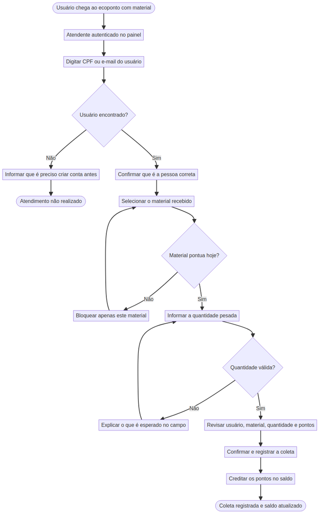

O cenário 5 — a falha de rede — **não aparece aqui, e está certo.** Ele não é uma escolha do usuário, é uma condição técnica. Quem mostra isso é o Diagrama de Sequência.

**Repare no losango do meio.** *Material pontua hoje?* existe porque a conversão depende de uma campanha vigente, e campanha é dado que muda. Um fluxo que assume que todo material sempre pontua esconde a regra de negócio inteira dentro de uma seta.